# 公众号运营实战手册_57招让你实现从0到10万+.粥左罗2018

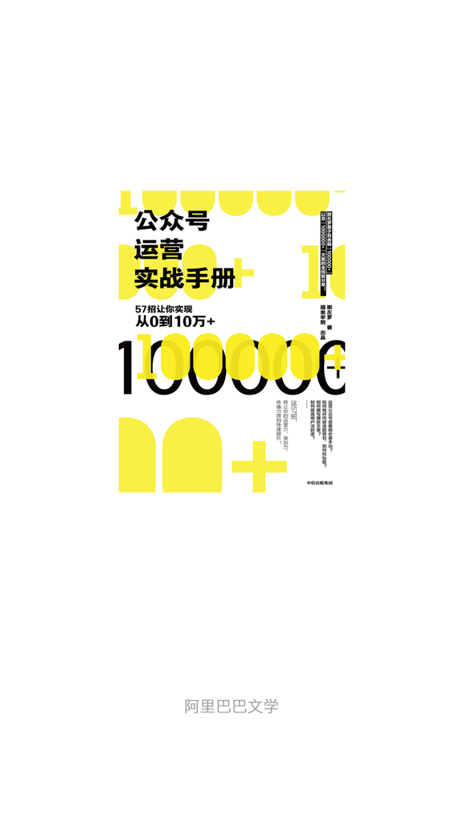

## 版权信息

书名：公众号运营实战手册：57招让你实现从0到10万+

作者：粥左罗

排版：陕西数字信息技术有限公司

出版社：中信出版社

出版时间：2018-11-01

ISBN：9787508693590

本书由中信出版集团股份有限公司授权阿里巴巴文学电子版制作与发行

版权所有 侵权必究

## 序言

2015年4月，一个用户在“插坐学院”公众号留下了这样一句话：作为一个学院，你们连一节课都没有，干脆别叫学院了。

彼时，我正在收尾一个失败的项目：通过App（应用程序），帮助每个用户找到最适合他的公司。

在做了小半年之后，我们发现有这类需求的用户黏性不高，而且当时O2O（线上到线下）模式风头正劲。我判断，纯线上的互联网产品机会已然不大，就决定暂缓这个项目，看看有没有更适合我们团队的方向。

这条留言把我点醒了。我们不是一直想做一家帮助年轻人成长的公司吗？为什么不直接做在职培训呢？而且，长期以来，大学应届毕业生与实际工作岗位之间，一直存在比较大的能力差距。

但是，从哪儿开始做起？培训什么内容？谁来讲课？怎么招生？收费多少？上课地点在哪儿？一连串的新问题随之而来。

好在，作为一个下定决心的创业者，这些问题对我来说，不算什么挑战。

我开始思考公司在培训业务上的执行方案。初步想法是，先找一个切入点试试。

恰巧，不久前，我写过一篇文章：《如何做好一个微信公众号？》，获得了不错的阅读量，很多人都在朋友圈转发。当时微信公众号刚刚开始流行，远达不到普及的程度，绝大部分企业都在观望。

于是，我分别给几十个阅读和转发的用户发了私信，和他们开诚布公地讨论一个问题：如果我准备一堂如何运营企业公众号的课程，你们愿意花钱报名吗？

出乎我的意料，大部分人都表示很感兴趣，时间允许就会报名。有两位同学甚至直接给我转账几百元定金：先占个座。

这对于刚经历过短暂失败的我来说，绝对是最大的鼓励。

我决定抓住这次机会，好好做一堂公众号运营课。我还把课程的主题命名为：首席微信官特训营。由我主讲，搭配几位案例讲师，共同合作完成。

很快，我们招满了第一个班、第二个班、第三个班……课程规模也越来越大，从几十人到几百人，更有上千人的付费大课。

插坐学院在新媒体培训这个方向，开始了长达3年的快速发展。在此期间，我个人授课接近200场，先后走进数十家知名企业。

2016年4月，我们获得真格基金和新榜联合投资，公司正式迈出了第一步。

这时，我开始重新思考公司的愿景。

我们要服务每一个渴望成长的职场人，以及每一家重视员工发展、追求卓越的优秀企业，就必须开发更多的课程，与更多的讲师进行合作。

于是，我在2016年6月10日的一场500人线下大课上宣布，插坐学院推出“好多课”App，正式进入在线课程模式。同时，我个人将阶段性暂停一切线下授课，集中精力研发在线课程，招募合作讲师。

粥左罗老师就是在这个时候，走入我们视野的。

最初，我们公司的一位公众号编辑向课程组同事推荐了他，说《创业邦》杂志有一个公众号编辑，做内容很务实，也有不少运营上的野路子，应该可以试试。同时，他也提醒我们，这个编辑的个人资历并不算太深厚。

但一直以来，我都推崇实战派，所以要求课程组同事务必请粥左罗录一节课程小样，我们听过之后，再做判断。

第一次听到粥左罗的课程小样，是在一个周末的早上，至今我依然印象深刻。我双手拎着从超市买回来的日用品，戴着耳机，听他讲完了两节“如何起标题”的课程：一个是巧用数字，一个是蹭知名度。

虽然在语言表达上，粥左罗的课程内容还略显生涩，但逻辑性与实用性已经非常好。

在那之前，我听过几十位老师的录音课程，要么空有名头、华而不实；要么内容浅显，不成体系。我和团队甚至一度怀疑，拓展讲师这条路是不是有问题？

但粥左罗的课程小样，给了我们很大的信心，甚至可以说是惊喜。

就是他了！我们决定，先和粥左罗合作出一个30节左右的课程试一试。

没想到，这一合作就是半年多。在这期间，我们对细节反复打磨，但总体而言，粥左罗不仅出课质量高，而且总能准时完成课稿。

随着对粥左罗的了解逐步加深，我开始力荐他推出更重磅、更系统的新媒体课程，也就是今天超过3万人学习的《公众号运营·实战指南》的1.0版本。

2017年3月，我借着粥左罗来插坐学院录课的机会，正式邀请他加入我们，职位是内容副总裁，年薪50万。

因为有了之前半年多的合作与了解，粥左罗考虑再三，最终接受了我的邀请。我们的合作，正式进入一个崭新的阶段。

紧接着，在一次公司内部会议上，我宣布了一个重要决定：插坐学院将围绕粥左罗，研发迭代新媒体在线课程，包括我曾经讲授过的所有新媒体课程内容。

整个2017年，粥左罗几乎拿出了全部精力，用来研发打磨《公众号运营·实战指南》这门系列课，包括11大模块，90节课，而且完成了一次整体迭代。

工作量之大，投入精力之多，在整个知识付费领域，都极其罕见。如今，这门课程的主体内容，由中信出版社精编出版面市，也是对课程含金量的最大认可。

我也希望能够借此机会表达我为什么要强烈推荐粥左罗的这本书。

#### 第一，语言表达精练务实

粥左罗不仅是一个运营高手，还是一个语言表达高手。

这种能力，不仅体现在他作为一个新媒体运营专家的层面，更体现在他授课的方方面面。认真阅读这本书，你会发现，每个章节都透着四个字：精练务实。

所谓精练，就是全书没有空话，很少用新词，更不随意造词；所谓务实，就是全书紧密结合实际工作，一切以实战应用为出发点。

#### 第二，内容体系完整严谨

2017年6月，《公众号运营·实战指南》90节在线课程，在“好多课”App上正式更新完毕，同时已有超过1.5万人报名。

说实话，这有些超出我们的预期，因为这套课程的售价是299元／人，大幅高于同期普通在线课程的定价。

随着报名人数越来越多，每一节课，都有很多同学在学习、应用以及反馈。

为了更好地服务每一位用户，我们决定利用3个月的时间，免费升级迭代整套课程，以期让内容逻辑更严密、案例更丰富、学习更简单。

要知道，这里面的工作量极大。但粥左罗没有任何犹豫，按时完成了迭代工作。

在这里，我要特别感谢粥左罗对我们迭代决定的全力支持。

#### 第三，作者是真正的一线实战高手

市面上有不少公众号教程，但我翻下来之后发现，很少有作者是真正的“圈内人”。

粥左罗老师2015年10月正式进入公众号运营岗位，零基础入行的他，在摸索了两个月之后开始爆发，第一篇文章就达到3万阅读量。

之后一年多的时间里，凭借着无比的勤奋和高产，粥左罗创作了上百篇阅读量10万+的文章。这些宝贵的实战经验，构成了他最初的新媒体运营知识框架。

#### 第四，作者拥有超强的学习力与进化力

拥有一线运营实战经验的新媒体人很多，为什么粥左罗可以脱颖而出，成为这个领域的知名讲师？从和他共事以来的近距离观察看，最主要的原因，是粥左罗有着超强的学习力和进化力。

他不仅熟练掌握了具体的新媒体运营方法，还大量学习了商业案例与市场营销经典理论。他知道，自己之前的积累主要集中在创业投资领域，于是主动恶补更加普遍适用的商业知识。

所以，这本书的内容价值，远远超出具体的公众号运营范畴。

#### 第五，作者是用户价值的坚定信仰者

最后我要说，粥左罗是一位用户价值的坚定信仰者。

他的每一次努力、进步，每一次创造卓越成果，背后真正的原动力，是他对用户价值的极度重视。

不管是写一篇文章、一条留言，还是寻找一张配图，优化一个小标题，他的标准只有一个，那就是用户价值第一。

我也特别希望，您在阅读本书的同时，不仅能够学习到丰富的实战方法，更能从中体会到用户价值这种底层运营思维的重要性。

2018年是一个非常特别的年份，公众号运营经过6年的粗放式狂奔，真正走到了一个十字路口，撞大运的机会越来越少。

回归市场逻辑，回归用户价值这个本源，精细化运营，成为每个团队的必然选择。

所以，在这样一个必须踏实的年份，出版这样一本足够踏实的公众号运营教程，无论对于付出大量心血的粥左罗老师，还是对于长期专注于新媒体培训的插坐学院，都是一种莫大的欣慰。

最后，衷心希望每位读者，都能在阅读这本书后，找到公众号运营的方向与方法，也希望每位新媒体人都能在2018年战胜流量寒冬，取得新的突破。

何川 插坐学院创始人

2018年9月21日

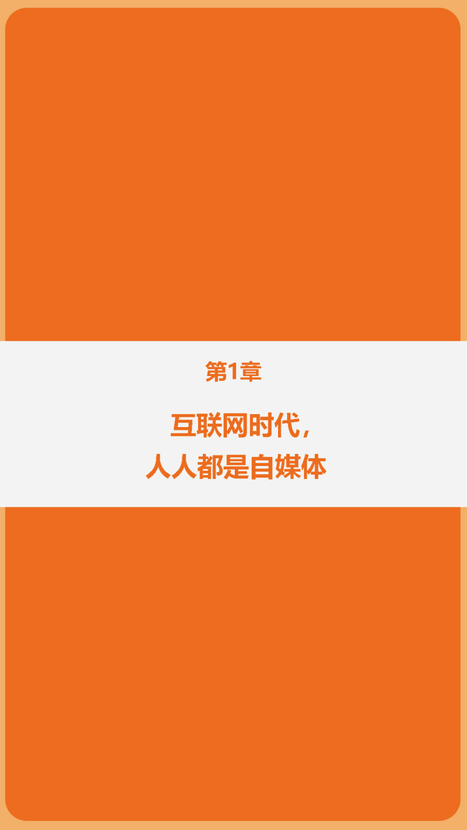

微信公众号能够精准、海量、低成本地吸引目标用户。同时，微信公众号也是一款简单有效的客户关系维护工具。遗憾的是，虽然大部分企业都在运营微信公众号，但运营得卓有成效的却非常少。大多数的微信公众号都形似“鸡肋”：运营无味，弃之可惜。

## 内容传播的全新法则

5年之前，人们对微信的认识还仅仅是停留在个人与个人所发送的语音、文字和表情包上。而现在，无论是在喧嚣的马路上，还是在拥挤的地铁中，我们都可以轻易地发现来自很多企业、商家的官方二维码，扫一扫这些二维码，进入它们的公众号，映入我们眼帘的，不再是简单的聊天界面，而是一篇篇引人入胜的文章和让人眼花缭乱的活动消息。

但是，如今大多数微信公众号的运营却不理想，这其中很大一部分原因在于它们的运营者依然在用传统营销思维运营微信公众号。所以，想要做好新媒体，首先要做的就是思维上的转变。传统营销方式和新媒体营销方式有很大的差别，只有真正意识到这些差别、理解和接受这些差别，才有可能在运营新媒体时大展身手。

要想在新媒体时代创作出广受用户欢迎的爆款文章，就一定要理解新媒体时代下全新的内容传播法则，了解在这个崭新的环境下，内容如何被传播，什么样的内容能够被广泛传播、被消费。

### 速度极快

这是新媒体时代信息传播最重要的特点之一，这个快不仅来势凶猛，而且去势难挡。比如2017年7月23日晚《北京，有2000万人假装在生活》这篇文章占领了很多人的朋友圈，所以在24日引发了大量账号追踪这个热点，但到了25日的时候，这个话题的热度就渐渐退去了。

在新媒体诞生的这几年中，很多话题都是如此速生速朽。这个现象出现的原因在于传播效率的改变。从书到报纸、杂志，到网站、论坛，再到社交媒体，信息传播的成本越来越低，传播效率越来越高。“独家”这两个字所能带来的势能越来越小，如何高效快速地为用户提供信息服务，则变得更为重要。

在这样的大背景下，我们需要注意以下两点：

**@快速追热点** 顾名思义，追热点就是指热点出现后及时跟进。可分为两种操作方式：一种是消费热点本身，另一种是借势热点、借力发力，具体做法会在后文详述。

**@非热点内容也要加快处理效率** 我最怕听到新媒体编辑说“这个不是热点，不着急”。抱着这样的心态，是做不好新媒体的，任何好的内容你都有义务更快地提供给用户。

天下武功，唯快不破，在这个时代做内容，最重要的就是快，一旦你慢下来，就没有人会去关注你了。

### 强互动性

信息从单向传播变成了双向互动传播。在纸媒时代，互动性几乎为零，作者和用户几乎没有任何接触。自己的文章刊登在杂志上被多少用户看了？用户看完后有怎样的感受？对你的观点是赞同还是反对？这些都不得而知。

而在社交媒体时代，沟通的壁垒完全被打破了。当你在公众号上推送一篇文章后，喜欢这篇文章的用户会给你点赞，会留言与你交流，甚至还会分享你的文章到自己的朋友圈。而不喜欢你的用户也会直接在评论区中表达自己的不满和对文章的意见。

应对这样的情况，有三件事需要我们重点关注：

**@引导用户互动** 无论是点赞、评论、分享、投票，还是回复关键词、后台互动、线上活动等，都能让用户参与到与公众号的互动中来，具体效果要视具体情况而定，切莫僵化认知。

**@维护互动** “互”就是相互，只有双向的交流才能称为互动。你要在所有的互动环节里及时给用户反馈，回复用户的留言。

**@根据互动反馈调整工作** 我们要在公众号服务的互动过程中，不断地感知用户、了解用户，最终优化我们的服务。

### 随机性强

在传统媒体时代，我们去买书或杂志时，往往带着特定的阅读需求，具有较强的目的性与规划性。但是在新媒体时代，更多的人在不断地刷微博和朋友圈，“刷”这个字表现出明显的无目的性——当你拿出手机刷朋友圈时，并不知道将会看到什么内容，也不知道自己希望看到何种内容，一切的阅读都是随机的。

用户阅读的目的性不强，也就意味着我们需要尽最大可能争夺用户的注意力和时间。你的选题要投其所好，题目要能够抓住人的眼球，给用户一个停下来关注你的理由，争取在半秒钟内吸引用户的注意力，给用户继续阅读的欲望。

### 碎片化阅读

过去我们的阅读都是在图书馆或在家中坐在书桌前、沙发上进行，人的状态相对静止，注意力较为集中，但随着智能手机的普及和社交媒体的发展，人们的阅读环境发生了很大变化。古人说“枕上、马上、厕上”，用现代化语言表述就是公交车、地铁等通勤工具上，睡前或者是上厕所时。阅读时间的碎片化，意味着注意力随时可能转移。

那么，如何才能吸引用户的注意力？我认为以下5点较为重要：

文章的排版要赏心悦目，阅读界面简洁有条理，不让读者望而生畏。

文字要流畅，这关系到文章的读完率。

增强文章的逻辑性，逻辑是一种力量，能加强对用户注意力的锁定。

适当加入图片和音频视频，这是更吸引人的信息呈现形式。

文章的信息量和信息密度需要有保证，避免出现无用信息。

### 众媒时代

传统的媒体时代正在迅速瓦解，取而代之的则是一个人人皆为媒体的新时代，我称之为“众媒时代”。“众媒时代”的重点在“众”字，一是生产者众，二是传播者众。每一个人都可以成为内容的生产者，也都可以成为内容的传播者。

那么，我们该如何应对？可以根据“众”的两层含义分而击破：

**@让用户参与内容生产** 比如“咪蒙”和“新世相”，大量的内容都是由用户生产出来的，它们只需要为用户提供选题和内容规范，最后再完成筛选、整理、加工就已足够。

**@让用户参与内容分发** 鼓励他们分发你的内容。如今一个普通用户的微信好友都可能是上千人，如果你的内容能够被更多的用户转发，你的信息就可能会像新世相那样在社交媒体上刷屏。

### 社交属性

社交属性是新媒体时代另外一个非常重要的信息传播特点。无社交，不媒体。没有社交属性的内容，几乎无法被传播和交换。就连每一个人发的朋友圈都是如此，很多时候我们发的内容并不是自己想发，而是我们想让朋友看到。这些内容其实就是在充当一种社交货币、承担一种社交功能。

这个现象的应对方法非常简单，你只需要将你的内容注入社交属性就可以了。你的内容如果能够帮助用户表达观点、展示自我、寻找谈资、帮助别人，甚至能被用户当作社交货币来使用的话，这些内容就一定能在朋友圈广泛传播。在某种程度上，只要你能充分了解用户的社交需求，也就掌握了传播的秘密。

总而言之，新媒体要想在这个崭新的时代中受到关注、得到流量，就一定要一改传统的高高在上的、冷冰冰的、单向强迫式输出的角色，向平等的、亲和的、双向沟通式的新媒体营销角色转变。

## 用户阅读的六大心理特征

诚然，在移动互联网迅猛发展并向二级细分市场深入渗透的大背景下，微信公众号对于我们来说早已不再陌生。上至纵横全球的跨国公司，下至自产自销的网店店主，都建立了属于自己的专属公众号，多如牛毛，数不胜数。然而奇怪的是，纵然有数量如此之多的公众号，但是其中真正在用户群体中有巨大影响力并获得用户认可的“公众大号”却总是屈指可数。究其原因，就是因为大部分的公众号没有了解用户的阅读心理。

在我看来，在新媒体时代，用户的阅读心理有6个特点。

### 我要知道得比别人快

无论是娱乐圈的明星八卦，还是新上映电影的影评，抑或是“咪蒙”禁言结束后再发推文，所有新闻，用户都希望自己知道得比别人快，比别人早。因为在社交媒体时代，每个人都希望成为朋友圈里的消息达人，如果很多大的新闻事件他都是第一时间知道的，那么他就更愿意去发朋友圈、发微信群，甚至直接发送给朋友，这是他的优越感、满足感的来源。

知道这一点，你就明白了为什么很多热点你发得稍微晚点，阅读量就会有那么大的差别。就是因为当用户不再是朋友圈中第一个发该信息的人，他就不好意思再发朋友圈了。所以，作为内容提供者，我们每天都要为如何更快地为用户做信息服务努力，我们成就了用户，用户才会成就我们。

### 我要知道得比别人多

大家平时都会追热点新闻，大多数10万+的热点文章是将一个热点人物或一件热点事件解读得极为透彻。从用户的角度来说，他愿意将更全面、更清晰的内容分享出去，而不是分享那些短消息和短新闻。因为用户在分享你文章的同时，其实也是在借你的内容展示自己的见解、品位。

因此，作为内容的提供者，只有能够在有限的时间内，尽量提供出比别人更多的料，让内容足够丰富、有厚度，用户才更愿意去转发、分享。这就是我经常说的“一站式解决方案”，也就是说只用一篇文章，就能够将一件事情说得足够清楚、透彻，让用户觉得看这一篇就足够了。

### 我要知道一些不一样的事情

新媒体时代，也是每一个个体崛起的时代。人的表达欲、表现欲越来越强，而且越来越注重个性化的表达。尤其是年轻人，有时候甚至将和他人不一样当成了做事的准则，这也是如今新媒体百花齐放的原因。最近几年，我们经常会听到一个词“消费升级”，消费升级有一个非常重要的特点，就是从标准化消费到个性化消费，无论内容还是产品都是如此。

我们写文章的时候，要注意两点：第一，你能不能发现一些大家不知道的事情。第二，你能不能提供一种新鲜的观点或者认知。所有的用户都喜欢新鲜的内容，而不是老生常谈。另外，在传统媒体时代最重要的是“客观中立”，但是在新媒体时代“个性鲜明的主观表达”却更受欢迎。著名的互联网评论家Keso（洪波）有一句很著名的话：少跟我提客观。

### 我要读有用有趣的内容

**@有用** 有用指的是显性的有用，或者说叫功利性阅读。比如罗辑思维做的知识付费平台“得到”，上面就有两个对比起来很有意思的付费专栏。一个是和菜头的《槽边往事》，一个是李笑来的《通往财富自由之路》。两个都是得到最早的主推专栏之一，但是最终和菜头的栏目仅仅卖了不到3万份，而李笑来的栏目却卖了超过17万份。为什么有如此大的差距？其实从专栏的名字就可以初见端倪了，《通往财富自由之路》谁不需要，谁不向往呢？

**@有趣** 有趣是指用户不希望你像一个机器人一般，生硬地推送理论知识、讲道理、陈述事实。你要以人格化的形象，以吐槽的口吻把严肃的知识抛出来。

很多人都看不下去经济学的大部头，但《牛奶可乐经济学》却无比畅销，为什么？因为作者用一些生动有趣的案例、场景，把很多有用但无趣的经济学知识变得既有用又有趣，所以才能获得成功。连传统的纸质出版物都在追求有用有趣，新媒体更应如此。

### 我要更高效地阅读

罗振宇老师在2016年提出一个概念叫GDT，即“国民总时间”。在这个高速运转的社会，每个人的时间都是有限的，每个人的时间都越来越宝贵。

因此，谁能帮用户节省更多的时间，谁就能成功。但是我们却不能像微信教父张小龙所说的那样“让用户用完即走”。因为媒体天生就是要争夺用户时间和注意力的。所以，最好的方向不是让用户停留的时间变短，而是在单位时间内提供更多的信息量，或者是在信息量不变的前提下让用户更快获取。

### 我要更好的阅读服务

如今的用户之所以越来越挑剔，就是因为内容已经从十几年前的供不应求，变成如今的供给远大于需求了，从信息匮乏变成了信息海啸。在供不应求的时候，内容生产者可以随心所欲，而在供大于求的时候，只有用户才可以为所欲为。你仅仅写得好还远远不够，你还要让用户看得舒服、看得开心。

想要提供更好的服务，可以从更好的排版、更精致的配图、更有节奏的推送时间、更好地帮用户提炼重点亮点、更快更好地与用户互动等多方向入手。同时也要提醒一点就是，在新媒体时代，写作者应该抱着服务者的心态创作，用户就是上帝（如图1–1所示）。

[figure not shown]

图1–1 文章的排版、配图

用户的心智就像是一座坚固的城池，而想要攻破它，不仅仅需要内容、服务这样的神兵利器，还需要去了解它，走近它，知己知彼才能提供更好的服务。

## 新媒体编辑的能力构成

目前以微信公众号为代表的新媒体行业总体还处于摸索阶段，行业内并没有形成一套固定的交流机制。在这样一个相对混乱的时期，就更加需要新媒体编辑具备更多、更强的能力。通过我自己的实践，以及从业两年间对大量优秀新媒体人才的观察，我认为新媒体编辑需要的核心能力主要有以下6点。

### 内容选题能力

这是新媒体编辑的第一个重要能力，我们经常在朋友圈看到的一句话是：不要用战术上的勤奋掩盖战略上的懒惰。这句话最初来自雷军，虽然略显鸡汤，但却一语中的。对新媒体编辑来说，怎么去写只是战术问题，而写什么才是战略问题。

很多时候，你动笔时就注定会输了。这不是内容质量的原因，而是选题的错误。从做爆款文章这个维度上，选题是最重要的一环。如果选题选对了，获得10万以上的阅读量将会非常轻松，反之则难如登天。所以在新媒体时代，找选题能力将决定你的生死（如图1–2所示）。

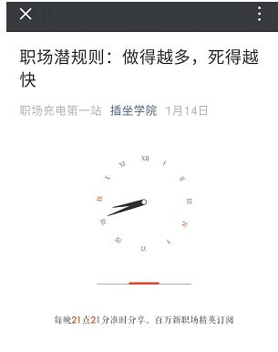

图1–2 文章选题

### 内容写作能力

对于新媒体编辑来说，写作能力是一项基础能力，是一项不可或缺的基本功。无论你的公众号内容是原创、采访还是整合，都需要你拥有出色的写作能力。如果你的写作能力非常出色自然很好，但是如果你的文笔没有那么好，也不必太过担忧。只要你有一定的语言组织能力，能通过文字把事情讲述清楚就可以，毕竟公众号运营比拼的是综合能力。

### 内容运营能力

内容运营是什么？我给它下了一个简单直接的定义：通过一系列的运营手段，让内容价值得以最大化。内容价值最大化包括：连接更多的用户，获取更多的用户。而具体到工作中，就是如何包装内容和分发内容。取标题、优化开头结尾、加配图、画重点、做排版、提炼小标题、做音频和视频等，这些都属于如何包装的内容。

而如何选定推送时机，如何运营用户在朋友圈、社群分享，如何同步今日头条、知乎、简书等其他内容平台，如何分发给其他账号转载等工作，都属于如何分发内容。这两个加在一起，就是一个内容运营的完整过程。

这一系列的运营过程，其实就是一个把产品包装并通过各种渠道推向市场、推向用户的过程。在如今这个时代，写完一篇文章仅仅是第一步。

### 用户感知能力

用户感知能力将成为以后新媒体编辑最重要的一项核心能力。因为，我们所提供的一切内容服务都是围绕用户的需求和痛点所展开的。所以你要准确地了解用户，掌握用户的属性，甚至你还要去学习心理学，研究人性方面的知识。

如果你具备以上所有能力，再加上一定的文字水平，就一定能够成为一个传播高手。作为最会做传播的“新世相”的创始人，张伟就曾经表达过这样的思想：做传播最重要的原则是不去想传播，跳出来，回到问题的本质，你想要影响哪些人，你就去想他们日复一日的痛苦是什么、焦虑是什么，你去理解，然后提供解决痛苦和焦虑的办法。这些都做到了，你的内容传播就一定是非常成功的。

### 用户运营能力

现在很多人都在说用户运营，那么用户运营到底是什么呢？我可以为它做一个通俗的解释：通过一系列的手段，与用户发生更多的连接，加深与用户的关系。

仅仅吸引用户去点击、阅读，这样的连接是很淡薄的、经不起考验的，这也是我们必须去做用户运营的原因。其实，用户运营无非就是引导用户投票、点赞、评论，做用户社群、线上线下活动等，并不困难。困难的是，你能够日复一日地认真执行下去。

### 大众审美能力

其实，我们完全可以把新媒体编辑当成是一名产品经理，只不过我们打造的是内容产品。在传统媒体，一个内容产品的生产流程是：记者写稿、编辑审稿、校对改错别字、美编排版、摄影师作图，大家只需要各司其职就足够了。但是在新媒体时代，编辑要把控一个内容产品打造的每一个环节，所以这时你的审美能力就变得格外重要了。

审美能力相对来说是一个不太好界定的能力，而且不论是从图片、选题还是文字、排版上，体现的都是账号的人格化形象。所以，我们需要的审美其实是大众审美，要符合绝大多数人的审美标准。如果你的审美能力足够好，做出来的产品就是有品位、有灵魂的。而如果你的审美能力不足，无论你怎样努力，做出的产品也难以得到用户的青睐。所以，不断地培养和提高自己的审美能力，是新媒体编辑的一个重要课程。

## 输出的前提是高质量输入

如今，新媒体编辑不能仅仅想着如何做内容的输出。其实，我们的工作应该包含了输入和输出两个部分。因为，我们只有不断做高质量的输入，才能进行新思考，得出新观点。只有与时俱进，才能够做到有的放矢，抢占用户。如果只输出不输入，即便你学富五车，迟早也会有江郎才尽的一天。

但是，我也发现了如今人们的普遍问题，那就是阅读质量太差。这里的质量指的并不是阅读内容的品质，而是输入的有效性太差。很多人可能每天会去读十几篇好文章，但是刚刚读完就忘记了，什么也没有学到，这就是无效阅读。想要提高阅读质量，保持持续的内容输入，就要做到以下6点。

### 带着目标和预期阅读

我认为，现在人们阅读质量低下，最直接的一个原因就是，如今的阅读大多没有明确的阅读目标和预期。我时常会听到周围的人定下这样的目标：我这周要读完两本书，我今天要看完10篇文章。在我看来，这样的目标很可怕，因为他只是为了阅读而去阅读，并没有想过要通过读这篇文章解决什么问题或者是学习什么技巧，这样的阅读往往意义不大。

和大家分享一下我的习惯，比如当我看到公众号“新榜”推送了一篇文章《“十点读书”粉丝破1500万！8条成功经验值得每一位内容创业者思考》准备阅读时，其实我心里就已经有了目标和预期。我希望自己通过阅读这篇文章，知道“十点读书”最新的发展情况，了解“十点读书”的8条成功经验是什么，并且思考这8条经验中哪些对我有用，哪些是我讲课的时候能够教给同学们的，等等。

当我为自己制订了目标和计划后，我就会边读边思考，边读边找答案。当我读完时，已经学到了很多东西。而不是花费10分钟读完后，仅仅发出了一个“这篇文章写得真好”的感叹。记住，千万不要将读完当成你阅读的唯一目标。

### 强制性做笔记和输出

你永远要记住一句话，没有输出的输入是没有价值的。输出是一个提炼、归纳、总结、重新演绎的过程，只有经历了这个过程，才能将别人的知识变成你的知识，否则你只是“读过”“看过”，仅此而已。

用罗辑思维联合创始人脱不花老师的话说，“做笔记不是让你抄句子，那不叫输出，那叫练习打字”。当然，输出也并不是说让你写一篇阅读心得，你只需要写几句自己的思考就可以了。因为，只有这样才能强迫自己动脑去思考。另外，脱不花老师还建议，你在做输出的时候，最好是把你的输出公开，比如你要发在朋友圈，或者讲给你的同事听。因为你一旦决定公开，就会更加注重语言表达和逻辑，会在意别人能不能看懂、听懂，这会倒逼着你提高输出的质量。

### 更聚焦的主题式阅读

每天阅读的内容不宜太过杂乱，因为这样会分散你的精力和注意力，降低阅读质量。所以，最好的方式就是主题式阅读，在一个小周期内解决一个问题。当然，这并不是强迫大家在一个周期内只能看一个主题的文章，如果这样会很枯燥，容易减少阅读兴趣，那也应该有所侧重，将70%的时间放在该主题上。

我看过一个非常短，但是非常有意义的故事：有一天，比尔·盖茨的爸爸让比尔·盖茨和巴菲特同时在纸上写下一个对自己人生最有帮助的词，两个人写之前没有过任何沟通，但两个人写了同一个词：专注。

### 反复地阅读经典文章

很多人太过于追求读新鲜的东西，看过的东西不想看第二遍。这并没有错，因为大多数人都喜欢新鲜，不喜欢重复。但学习恰恰就是一个需要不断重复的过程。因为很多知识，仅仅看一遍是无法完全掌握的，需要反复地学习，温故而知新。

我平时有个比较好的习惯，就是当我看到一些人所写的有真材实料、有深度思考、有实用干货的文章（比如李叫兽、梁宁、陈春花等人的文章）时，就会在微信里进行收藏，并且添加在相应分组，因为我需要反复阅读这些文章，每次读都会有新的感受和收获。你要想成为一个领域的高手，就要逼着自己做这样的事情。

### 阅读时，请带着批判性思维和学习的心态

我们要带着批判性的思维来看他人的东西，有自己的思考；但同时也要带着学习的心态去学习他人身上的那些闪光点，这其实并不矛盾。所以我们可以看到，很多人花了一整年时间去批评“咪蒙”的各种缺点，但除了释放愤怒之外，什么也没有得到。而我却用这一年的时间，学到了“咪蒙”的选题套路、标题技巧和传播思维。

### 阅读过程中不断代入自己的工作场景

作为一名从事新媒体工作的人员，我在读每一篇文章时，都要问自己几个问题：这篇文章的选题怎么样？题目起得好不好？这篇文章的目标用户是哪一个细分人群？解决了用户的哪一个具体需求或痛点？文章的开头结尾有什么值得学习的地方？文章有哪些好句子、好观点、好故事以及为什么好、能不能为我所用？等等。

在你读每一篇文章的时候，虽然是站在用户的角度，但是也要带着编辑的眼光。用用户的身份去感受，究竟是怎样的内容和逻辑才更加能够吸引你的目光。看到无趣的文章时，想一想自己的工作，自己是否也写出过这样的内容，如果一篇文章连你自己都无法吸引，还怎能奢求用户们买账呢？唯有如此换位思考，你才能保证读过的东西能够对自己的新媒体有所帮助。

只有有技巧、有目标地去阅读，才能提高学习质量、学习效率。用正确的方法，“让天下知识，为我所用”。

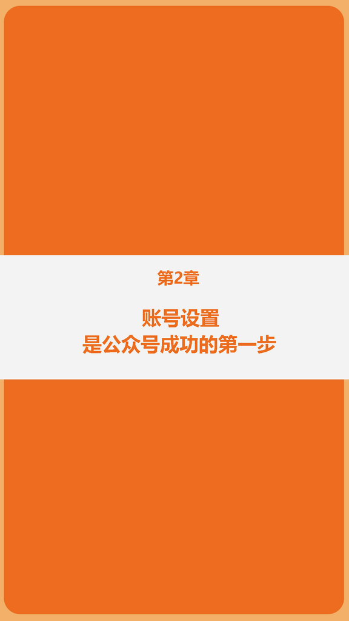

账号设置是公众号运营的第一步，内容包括公众号名称、功能介绍、头像和菜单设置等。通过精心设计账号信息，运营者得以初步建立公众号的对外形象。账号设置看似简单，实则蕴含着公众号的整体运营思路，除了让人印象深刻之外，还需要与自身的战略目标相一致，承担起品牌传播的重任。

## 取个让全世界都能记住的好名字

中国人讲究“名正言顺”，名字起得好，公司发展好。苹果、华为、奔驰、三只松鼠，这些成功的公司和产品，几乎全都有一个好读、好听、好拼、好写、好记、好传播的好名字。

名字是公司身份识别的重要标志，就如同一个人的姓名一样。其实不只是公司名和产品名，只要涉及名字，都非常重要，公众号的名字当然也是如此。一般人起名字，第一，不会用生僻字，因为人名不好记的话，就不容易被更多人知道；第二，不会用贬义词，因为这会给人不好的联想，虽然容易被记住，但是对个人有负面联想，会与很多合作机会失之交臂；第三，不愿起大家都用的名字，这样的名字太普通，没有个性，没有生命力，勉强记住了，也容易跟别人混淆。

公众号起名的原理与此类似，由于需要承担宣传推广任务，公众号的名字在以后很长一段时间内与用户始终伴随，需要考虑的因素也很多。那么一个好名字有哪些特质，又对公众号起到什么样的作用呢？

### 降低认知成本

取一个好名字，往往就不用花费过多的时间和精力向用户解释你是做什么的，能够让人一下子就了解你，比如“创业家”“投资界”一看就明白，几乎是零成本认知。

### 降低传播成本

公众号的传播，主要依赖于文字和声音这两大渠道。名字好听、好读、好写，往往能够让用户乐于分享和传播。比如“一条”“二更”“差评”这样的名字就极易传播。“花儿街参考”就不好，因为打字的时候老是打出华尔街，“ScalersTalk成长持续论”也不好，不管是读出来还是用输入法打出来都很困难，这样就极大降低了传播效率。另外，认知成本高的名字传播成本肯定也高，因为你在解释名字的过程中就降低了传播效率，比如“36氪”和“槽边往事”。

### 占领用户心智

好的名字应该可以体现出微信公众号的内容定位，用户看到名字会产生内容联想，迅速判断是否为自己所需并且在有所需要时，第一时间想到你，这就是占领了用户心智。因此，要尽量让你的账号名字和一个行业、一个细分领域，甚至一个产品品类在用户心里进行绑定。

公众号起名是一门大学问，取个好名字可以省去运营者很多推广的精力，自带流量入口功能。基于以上三大作用，我总结出给公众号起名字的7个技巧，希望对大家有所帮助。

**@描述具体场景** 互联网注重效率和表达方式的多样化，对于场景的描述能够增强词汇的表现力，有利于公众号后期推文时的传播效果，是增加公众号影响力的上佳之选。所谓具体场景，大致可以分为三大方面：时间场景、空间场景和行为场景。

十点读书、深夜发媸、深夜谈吃等公众号名称，属于典型的时间场景描述；而办公室奇葩说、西二旗生活指北、职场实用心理学等公众号，则明确告知用户内容围绕的具体空间；再如被窝阅读、读首诗再睡觉，用户阅读这些公众号时便会在其脑海中勾勒出某个具体的行为。

**@强调目标用户** 你的内容产品的用户定位是什么？哪些人应该关注你？你要让用户看到你名字的一瞬间就知道你的定位。因此在公众号名称设置中，可以加入某一特定行业的词汇，比如餐饮、汽车等，就会引起特定兴趣的用户的关注，有利于公众号在行业内获得广泛传播。

比如一家经营家居用品的企业，公众号名称可以是“家居一点通”或“家居全知道”。这种名称直接体现出企业的行业特征，以便吸引对家居行业感兴趣的用户。

**@突出功能价值** 对于公众号来讲，最重要的是要让用户在第一时间了解你是干什么的。因此将具体功能加在名字中是一个比较常见的设置。

比如笔记侠的主要功能是分享笔记，顶尖文案的功能是分享文案，长江商业评论的主要功能是对商业案例评论进行解读……

这种设置有一个明显的好处，就是在用户搜索相关关键字的时候，会自动出现公众号的信息，增加了公众号的曝光度。

**@展示品牌内涵** 名字的含义丰富，很多时候，品牌格调、内涵都可以用一个特别的名字来表达。

比如公众号“我走路带风”这一名字直接体现当下年青一代追求个性的鲜明特点，十分贴合其运营者宋澍泽——一个出生于1997年的年轻女孩——的个性，也成功地为其吸引了一大批年轻粉丝。

**@使用常用字词** 要用通俗易懂的、大众熟知的词汇，不要自己造词，尽量少用大家不认识的字词、比较难拼写的字词，也绝对慎用中英文、汉字拼音组合。一个生僻拗口的名字，通常很难被大家所熟知。

**@名字尽量简短** 有些名字会因为太长极大降低传播效率，比如“BMW宝马摩托车中国”“化妆师MK–雷韵祺”。请注意，我强调的是名字尽量简短，并不是说越短越好，完整表达是名字简短的前提。

**@直接使用运营方名字** 顾名思义，就是取名时直接使用公司名、产品名或者自己的名字。因为名字是很重要的品牌资产，所以如果你的公司、产品名字很不错，那最好的方式就是直接使用，或者在原有的基础上改进，比如“中国移动”“万达集团”“绝味鸭脖”和“乐纯的伙伴们”等。

如果你是个人账号，也可以将自己的名字作为公众号的名字，比如我叫粥左罗，我注册的公众号也叫“粥左罗”，这样的好处就是能帮你持续地积累影响力、打造个人品牌。你也可以在你的名字基础上改造，比如“吴晓波频道”“王路在隐身”等。

以上公众号起名的7大技巧，彼此间不但不相互冲突，大部分还能互为补充，适合组合使用。公众号的名字如果能满足多个不同的命名技巧，成功的概率相对而言会提高许多。

比如“十点读书”读书两个字强调了目标用户，前面再加个十点又突出了使用场景，同时十点和读书又属于常用字词，读书还属于行业常用关键词，所以“十点读书”是一个传播效率高又能占领用户心智的好名字。

需要注意的是，取名本质上属于艺术创造行为，不能纯靠方法，还需要发挥你的想象力、借助你的艺术直觉、取材于你的见识和经验，然后再用这7个技巧去检验、优化、调整你的公众号名字。

## 突出头像，赢得更多记忆

一般而言，logo（商标）就是一个品牌的影响力终端，因此我们需要更好看、更简单、更有辨识度、更好记忆的logo。而公众号就是你要做的一个产品，是你要花金钱和精力打造的一个品牌，那么你的账号头像就相当于你这品牌的logo。要想在诸多公众号里脱颖而出，头像设计必不可少。

那么，一个好的公众号头像应该符合哪些设计标准呢？我总结为以下4点：

### 风格极简

简单是公众号头像设计时的第一标准，在碎片化时代里，要想让用户记住你，就要学会做减法，不能logo、汉字、英文、符号、数字等什么都往头像上放。什么都想让用户记住的结果，往往是用户什么也记不住。请记住，少即是多，懂得克制，才能赢得更多记忆。

### 色泽鲜明

首先，颜色不能多，两种颜色最佳，尽量不要超过三种；其次，颜色要够纯够亮够饱满，尽量少用暗色，尽量不要模糊不清。比如“36氪”和“支付宝”都采用了蓝底白字的设计，两种颜色都非常纯（如图2–1所示）。

[figure not shown]

图2–1 “36氪”和“支付宝”的头像设计

举几个反例，我很喜欢看的“槽边往事”“吴晓波频道”“科技美学”，头像的颜色都非常复杂，而且每种颜色都不纯，看起来暗淡无光。同样类型的头像，“罗辑思维”和“成甲”的颜色就非常好，一看就是经过专业拍摄、修图做出来的。

### 关联名字

公众号头像最好跟名字有关联，名字和头像同属一个系统，应该起到互相解释、互为补充的作用，让用户看到公众号的名字和头像后，就知道你是做什么的。

比如“插坐学院”的头像就是个三孔插座（如图2–2所示），寓意充电。这种设计让用户一目了然，增强了对公众号的印象。

[figure not shown]

图2–2 “插坐学院”头像设置

### 图片清晰

高清图片给人的视觉体验是无可比拟的，企业头像应当使用像素较高的图片，不仅能够提升用户的视觉感受，还能完美呈现企业的重要信息，一举两得。

在明确了公众号头像设计的四大标准之后，应该选取什么样的题材作为头像元素呢？对此，我总结出了公众号头像的设计方向，以供参考。

### 使用文字

**@用账号名字** 账号名字是最常见的公众号头像设计方向，能够明确传达品牌形象，让用户对其产生较强的信赖感，形成品牌影响力。这种头像非常简单直接，就是直接用账号名字作为头像，背景色就是你的品牌色。具体可分为以下两种情况：

**@名字全称+品牌色背景** 比如“平安证券”的公众号头像就是红底白字的“平安证券”四个字（如图2–3所示）。这种设计风格简单明了，体现出公众号积极进取与冷静细致的完美结合。让用户第一时间了解其主营业务，也传递了公众号的内在文化，是许多公众号品牌的首选。

[figure not shown]

图2–3 “平安证券”公众号的头像设计

**@名字中的一部分+品牌色背景** 比如“差评”公众号的头像就是一个黑底白字的“差”字（如图2–4所示），清晰明了，让人印象深刻。

[figure not shown]

图2–4 “差评”公众号的头像设计

这一条多用于企业新媒体，自媒体就不太合适，试想一下，如果“罗辑思维”的头像只用一个“罗”字，“吴晓波频道”只用一个“吴”字，是否会很奇怪？

### 用人物形象

使用人物形象是极为常见的公众号头像设计方向。这种设计使品牌的人格化进行得更加彻底，增进了用户对品牌的好感，对于公众号的品牌战略发展具有十分重要的意义。

这一条多适用于自媒体账号，具体也分4种：

**@用个人真实头像** 比如“罗辑思维”“年糕妈妈”，采用这种方式一定要找专业摄影师拍摄、修图，避免直接用模糊不清的日常照片，照片模糊会让用户感觉你的专业度较低，过于随便，降低品牌质感。另外，尽量只用头像照，不要用上半身照，更不要用全身照。

**@用个人漫画头像** 这种头像设计方向，适用于不想直接用个人的真实头像，但还想展现出具有辨识度的人格化公众号。如想实现这种效果，运营者可以请设计师或漫画师以运营者为原型进行漫画头像创作。

比如咪蒙，就以自身为原型，设计了一个可爱的卡通人物形象（如图2–5所示）。这样的设计很容易拉近其与粉丝之间的距离，给人一种亲切感，同时还具有较高的辨识度。

[figure not shown]

图2–5 “咪蒙”头像设置

**@用账号IP漫画形象** 很多账号都会进行IP（知识产权）化运营，这样的账号通常会直接设计一个经典的IP漫画形象作为头像，比如“少女兔”的头像就是一只可爱的兔女孩，“同道大叔”则是一个蓄着胡子的大叔形象（如图2–6所示）。

[figure not shown]

图2–6 “少女兔”和“同道大叔”头像设置

**@用品牌logo及其衍生** 品牌logo除了具有鲜明的识别度，还承载了公众号的文化精神，是头像设计时的上佳选择。将品牌logo进行拆分，取其精华部分或者增删部分内容，凸显公众号的特殊定位，也是头像内容的重要来源之一。具体可分为以下两种情况：

（1）本身有企业、有产品，现在要做一个新媒体账号，那就直接用品牌logo就可以，比如“小米公司”“海尔集团”等。

（2）没有企业和产品，现在开始做公众号，那就可以请专业设计师，根据账号的品牌格调和内容风格设计一个logo形象，比如“插坐学院”“硅谷密探”等都是这样。设计的时候一定要跟设计师反复沟通，确保最终的效果能够准确体现你的策划意图。

公众号的头像和名字，是用户每天都会多次面对的部分，更是你账号品牌资产的一部分，需要认真对待。以上四种设计方向，代表了公众号头像设计的主流思路，当然也有些公众号会独辟蹊径进行细节创新，比如用账号名字做头像的公众号，可以在字体上进行微创新，用以提升账号辨识度。

我个人建议：不管你最终采用了哪种设计方向，一定要找个专业的设计师操刀制作，切莫为了省下设计费用而自行琢磨。

最后还要强调一点：一个事情能做成做好，因素有很多，千万不要看到一些头像不怎么样但做得很成功的大号，就觉得头像不重要，你永远都可以做得更好。

## 功能介绍，让用户感知价值

在公众号名称和头像确定之后，需要填写的是公众号功能介绍一栏，这一栏将会展示在公众号名称下方，是用户了解公众号的一扇窗户，在账号设置中占有非常重要的位置。

顾名思义，功能介绍主要是说明运营者开通公众号的作用。大部分企业会添加用词相对而言比较官方的语句，比如：某某企业官方微信，提供某某服务。但是这种信息就如同企业在自我狂欢一样，不会引起用户的兴趣。因为信息中没有用户相对敏感的节点，用户无法感知这些信息对于自身的价值，不会产生想要接触、了解的想法。那么，到底怎样才能让功能介绍变得有价值又吸引人呢？我观察了大量的优质公众号后，总结出以下6个技巧（如图2–7所示）。

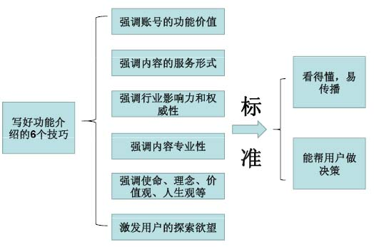

图2–7 写好功能介绍的6个技巧

### 强调账号的功能价值

为公众号进行功能说明时，一定要让人一眼就能看明白，你的内容能给我提供什么服务，避免用户无端猜测。“为用户提供理财服务”“为用户提供送餐服务”都是比较典型的写法。然而，这种写法虽然说明了服务范围，却无法让人印象深刻。换言之，在用户的意识中，提供理财服务以及送餐服务的公众号很多，功能介绍所提供的信息不能跟其他公众号实行有效区隔，难以触发用户的关注欲望。

在实际操作中，功能介绍在强调功能价值的同时，还要尽可能地突出自己的主要特点和优势。

比如“插坐学院”功能介绍中的“职场充电第一站，陪有梦想的人一起成长，每晚21点21分准时分享”，不仅强调了其“职场充电”的功能，还强调了自己“准时”的特点，起到了明显的宣传作用。

### 强调内容的服务形式

上一个技巧是告诉用户你能提供何种服务，而这个技巧则是告知用户你将会用何种形式为其服务。同样以插坐学院为例，“每晚21点21分准时分享”就是其服务形式。

### 强调行业影响力和权威性

直接告知用户你就是行业内最好的，这样的介绍简单直白，往往容易抓住用户的心，直接起到推广作用。

比如“人物”的介绍就是“最好的中文人物报道”；“团结湖参考”的介绍就是“国内最具影响力的时政评论号”。

### 强调内容专业性

很多时候，要想成功吸引用户的关注，你还需要向用户证明你的内容是专业的、值得信赖的，特别是对于一些内容比较专业的领域，比如财经、理财、管理、健康等领域，你需要但你不能直接说“我是专业的”，而要用侧面证明的方式。

比如“新经济100人”在功能介绍时会强调自己是“最懂新经济的创投服务平台”，由《创京东》《九败一胜：美团创始人王兴创业十年》作者李志刚和他的小伙伴们打理，以管理团队的知名度来反映自身的专业性。

### 强调使命、理念、价值观、人生观等

传达使命、理念、价值观、人生观等，也是一种比较常见的介绍方式。这种介绍方式一方面可以对公众号的受众进行标识，以此来吸引志同道合的精准粉丝，另一方面还可以直接阐明优势，提升用户关注的可能性。

比如，“清单”公众号的定位是为用户推荐一些实用的东西，其“用心生活，认真花钱”的介绍，将自身使命以及主要功能准确地传达给了用户，从而吸引了更多的精准用户。

### 激发用户的探索欲望

不直接说明自己的内容价值、用户定位，而是用一句非常特别的文案，激发人们对它的探索欲，让人忍不住想了解更多。目前这种方法也被广泛使用，效果明显。

“咪蒙”的一句“我从没见过你，但我懂你”，就曾经成功激起了众多用户的探索欲望，想要看看“咪蒙”到底怎么“懂我”。

以上就是写公众号功能介绍的6个技巧，大部分公众号都会将其中的几个技巧组合使用，比如“36氪”的介绍“36氪是中国领先的新商业媒体，提供最新锐最具深度的商业报道。我们强调趋势与价值，我们的slogan（口号）是：让一部分人先看到未来”。这里就运用了三个技巧：强调行业影响力和权威性、强调账号的功能价值、强调账号的使命。

需要注意的是，不管组合哪些技巧，都要尽量符合以下两条功能介绍的硬性标准：

### 看得懂，易传播

简单来说，就是要简单、直接、通俗易懂。

首先，要降低人们的认知门槛，说大家一眼能看懂的话。其次，语言一定要干净利索，能一句话说清楚的事儿坚决不要用两句话。

那么，究竟如何判断是否达到这个标准？很简单，就是要看用户是否可以轻而易举地向别人转述。比如我向朋友推荐“十点读书”，他问我这个号是干什么的，我可以直接告诉他：“深夜十点，陪你读书。”

### 能帮用户做决策

功能介绍应该让用户看了更容易判断是否应该关注你，而不是举棋不定。为什么用户会犹豫？很可能是因为你没有说明白你能给他提供什么服务，你没告诉他你的行业影响力和专业度等。

比如，甲喜欢看人物报道类的文章，当甲看到“最好的中文人物报道”这样的功能介绍时，当然会关注“人物”这个账号；乙是一个烘焙爱好者，当他看到“全面解决配方、教程、原料、工具的一站式烘焙平台”这样的介绍时，一定会毫不犹豫地关注“i烘焙”这个账号。这就是帮用户做决策。

总而言之，在功能介绍中，不能只是干巴巴地“介绍”。传达的信息需要针对用户的需求，让用户感受到价值，这样的功能介绍对企业才是有意义的。

## 自动回复：高互动率的首个关键节点

后台自动回复是公众号设置的一项基本功能。用户关注公众号之后，收到的第一条信息就是关注自动回复。关注后的自动回复文案非常重要，为什么？因为这是你跟用户第一次真正意义上的互动。所以你要把握住这次机会，设法跟他产生更多的关系。

在研究了大量优质账号的自动回复之后，我总结出一个规律——那些较为成功的公众号，自动回复一般包括以下三大部分：

### 欢迎文案

作为对用户关注行为的回馈，欢迎辞是必不可少的（如图2–8所示）。这是一种基本的社交礼仪，也是互联网时代的必备设置。文案的风格并没有固定的要求，但要能够体现你的内容风格和格调。

设置关注自动回复，会使用户感觉公众号很用心，形成良好的用户体验。如果关注之后没有自动回复，容易让用户产生此公众号疏于管理以及冷冰冰、不友好的第一印象，对公众号日后的推广活动十分不利。

[figure not shown]

图2–8 “王左中右”的自动回复

### 自我介绍

图2–8所显示的“王左中右”设置的自动回复中，在欢迎辞之后，便对自己进行了一个简单的自我介绍，这也是公众号自动回复中很常见的一种方式。用户通过头像、名字、功能介绍会对你有一个初步了解。你可以在自动回复里继续补充，让用户更全面地了解你，还可以利用回复设置宣传企业的文化价值，介绍你提供的服务类型以及服务形式等。

### 引导用户参与互动

自动回复文案的核心诉求就是想办法让用户有更多的停留，让用户和你发生更多的关系，进行更多的互动。通过互动营造参与感，让用户对你产生更多的了解，对你了解越多就越容易喜欢你，这样用户首次关注后，对你的第一印象就会特别好。常见的吸引用户参与互动的方式有：引导点击超链接，引导回复关键词，引导点击菜单栏和其他的互动方式。

**@引导点击超链接** 链接的作用是引导用户浏览其他内容，可以是公众号推出的一些活动，也可以是已经发布过的历史文章。

比如公众号“清单”在自动回复中设置了很多超链接（如图2–9所示），这样的应用不仅可以引导用户点击相应链接内容，方便快捷，还能够让整个界面简洁、大方。如果将其替换成一些密密麻麻的长网址，则会导致界面脏乱差，影响用户体验。

超链接的使用方法也非常简单，只需要在代码（<a href=“把你要跳转到的链接地址放在这里”>把你要显示的文字放在这里</a>把你要显示的文字放在这里）相应位置中，填写需要跳转到的链接地址以及要显示的、让用户点击的文字，然后打开公众号后台，打开被添加自动回复，选择回复“文字”，把已经插入好“跳转链接”和“显示文字”的代码复制并粘贴在输入框里就可以了。

**@引导回复关键词** 在欢迎辞中插入引导回复关键词也是自动回复中非常常见的内容。与用户直接接触的任何界面都是大好的营销机会，因此欢迎辞除了承担社交功能，给用户良好体验之外，也是一个巨大的广告位。可以利用回复设置宣传品牌的文化价值，推广公众号相应内容。

[figure not shown]

图2–9 “清单”的自动回复

**@引导点击菜单栏** 根据需求，大多数公众号都会设置一些个性化的菜单栏，这些菜单栏中包含着其较为重要的信息，是公众号和用户进行交流最为直接的窗口。因此，在自动回复中设置一些点击菜单栏的引导语也是非常必要的，这不仅可以充当使用指南，避免新用户不知如何查询相应内容，而且可以有意识地将用户引向自己想要让用户看到的内容。

比如点击关注公众号“庞门正道”，其自动回复中就包含了引导关键词设置——“回复‘历史’，有你想要的”。同时，为了满足更多用户的需求，还设置了相应的使用指南——“或者点击右上角查看历史消息。什么？不是你想要的？那么你点击右下角的菜单，打开庞门正道2周年那个~”（如图2–10所示），让刚接触到这个公众号的用户能够快速地找到自己想要的内容，拉近公众号和用户的距离。

[figure not shown]

图2–10 “庞门正道”的自动回复

**@其他的互动方式** 用户关注公众号，只是因为对某些信息有兴趣，如果可以在欢迎辞中设置一些能够引发用户交流的互动活动，则有助于你更好地了解一些有价值的信息，同时更加深入地了解用户，也让用户更加走近公众号。比如“清单”的自动回复中便写道：“最后，告诉我你是从哪里找到我的好吗？”，而“改变自己”的文字回复中也包含了“小调查：你是如何知道‘改变自己’的呢？”

当然，自动回复的设置除了回复文字，还可以回复图片和音频，比如“大象公会”的自动回复便是一只大象从火车里走出来的照片（如图2–11所示），“顾爷”的回复便是运营者亲自录制的一段欢迎语音。这样能够让公众号变得更加生动有趣，同时能拉近与用户的距离，更亲切、更容易塑造自己的魅力人格体。

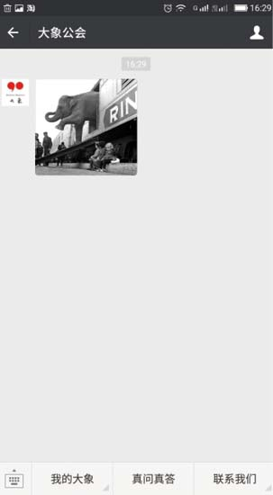

图2–11 “大象公会”的自动回复

最后需要强调的是，关注后自动回复界面一定要简洁、干净、友好，尽量要短，减轻用户压力。用户每天接收到的信息太多了，好不容易关注你一下，你又跳出几百字的回复，体验真的没有你想象中那么好。一定要克制，不要什么都说，不要试图一口气让用户爱上你。很多大号就做得足够克制，比如“咪蒙”的“你每一次迷茫的时候，我都在”，以及“视觉志”的“遇见你真好，想陪你到老”。

如果自动回复的内容确实比较多，一定注意空行、分段，不要将大量文字随意摆放，自动回复也要注意排版美观。

总之，公众号的自动回复设置需要根据公众号产品和服务类型来设计，但是万变不离其宗。用户的迫切需求始终放在中心的位置。自动回复是企业与用户互动的良机，需要根据公众号不同需求进行精心设计。以“跟用户产生更多的互动”为目的，结合你自己的账号风格，灵活组合运用上面的技巧，写出一个高互动率的自动回复文案。

## 源于用户需求的菜单栏

公众号底端菜单栏相当于自动服务系统，一些常见问题和服务，均可以通过设计菜单栏的方式进行业务分组。公众号需要借助菜单栏的设计帮助用户选择所需项目，让关注流量进行充分的流动，以便产生最大的价值。

事实上，菜单栏的本质是一套目录型检索工具，用户可以通过菜单栏高效率地找到你能提供的服务。

比如我想买“插坐学院”的课程，我就去它的菜单栏检索；我想查看“视觉志”近期的爆款文章，我就去它的菜单栏检索；我想转载“差评”的一篇文章需要授权，我就去它的菜单栏检索。

菜单栏里的目录，有些可以直接为用户提供服务，更多的是一个找到服务的入口和通道。总之，菜单栏是为用户提供便捷服务的，因此不能按照运营者的喜好设置，而是根据目标用户的真实需求设置。按照普遍适用的逻辑，综合账号定位和用户需求，我认为可以将菜单栏的内容分为以下5大类（如图2–12所示）。

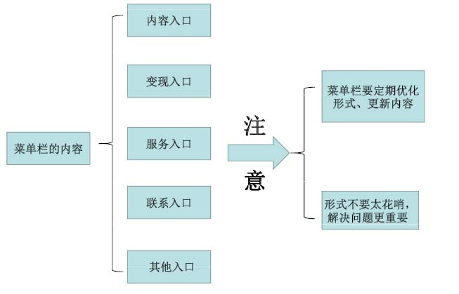

图2–12 菜单栏内容的5大分类

### 内容入口

这应该是菜单栏的一个标配，基本所有的账号都应该包括这一项，因为这是用户最基本也是最高频的需求之一，也是你的价值所在。你想想你是做什么的，既然是新媒体，提供内容服务是你最核心的功能。

具体设置可以根据账号风格选择以下形式：

**@历史文章** 这个是最简单的一种形式，其实就是把“查看历史消息”功能放在了菜单栏，缩短了用户动作，更方便用户点击。

**@爆款合集** 这种方式其实是帮用户精选出账号发过的历史文章中最好的那部分。如今很多公众号都坚持每天推文，有的甚至一天推出多篇，以此类推，一个公众号一年产出的文章可能多达上千篇，在这众多文章中，真正值得用户反复阅读的也许没有多少。因为，为了给用户创造更加便利的阅读条件，你可以制作一个精选内容的目录，将所有精选文章进行整理，这对用户来说价值是非常高的。

具体的呈现形式大概有两种：一种是把所有的精选文章整合在一篇文章里，分类呈现，比如“咪蒙”的菜单栏有一个菜单“看么”，点开就是她的文章的合集，分类为励志、职场、情感、爱情故事、亲子等，用户查看非常方便；另一种方式就是用公众号的页面模板功能，比如“顾爷”有个菜单栏叫“精选内容”，点开之后就是页面模板，内容精选以后分类呈现为艺术、深化、瞎聊、广告等栏目。

**@搜索** 搜索其实是方便用户自由搜索内容，一般会使用内容创业服务平台“新榜”开发的搜索功能“号内搜”，用户可以输入任意关键词检索你的内容。

### 变现入口

这个变现入口是一个概括性的统称，公众号变现的方式多种多样，广告、电商、会员、社群、内容付费等等，你的主要变现方式是什么你就围绕着什么来设置菜单栏。当前市场上常见的账号变现模式主要有以下几种：

**@电商入口** 很多公众号开始涉足电商领域，那么菜单栏必须有一个入口，可以让用户直达“商城”。比如“一条”的“生活馆”“一条好物”都是通往它的商城“一条生活馆”，“罗辑思维”的菜单栏有个菜单直接就叫“商城”。

**@课程入口** 2016年罗辑思维的“得到”上线《李翔商业内参》，开启了内容付费热潮，大批公众号进入知识付费领域，其中以付费课程为主，这些公众号的菜单栏都是想尽一切办法推荐自己的课程。比如“餐饮老板内参”有个菜单就是“精选专栏”，子菜单都是精选的付费内容。

**@产品入口** 有一些企业类账号，本身有自己的实体产品，但它并非通过公众号交易，主要作为一种产品展示。比如“川崎摩托kawasaki”有个菜单叫“看么”，点进去就是它的各种摩托车产品的介绍展示。

**@社群入口** 很多大V（拥有大批粉丝的用户）、KOL（关键意见领袖）会做一些付费社群，通常会在菜单栏上设置入口，比如在公众号“caoz的梦呓”中，有个菜单叫“用户交流”，点开之后就是它的“小密圈”的入口。

**@咨询入口** 有的公众号的变现包括直接的付费咨询，比如“丁香医生”有个菜单栏就是“咨询医生”，点开之后有很多专业医生可以为你做付费咨询服务。

### 服务入口

做公众号本质上是为用户提供服务，这个没有特别的标准，只能是根据你的变现模式和运营机制，然后站在用户的角度去设置，这个部分我们直接举例说明：

比如“十点课堂”主要是做付费课程的，除了买课、听课，还能分享课程赚钱，所以它的菜单栏里包含我的课程表、我的赠送记录、奖学金中心、我的奖学金等重要菜单。“绝味鸭脖”主要是打通线上线下，它的三个主菜单都是围绕着用户服务来做的，左边是“外卖”，点进去可以直接下单叫外卖；中间菜单是“抢券”，它一般会在这里送一些优惠券，做一些活动；右边菜单叫“我的”，点进去可以查看我的订单、我的优惠券、我的消息、我的积分、周边门店等。

### 联系入口

该设置就一个宗旨：让任何想找到你的人都能在这找到你。那用户什么时候会找你呢？一般就是商务合作、转载授权、征稿启事、申请报道、约采访、招聘、社群、互推等。需要注意的是，一定要结合账号实际情况选择放置这些子菜单，不能全放。

### 其他入口

根据你的账号实际情况，可以灵活设置一些其他的菜单。比如在菜单栏中设置其他内容平台的入口，比如“界面”“36氪”“一条”的菜单栏都链接了它的App下载地址（如图2–13所示）。

[figure not shown]

图2–13 “界面”的菜单栏设计

基本上菜单栏的内容就分为这5大类，这5大类不需要一应俱全，重要的是你要问自己：你的核心服务是什么？用户能不能通过菜单栏便捷高效地获取服务？你可以换位思考一下，如果你是这个账号的用户，在获取这个服务的过程中，你会遇到哪些问题，然后你就知道应该怎么设置菜单栏去为用户服务了，不同的服务具体情况都不同，所以大家多参考借鉴，而不是照搬。

最后菜单栏的设置有两个注意事项。

### 菜单栏要定期优化形式、更新内容

给团队定一个计划，定期对菜单形式以及内容等进行适当优化。菜单要配合账号整体规划，比如你是做课程的，可以定期在菜单栏推新课，如果你经常做活动，就要在每次做活动的时候更新菜单栏。此外，后台可以查看菜单栏的流量数据，这些数据是对用户需求最为直接的反映，因此，一定要以这些数据为依据对菜单进行适当调整。

### 形式不要太花哨，解决问题更重要

菜单栏的本质是一个目录型检索工具，因此设定的时候一定要以高效便捷地解决问题为目标，不要让用户去猜、去试着解决问题。

总之，在对账号菜单栏进行设置时，一定要思考你的账号的核心服务是什么，然后从用户需求出发，对菜单栏进行相应的设置。

## 用独特风格找到狂热受众

当前市场上存在的公众号数量众多，内容五花八门，但用户的注意力和时间是有限的，你如何才能让用户注意到你、能记住你、常想起你？

公众号跟人一样，能被记住的，都是那些拥有独特风格的。那些千篇一律的、同质化的、没有自己特点的公众号总是很难让人记住，很难在激烈的竞争中脱颖而出。因此，需要我们通过一系列的手段，来打造出属于自己的账号风格。然而，风格的形成是非常多因素的长期叠加，有些是短期无法做到的，比如语言风格的改变和塑造；有些则无法靠简单的技巧加以规范，比如作者的三观。这类内容我在这里暂不涉及，我想跟大家分享的是从形式上塑造和设置公众号风格的一些方法。

### 打造与众不同的封面图风格

对于任一公众号而言，标题和封面图都是其内容和用户连接程度最高的两个部分。不论是在公众号对话框，还是在朋友圈，用户打开前，你能展示给用户的只有标题和封面图。特别是封面图，不但风格明显，而且操作较为简单。

封面图具体玩法有以下3种。

**@固定用同一张照片** 很多账号的非头条内容是栏目化运营，因此为了栏目清晰可辨，一般用带有栏目名称的固定头图，比如插坐学院的封面图便按照栏目类型分为推荐、福利、重磅、充电、方法、职场、商业等。

有些账号头条的封面图也会一直用同一张图，或者每次以同一张图为模板。

比如“夜听”，只要那张黑白底色，只写着一些简单话语的封面图出现在朋友圈里（如图2–14所示），你根本不用点开看，就知道一定是“夜听”的推文，因为个人风格十分鲜明。

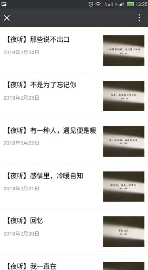

图2–14 “夜听”统一的封面图

需要注意的是，这种形式虽然容易形成自己的风格，但是也容易对文章打开率产生不良影响，我不重点推荐。

**@统一风格的定制图片** 有些账号虽然每次推送的图片都不一样，但是整体风格始终保持一致，一般都是由专门的漫画师、设计师制作，比如“胡辛束”“咪蒙”等。

**@封面图上统一做标记** 还有些账号虽然每次推送封面图都是根据内容来定，风格也有所差异，但所有图片上都会标记账号名称或账号logo，代表账号有“新世相”“胡辛束”“有书”等。

### 打造独有的文首和文末风格

文首和文末这两处有独特的位置优势，比较适合用于培养账号风格。

**@文首** 文首，顾名思义，就是一篇文章开头的地方。是用户打开文章后首先看到的内容，因此，这个地方是公众号打造风格的一个好地方，很多公众号都对其加以了充分利用，形成了自己的独有风格。

比如“差评”文首永远都是一张风格强烈的差评logo动图，图片下是根据文章内容提炼的两个小短句子，字号加大、字体加粗、居右对齐，让人记忆深刻；“拾遗”的文首则是用的固定模板，在一个竖框里，先是一张头图，头图下面是它的一句slogan“心里有束光·眼里有片海”，再下面是一个固定的小标志“拾遗物语”，下面就是根据当篇文章提炼选取的一个金句作为当篇的拾遗物语。这个模板中，每一篇变的就是那张头图和具体的拾遗物语，其他都不变，风格鲜明且稳定。

**@文末** 文章的末尾，同样是公众号打造自身独特风格不可忽视的一个重要地方。你同样可以在这里通过特殊的设定，比如安排一个特定的结语或板块来形成自身风格。

比如“新世相”的文末固定会有一个“晚祷时刻”，根据文章的内容，想一个用户在评论区互动的话题（如图2–15所示）。比如《多少黑名单，曾经互道晚安》，结尾就是“晚祷时刻：还记得那个跟你说晚安的人吗？”；“科技美学”的每一篇文章结尾都有一个投票……

[figure not shown]

图2–15 “新世相”文末的“晚祷时刻”

### 打造特别的排版风格

你的字号大小、字体颜色、配图风格、小标题版式、图片注释、特殊引用格式等，这些加起来就组成了你的排版风格，你要想拥有自己的账号风格，就要进行一番设计规划，一方面保证有你自己的特色，另一方面要形成标准，如果一天换一个排版的账号，哪怕你每天排得再精美，最后也留不下属于你自己的风格。

### 坚持固定的推送时间

这也是很多公众号都采用的一种方式，比如“新世相”便坚持“每天00：00推送。每天最后一分钟的人生学校”；“插坐学院”则“每天21点21分推送。准时充电”……坚持固定的推送时间，时间久了会形成仪式感，而这种仪式感会加强用户对公众号的记忆。

以上就是打造自己账号特有风格的四大技巧。需要强调的是，建立账号风格的技巧和方法远不止这些，选题、语言特点、人格化设定等各个因素都会对账号风格造成一定影响。这里为大家介绍的都是一些显性技巧，即从内容呈现角度来讲，实践时较有可操作性。

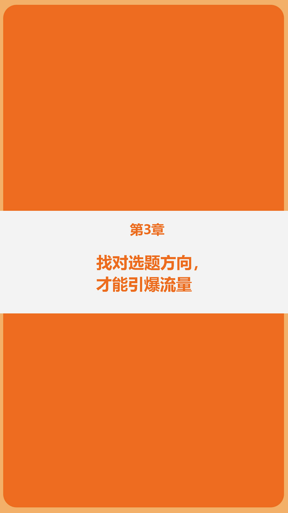

每一个成功的公众号，一定都有自己的鲜明风格。而风格的确立，则来源于运营者的选题方向。只有选题成功，内容才更有可能被用户点击、阅读。别再说“是金子总会发光”之类的老旧观点，选题如果不够吸引人，内容花费再多的精力也只是无用功。

## 做好公众号的内容规划

在所有的内容产业中，“内容为王”这句话永远不会过时。公众号的核心产品同样是内容，如果内容是1，营销是0，也许这个产品并不能走多远。但是，如果内容是0，无论你如何营销，也不可能找到出路。所以，保证持续提供具有用户价值、符合用户预期的优质内容尤为重要，内容规划是重中之重。

我认为，关于内容规划可以分为以下5个方面。

### 内容定位

内容定位也就是要明确自己想推送什么内容。你要不停问自己两个问题：我为哪一个细分人群服务？我能解决哪一个细分需求？当你不停地回答自己这两个问题时，内容定位的答案也就随之浮现了。

在描述内容定位方面，也有几个注意事项：首先是具体需求，而不是模糊需求；其次是真实需求，而不是伪需求；最后是垂直单一需求，而不是贪多求全覆盖的多个需求。在这方面，我可以为大家举几个成功的例子：

新榜：涨粉、变现、运营、观察，新榜给你不一样的新思路（见图3–1）。（聚焦新媒体人）

清单：买对东西，就是省钱。最专业的商品百科。（提供购物清单）

广告文案：只发广告，只发广告，只发广告。（每天分享优质广告案例）

[figure not shown]

图3–1 新榜公众号

比如，你做的是做创业投资服务的公众号，娱乐圈出现了大明星的新闻八卦，大家都在抢热点的时候，你要不要跟进？如果你有清晰的内容定位，你就能明确地告诉自己：不跟进。否则你就变成了“强行蹭热点”，表面上可能阅读量提高了，但这只是一时的，从长远的角度来看会伤害账号品牌和用户体验。

### 内容产量

内容产量很好理解，也就是推送内容的数量。现在有很多人都不清楚，自己的公众号应该一天推送几条信息？单推好还是多推好？是否有必要日更？周末、节假日还要不要更新？其实这些问题没有一个标准的答案。答案只能根据你们团队的产能来定。

其实，公众号内容的数量并不重要，最重要的是质量。现在是信息海啸时代，永远都不缺内容，真正缺少的是好内容。如果我们观察市面上的账号就会发现，没有单靠数量就可以做大的账号。反过来，你会发现有很多推送频次和篇数都很少的公众号，却凭借着质量获得了很高的人气。

比如互联网领域的“老道消息”、文化类账号“拾遗”、创业领域的账号“进击波”等，这些账号都不是日更，有的甚至是一周更新一篇，但一样能做成大号。你要记住一句话，并不是多推送一次就是多服务一次用户，如果你的内容质量不合格，每多推送一次就是多伤害一次用户。当内容质量不好的时候，没有推送就没有伤害。

所以，每个新媒体团队，根据自己的人员配置来确定产出量。这个产出量不能太高，要充分调动每个人的积极性，在保证质量的同时，又不能把每个人逼得太紧。因为写作是一个持续性的工作，有输入才能有输出，要让团队稳定、高质、可持续地工作和成长。

最后，还有一点很重要，那就是推送内容的节奏。比如我可以一周出5篇，那就周一到周五推送，周末不推。比如我一周只能出一篇，那就固定为周一发或者周五发，哪一天发其实没有那么重要，重要的是定下来就尽量不要变，给用户一个稳定的预期，也可以制造出一种仪式感。

### 内容形式

内容形式也就是指内容的组成结构，现在内容的形式一般就是这4种：文字、图片、音频、视频。你可以取其中一种形式，也可以多种形式组合。而具体该选用哪些形式，没有标准答案，而是应该综合考虑每一种形式的特点、成本等。

**@文字** 文字的优点是成本最低、制作效率最高、适用面最广，但缺点是进入门槛低、谁都能做、竞争激烈，用户新鲜感差、审美疲劳度高、时间成本高等。

**@图片** 图片的优点在于用户体验更好、用户接收信息更舒服、有竞争壁垒等，而缺点则是成本稍高、操作难度大、表达的信息密度不足、适用范围有限等。

**@音频** 音频内容的优点是能够节省用户时间、用户体验更轻松、更容易制造陪伴感、塑造人格化，但缺点是成本稍高、不方便操作接收信息的进度、不方便搜索查阅等。

**@视频** 视频的优点在于表现力最强、竞争壁垒高、市场稀缺，而缺点也很明显：成本最高、制作周期长、需要多人团队配合、会让用户耗费较多流量等。

当然，现在大部分账号都是综合几种方式，像“日食记”（见图3–2）和“办公室小野”就是视频+文字+图片，而“一席”“Papi酱”主要是视频+文字，“小北”则是音频+文字。

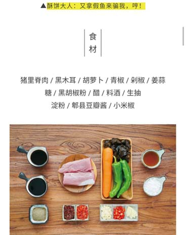

图3–2 “日食记”文章的内容形式

### 内容来源

目前公众号内容的来源主要有原创、采访、整合、约稿、UGC（User Generated Content，用户原创内容）、历史文章重发、转载等。对用户来说，这些内容来源没有优劣之分，只要保证用户价值就可以。但是，从账号运营者来说，这些各有利弊，需要你去权衡。比如，原创比较耗费时间和人力；UGC内容还要看你的用户数能否支撑你做，你的内容定位是否适合这样做；转载的话，好处就是相对节省时间、内容有保证，不好的地方就是品牌感稍差，定位上可能没有那么准确。

你要权衡各种形式的利弊，然后结合自己的内容定位及人员配置，来规划内容来源，最终确定出一个大概合理的配比，比如一周原创3篇、约稿2篇、转载2篇，一周7篇就搞定了。这样的规划，便于你制订每周的工作计划，做到心中有数，总之，最终的目的就是保证你能持续为用户提供好的内容。

### 内容调性

内容调性指的就是人格化和账号风格，这也是内容规划中非常重要的一个部分。

**@人格化** 你应该根据自己的内容定位和用户的特点，尽早设计一个能被用户接受、喜欢的人格化形象，然后一直沿用，不要轻易改变，这个人格化形象包括人格设定、语言特点、内容风格和价值取向等。

**@账号风格** 这个参考上一节的内容，设计独树一帜的账号风格。

以上两点加起来就是一个公众号的调性，并且这个调性与你的用户是相互影响的。你的调性越好越有辨识度，你的用户质量也就会越高，反过来你的用户群体也会一步一步去塑造你的账号。

内容规划的目的就是保证持续提供具有用户价值、符合用户预期的优质内容。只有能够做到这两点，才能避免“不知道推送什么内容”“无内容可推送”“用户不买账”的尴尬情况。

## 建立稳定的素材来源

作为新媒体编辑、内容运营，要持续地日复一日地为用户提供内容。无论你是原创、整合还是转载，输出强度都非常大。这样的工作绝对不能只靠灵感，也不能等需要素材的时候再临时去找，这样效率太低，也难以保证内容质量的稳定。

正如打仗一般，兵马未动粮草先行，我们首先要建立起一个供给稳定的粮仓、弹药库，才能去谋划战略、战术。一提起“素材库”这三个字，大家可能脑海中就会浮现出“在电脑上建立各种文件夹，分门别类地整理各种材料”的场景。这样太麻烦也太辛苦，很多时候我们对待工作要灵活处理，绝大多数时候只要利用好自己的手机就可以了。微信收藏夹、微信笔记、手机备忘录、锤子便签、手机相机、截屏、相册等工具都可以助你一臂之力。

### 标题库

标题永远都是文章中重要的一环，而且它的套路性非常强。因此，我们需要将各种类型的好标题都进行储存，以便平时分析、学习、模仿和套用。

这些标题来源于你账号上发过的所有爆款标题、你在朋友圈里看到的爆款标题、你在成功的公众号上所看到的爆款标题、所有的标题技巧干货文章中提到的经典案例。我们只需要将这些爆款标题放在微信收藏夹中，或者手机备忘录中就可以了，非常方便。

建立起标题库后，就要利用好自己的碎片化时间，多去读这样的标题。并且需要注意的是，一定要读出来，训练自己对标题的感觉。因为看和读所得到的感受是完全不同的。其次，在读这些标题的同时，要多问自己“为什么这个标题好，它使用了什么技巧，我应该怎样去借鉴”，多总结普遍适用性的套路。最后，写标题没灵感时，也可以拿出来浏览一番，激发自己的灵感。我有个做文案的朋友说过，他在动笔写文案之前，经常会先读一些诗——这也是一个寻找灵感的好方法。

### 选题库

选题是做内容中最重要的一环，你可以不储备内容存货，但是一定要储备选题。当你建立起一个选题库，就不会再陷入不知道该写些什么的焦虑中去了。

（1）首先将自己账号上所有做过的爆款选题都整理出来，这是一个巨大的财富，这些已经验证了的成功选题，每一个都要想办法裂变出5个以上的相关、相似选题。

（2）抽出时间将自己竞争对手账号上的爆款选题整理出来，从中裂变出自己的选题。

（3）朋友圈里每一个刷屏级的爆款文章，都要收藏放进自己的选题库中。爆款文章都充满了各种各样的套路，你要去拆解、分析，想想有什么值得自己学习和应用的地方。

（4）我们每天都在做选题分析，但最终可能只选用了一个。将剩下的选题放进自己的选题库中，这些都是以后做选题时思考的基础。

### 转载备选库

现在有很多账号是以转载为主，想要找到适合转载的内容，我们可能每天都要去上百个账号中寻找。

其实，刻意寻找反而辛苦，也很浪费时间。我们可以在每天刷账号、刷朋友圈时，看见一篇好文章就收藏一篇，如果用微信收藏就建好标签。如果有必要的话还可以分类收藏，不断丰富这个备选库里的内容。这样每次需要转载的时候，直接去收藏夹里选一篇就可以了。

### 写作素材库

这个素材库中储存的就是定好选题开始写文章时要用的东西，其中包括案例、文章、句子、图片。以我为例，现在我写任何文章都可以迅速调取出很多案例、文章、观点来用，这就是素材库的作用。

如今，我的微信收藏夹里已经建立了超过60个收藏标签，平时不管是在公众号还是在朋友圈里看到好文章，都会按标签分类放在收藏夹里。有时间的时候还会进行梳理，现在里面已经积累了几千篇文章。当我写东西的时候，就能够按标签和关键词迅速调取出来。

平时在各种地方看到精彩的句子、观点，我都会复制一下放在锤子便签或者备忘录中。这个动作其实只需要5秒钟，如果你真的没时间，也不要放过它，迅速截屏。看书看到好内容，看电影看到好的台词，你也可以用手机迅速拍一张。然后就是定期梳理你的便签、备忘录、截图、相册。

手机上看到好的图片，随时保存；电脑上看到的图片，及时上传到你的公众号后台素材库。比如有一个公众号插件叫“壹伴”，就可以实现一键上传图片。

### 灵感思考库

因为职业原因，我们每天都会读大量文章。在我们看的时候，脑子里经常会闪现出很多写作灵感、有意思的想法、不一样的思考角度，或者会突然想到标题可以怎样写、选题可以怎样做、策划活动的时候可以怎样等。这些灵光乍现的东西都非常宝贵，我们要及时记录，否则稍纵即逝。我平时一般都会用锤子便笺或者备忘录记下这些东西，没时间的时候就写下几个关键词，等有时间了再去整理。

工作中那些做得更好的人并不一定因为聪明，而是他做事有规划，愿意找方法，喜欢去整理、归纳、储备资源。这些都是很好的习惯，一旦养成就可以让我们的工作变得十分高效。

## 做好日常选题规划

新媒体编辑其实是一份很让人头疼的工作，要“日三省吾身”，分别是：今天发什么？明天发什么？后天发什么？所以，日常选题就变成了一个重要的问题。对于日常选题的规划，我总结出了以下6个技巧。

### 挖掘内容定位关键词

这个技巧不光可以帮你找出无穷多的选题，也可以帮你更好地熟悉行业、理解行业、解读行业，因为它需要你从定位的关键词中不断深挖。

比如，大家都非常喜爱的公众号“新榜”，它的定位就是“涨粉、变现、运营、观察，新榜给你不一样的新思路”。如果我们用它来做选题的话，可以随便从它的定位中选取一个大的关键词，比如“涨粉”。这个词值得挖掘的东西太多了，比如“涨粉方式”，进而延伸的“公众号快速涨粉的8种方式”，这就是一个很好的选题。然后我们将这8种方式挖透，也就变成了8个选题。最后我们为每一种方式找到3个经典的案例进行解读，就变成了24个选题。

### 针对用户的需求和痛点

想要找到用户的需求和痛点，就要回到用户真实的生活、工作、思考的场景中，在用户做一件事的每一个环节问自己，这个环节上用户可能遇到什么难题，我能够提供什么帮助？比如你做一个创业类账号，那么你的用户群体就是：创业者、潜在创业者、投资人，再宽泛一点可能就是科技互联网圈的从业者。

我们就拿创业者这个人群来说，创业需要项目，需要团队，需要融资，更需要产品。每一个都充满需求和痛点，我们再选取其中一个继续分析，比如“找项目”。找项目时创业者会想什么：如今的创业风口有哪些？什么项目成功率高？什么项目风险低？什么项目更容易拿到融资？什么项目属于低投入高产出的？什么项目进入门槛比较低？等等，其中包含着无穷无尽的选题。然后我们可以再针对每个痛点做案例式解读，于是出现了更多的选题。

### 借势热点

追热点大概是所有新媒体编辑的最爱，所以大部分新媒体编辑上班第一件事就是刷朋友圈、刷微博、刷行业垂直网站找热点。如果今天有热点，选题就变得容易多了。追热点时选题角度是很关键的问题，那么怎样找选题才能更好地追上热点，又不至于强行蹭热点呢？

在借势热点方面，我研究出一个公式：热点关键词+内容定位+用户痛点。

举个例子，如果你是创业类账号，七夕热点来了。首先你要想热点关键词，大概包括：七夕、爱情、恋爱、礼物、单身、虐狗等。结合内容定位和用户痛点，我们可以做的选题有：“创业者过七夕节指南”“七夕节，我该见投资人还是陪女朋友？”“马云、周鸿祎，你不知道的科技大佬爱情故事”“有一个正在创业的男朋友是怎样一种体验？”。

用这个公式追热点选题一定不会跑题，因为这个公式里有“内容定位”和“用户痛点”限定了选题范围，只要这样做，基本都能够符合账号定位。

### 紧跟同行

这是个非常有效的找选题方式，你要时刻关注你的同行账号、竞品账号、同类型账号。当然，这不是教大家偷别人的选题，而是因为你们定位相似、用户群体相似，他们的选题会给你很多灵感，而且是已经经过验证了的。

比如，如果我在创投圈做新媒体，当我没有选题可做的时候，我就会去看“36氪”“虎嗅网”“创业邦”“i黑马”“腾讯科技”等公众号。我会关注它们最近发的是什么选题，哪些效果还不错，我是不是也可以做一个这样的选题。虽然这个方式看起来没有什么技术含量，但却是最好用的一种方式，你一定要学会借力发力，站在别人的肩膀上进行思考。

### 借鉴爆款

这个方法和紧跟同行有异曲同工之妙，都属于通过灵感激发做选题。当你看到一篇爆款文章的时候，尝试给它变换一下场景，看看能不能运用到自己的内容中。

比如当我看到一篇爆款《你现在流的泪，都是找工作时脑子进的水》时，从“插坐学院”的角度出发，就可以改成《你写稿子时流的泪，都是定选题时脑子进的水》；如果是“创业邦”的角度，可以改为《你创业时流的泪，都是找项目时脑子进的水》；如果你是“咪蒙”的编辑，就可以改成《你婚姻中流的泪，都是找对象时脑子进的水》；同样的道理，如果你站在“有车以后”的立场上，可以将其改成《你开车时流的泪，都是买车时脑子进的水》。

### 开选题会

这个方法能够从工作机制上保证有选题可做。正所谓人多力量大，当你闭门造车而毫无灵感的时候，也许只需要别人稍微点拨，就可以脑洞大开。这种情况是很常见的，因为每个人都有着自己的思维定式，当我们陷入思维的怪圈中时，单靠自己是很难突破的。此时，你需要的是团队的力量。

你可以尝试每天固定时间开选题会，比如上午10点钟。选题会的时间不用过长，可以提前定一个大体的方向，让每个人都开动脑筋去思考好的选题点。在开会时，每个人都可以说出自己的思路、观点和角度，这些想法互相碰撞，激发彼此新的灵感，可能就会产生更多好的选题。

## 如何判断选题是否拥有爆款潜质

选题的重要性，已无须赘述。我阅读了大量新媒体编辑的写作后，发现大家普遍存在两个误区：

### 写作很努力，但对选题不够重视

大部分编辑在心中都没有把选题放在足够重要的位置，导致创作过程中经常会遇到这样的困惑：这一篇文章我写了三天，标题认真修改了几十遍，排版做到了极致，配图也很优美，确实已经足够努力，各种写作、推送的技巧都用了，但最后阅读量却惨不忍睹。这是一个普遍的问题，很多新媒体编辑都曾遇到过。

这是典型的“战术上勤奋，战略上懒惰”。怎么写是战术，写什么才是战略。一篇文章能不能成为爆款，我认为80%是由选题决定的。选题做不好，后面的努力注定低效。如果你能用三个小时写出一篇文章，那么就应该至少拿出一个小时甚至两个小时来决定写什么。

### 很重视选题，但判断不准确

有很多编辑已经明白选题的重要性，也很用心很努力地做选题，但就是做不好选题。一方面是因为大部分编辑的判断是非常感性、模糊、主观的。我经常能听到类似“我觉得应该是怎样”的说法，而不是根据各种数据进行判断。另一方面，很多编辑会去理性分析，但判断标准是错误的，用错误的判断标准自然得不出正确的结论。因此，你一定要建立起正确的判断标准。以下便是我为大家总结的爆款选题三大判断标准。

**@选题覆盖人群是否足够大** 这里的覆盖人群，就是指你选题的潜在阅读人数有多少。通常这是我做选题时首先会想到的，也是最重要的先决条件。有的选题能覆盖1000万人，那么你做一篇10万+阅读量的文章就没有那么困难；但如果你的选题一共就只能覆盖10万人，那你想做一篇10万+的文章可能比登天还难。

我做新媒体后写出的阅读量最高的一篇爆款文章，题目是《“双11”狂欢背后，是10000名阿里人在喝红牛、睡帐篷，甚至彻夜不眠！！》。这篇文章的阅读量是200万+，为什么能做到这个传播量？最重要的一点就是在“双11”当天选择这样的话题，它的潜在用户数以亿计。

我们来对比“插坐学院”的两篇文章，一篇题目是《微信公众号编辑排版规范（试行版）》，阅读量10万+；另一篇题目是《为什么你写的专业内容没人看？》，阅读量却只有2万+。

为什么同样的团队，做出的同样都是新媒体主题的、高质量的两篇文章，阅读量会有如此大的差别？原因就出在选题上。第一篇讲的是公众号编辑排版规范，这个选题的潜在阅读群体几乎是所有的公众号编辑和运营人员；第二篇讲的是“为何专业内容阅读量总是低”，这个选题的潜在阅读群体就少太多了，只有做的是专业内容且阅读量不高的公众号编辑、运营才会去看，所以它的阅读量注定没法与第一篇相提并论。

**@选题角度是否足够有痛点** 大家都明白，一个选题推送用户的数量并不等于它的阅读量。除非你用这个选题戳中了所有人中所有人的痛点。阅读量是怎么来的？就是当你把一篇文章推送给10万人的时候，如果你能戳中2万人的痛点，大概就会有2万左右的人看；如果你能戳中8万人的痛点，可能就会有8万左右的人看。因此要想判断你的选题能否成为爆款，就要看你的选题能否戳中足够多人的痛点。

比如，如果你要给10万年轻妈妈推送一篇文章，应该选择什么样的选题，才能让这10万年轻妈妈中的绝大多数都点开阅读呢？相比孩子穿什么衣服更好看，年轻妈妈们普遍更关心孩子喝什么牛奶、上哪所学校、是否玩得安全等内容，在这些内容中出爆款选题的概率更大。

举个例子，“年糕妈妈”几乎每篇文章都有10万+的阅读量，就是因为它的选题基本都能找准妈妈们的痛点。比如：《早教班要不要上？我们一口气问了200个妈妈》《几岁上幼儿园最合适，早入园还是晚入园？》《宝宝多大喝牛奶，怎么喝，怎么选，这一篇都全了》。

**@选题是否已被过度消费** 有句话大家都听说过：个人奋斗固然重要，但也要考虑到历史的进程。从微信公众号的角度来理解就是，这个选题被消费到什么程度了，或者说你做这个选题能否享受到时间红利，你能否赶在别人前面来消费这个选题。

比如当年的互联网创投圈的大事件——滴滴和优步合并。当时几乎所有的媒体都在追这件事，可想而知，对于这样的话题，你做常规选题肯定是很难出爆款的，因为所有人都在消费它，这就属于过度消费。当时我做了一篇《滴滴最早投资人：4年前投了70万，如今回报远超35亿，惊心动魄》阅读量却突破了60万+，原因何在？因为滴滴投资人这个选题当时几乎还没有人做，在覆盖人群足够大，痛点极其强烈又几乎没有被消费过的情况下，这就是难得的好选题。做这样的选题，出爆款的概率比较高。

突发热点要赶早班车，如果晚了就干脆不要追。需要注意一点，常规痛点每隔一段时间就会重新火一次，比如“要不要逃离北上广”和“90后员工到底可不可靠”，这些选题可以被反复消费。如果你做这样的选题，就要在一段时间内没人写这个选题的时候写，如果你写得好，不仅能做出爆款文章，甚至还有可能引领一波热点。

## 如何判断一篇文章的内容质量

新媒体行业中的每个人都在强调内容的重要性，但是究竟什么样的内容可以占据用户的心呢？对于文章的好坏，有没有几个简单可执行的判断标准呢？我们运营一个新媒体账号，每天做的工作就是写文章、约稿、找转载，每天都会面临类似“这篇文章好不好”这样的判断。学会判断一篇文章的质量至关重要。我曾用了很多时间去分析一些优质账号的优质内容，最后总结出高质量文章需要满足的5个标准。

### 提供新知

任何一篇好的文章都要做到提供新知。所谓“新知”指的是新知识、新认知、新故事、新材料等。总之，我们要提供给用户新东西，而不是老生常谈，要让用户看完有新的收获。

比如“李叫兽”的文章能让你破除大脑中对很多事情错误的认知；“罗辑思维”“果壳网”的文章能让你学到一些原来可能不知道的新知识；“丁香医生”“年糕妈妈”这样的账号，能让你在每次读它们的文章时产生“嗯，又学到了一招”的感觉；再比如新兴起的“老道消息”“桥下有人”这两个账号，我经常在看它们的文章时感叹“这家伙是从哪里找到这么多材料的”。其实它们就是在写马云、冯小刚、徐静蕾这些被大众熟知的人和事时，提供了新故事、新材料而已。

所以，当你写完一篇文章的时候，要从整体上去看这篇文章是不是为用户提供了新知识、新材料，是不是给用户提供了新鲜的观点和认知，是不是为用户提供了一种新的看问题的角度。

### 信息量大和信息密度高

我们经常会从文章的长短入手来判断一篇文章的好坏，其实这样的判断大多是没有意义的。文章质量的好坏与文章的长短之间没有必然联系。长和短不重要，重要的是信息量和信息密度，有的文章长达万字，但却字字珠玑，每一段每一句都很动人，这种文章用户是不会嫌长的。而有的文章虽然只有1000字，看起来短小精悍，但这1000字的内容其实只需要用100字就可以说清楚了，那这1000字的文章就太拖沓、质量太差了。

### 逻辑性强和论证精彩

在任何时代，文章的结构和逻辑都是很重要的。这里说的结构和逻辑，有些是形式上的，比如分模块、分小标题等；有些是内在的，我们读的时候就能非常强烈地感受到。逻辑其实是一种力量，这种力量能牵引着用户一步一步往下走，或者叫作环环相扣。

逻辑性不好的文章通常有两个特点：第一个是整体结构混乱，比如几个小标题之间关联、顺序不好，或者根本不是围绕着一个中心展开的，像一盘散沙；第二个是细节粗糙，经常表现为上一段和下一段之间的关联不够，甚至下一句话和上一句话之间都没有关联，或者跳跃性太强。

论证精彩也是好文章的一大特点。这一特点往往和文笔无关，而是看你写东西的时候，能不能确保所举案例好或引用的论据都非常准确、恰到好处，让用户看的时候拍案叫绝。现在很多文章都有一个共同的问题，就是举的例子和要解释、说明、论证的东西关联性不够强、不够贴切，例子本身也不够精彩。

关于文章的逻辑性和论证的精彩性，大家可以去看“李叫兽”的文章。另外“咪蒙”讲的每一个小故事都能非常精彩地解释说明她要表达的观点和传递的价值观，虽然她的观点和价值观我未必全都认同，但是她的论证过程确实精彩，让人叹为观止。

### 容易理解

不管你写什么，能够争取到多少人群的理解，就能拥有多大体量的用户。比如“李叫兽”“咪蒙”等，不管他们表达的东西本身多么复杂，都能做到让绝大多数人一看就懂。

我听说过这样一个故事。罗辑思维请某个领域的专家给普通人做科普专栏，每次录课程时都会让一个没有相关基础的人旁听，一旦他表示听不懂，主持人就会打断专家，告诉专家这个地方可能会有很多人听不懂，需要重新修改，让它变得更好理解。

我们在写文章的时候，要尽量让用户理解起来更容易一些，要把复杂的东西写简单——用已知的概念介绍未知的概念，用熟悉的场景解释陌生的场景，用简单的语言代替高深莫测的语言，这就是用户思维。我们写的文章是给用户看的，如果用户看不懂，内容再好也没有任何意义。

### 真诚沟通

真诚是发自内心的，一篇文章真诚与否，用户都能感受到。写文章更应该是沟通的姿态，而不是表达的姿态，表达是单向灌输，而沟通是一种双向互动，更像是和朋友聊天。

我之所以得出这样的结论，是因为我在其他渠道上推送我的课程时写过几篇广告软文，通过用户的留言反馈，我发现大家都不反感这样的广告，反而觉得我很用心，甚至明知是广告还会在朋友圈帮我转发。我在下笔写每一句话的时候，心里都是真诚的，而这种真诚用户一眼就能够发现。所以，如果你问我怎么才能做到真诚，我会告诉你：没有任何道路能通往真诚，真诚本身就是道路。

## 寻找优质的转载内容

公众号的内容来源有很多，转载是其中一种性价比较高的内容来源，也是很多账号内容中占比非常大的一个部分，甚至有的账号，全凭优质的转载就获取了百万用户。那么，如何才能找到优质的转载内容呢？我总结了以下5个方法，希望能对新媒体编辑有所帮助。

### 保持对优质内容源账号的关注

首先我们要关注足够多的优质账号，带着找转载文章的目的一个个去查看这些账号。如果认为将来要经常转载某个账号的内容，就将其置顶，之前转载过其文章的账号也要置顶。这个工作不需要一次完成，但是你要有这样的意识，持续去做这件事情。将所有看到的好的账号置顶，长期坚持就能积累一定数量的优质内容源账号。保持对这些账号的关注，当它们推送了适合又值得你转载的内容时，就第一时间与其联系，取得相关授权。

### 保持对优质微信朋友圈的关注

我本人大概有3000个微信好友，其中大部分都是新媒体的同行。因为职业的关系，这部分人通常都比普通用户拥有更广阔高效的信息获取渠道，而且新媒体人往往也具备更强的优质信息判断力，所以我每天都能在朋友圈里看到很多优质的文章，很多都是值得转载的内容。

我经常会对大家说，如果你要保证朋友圈内容的质量，首先，要多添加同行、圈内的微信好友。并且一定要加到一定的数量，起码是1000人以上，因为要保证样本足够大。其次，在你的好友中做一定的筛选，如果对方每天分享的信息质量不高，你就可以设置成不看他的朋友圈。这样，你的朋友圈里一方面文章质量比较高，一方面又有一定的数量，你就能每天从朋友圈里找到很多可以转载的内容。

### 保持关注优质账号的白名单群

白名单群就是为了分发自己的原创文章、扩大自己的影响力、给自己账号引流而建立的一个群组，群组都是原创能力比较强的账号，这个群组中经常会有转载它们文章的编辑和运营。多进一些这样的群，才能在群内出现优质的转载内容后第一时间发现并转载。

### 保持关注转载大号，借力发力

你的领域里一定有很多专门做转载文章的大号，这些大号可能一篇原创都没有，但是却广受好评。因为它们整个团队每天都在全网找优质内容，然后从中选取最好的转载。比如有个账号叫“不二大叔”（如图3–3所示），它从2016年4月6日开始推送，在短短4个月时间内就靠627篇转载获得了100万粉丝，而且在转载的文章中有41篇突破了10万+阅读量。

[figure not shown]

图3–3 “不二大叔”公众号

其实，此类账号并不在少数。找到你所在领域的此类账号，并每天留意它的动态，会让你省很多事。它已经替你做好了许多前期工作，你只需要直接从这些账号中选取一两篇好文章去申请授权就可以了。这个方法虽然取巧，但却着实有用。

### 查看优质账号的精选文章合集

很多优质账号为了更好地服务用户，会定期整理自己写过的优质文章，并将其放在菜单栏中方便用户查看。其实这就相当于帮你完成了筛选过程，这些合集中都是高质量、高用户价值、高阅读量的文章，当你找不到可转载文章的时候，可以直接在此处寻找。但需要注意的是，寻找转载文章时还要考虑一下时效性的问题，尽量转那些实效性弱、有长期价值的文章。

以上就是优质转载内容的5大来源，虽然看起来可能有些复杂，但实际上是一项很轻松的活计。我们平时浏览公众号、朋友圈时，就可以顺手完成这些工作。

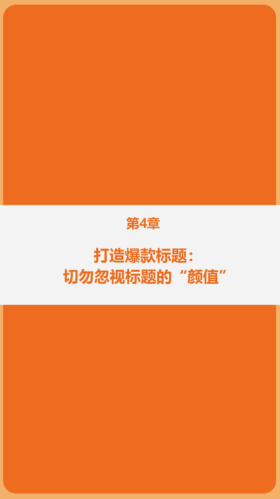

俗话说：好题一半文。只注重内容而不注重外在的思维已经过时，标题也需要“高颜值”。恰到好处的标题不仅能在第一时间激发用户的阅读兴趣，对整篇文章也能起到极佳的点缀作用。如果说文章的内容是“里子”，那么标题就是“面子”。在阅读节奏极快的微信环境中，一个好的标题作为文章门面的作用已被无限放大。

## 学会蹭知名度

我在线下课里接触过很多对新媒体感兴趣的学员，在和他们的交流过程中，我发现80%的学员都知道标题的重要性，但却仅仅停留在口头上。很多学员向我反馈：标题固然重要，但只是锦上添花，文章的质量更重要；有来回打磨标题的功夫，不如扎扎实实把内容做好。其实，在我看来标题就是一扇门，门外面是用户，门里面的才是内容。你在标题上花的所有精力，基本上只有一个目的：让用户推开这扇门。你在内容上花费再多精力，如果没有一个吸引人的标题，依然很难让用户推开门，看见你。

在明确了标题的重要性后，就让我们一起来了解打造爆款标题的第一个技巧：蹭知名度。简单而言，所谓蹭知名度就是借用知名度高的东西讲知名度低的东西。这个做法从古就有，古代的说法比较文雅，叫“攀龙附凤”，通俗的说法叫“借名人上位”。到了新媒体时代，我把它翻译成了4个字，称为“蹭知名度”。

而蹭知名度的好处也显而易见，首先是吸引眼球，自带流量；其次是权威性强，增加点击量。一个普通人说什么、做什么，大多数用户是不会关心的，而马云、雷军这样的名人有了新的动态，用户才有可能感兴趣。大部分新媒体编辑都抱过或者都见过别人抱马云的大腿，朋友圈里几乎一直存在标题为“马云：××××”的文章。但大家不知道的是，马云自己其实就是一个深谙此道的人。

马云在1995年的时候，经常说“比尔·盖茨说，互联网将改变人类生活的方方面面”。其实这句话并不是比尔·盖茨说的，而是马云说的。但马云那时候的知名度还很低，也不够权威，没有人会相信他说的话。所以马云就非常聪明地把这句话改成了“比尔·盖茨说”。虽然马云的这个方法属于“标题党”的范畴，但也证明了站在巨人肩膀上的好处。

在我看来，蹭知名度的技巧大致可以分为以下4种。

### 知名人物

如果你的文章内容主题包含一些知名人物，或者与知名人物相关，那么可以将这些知名人物的名字放在标题中。名人就是眼球聚集器，这是吸引用户最简单、直接、好用的方法。比如：

商务范：《杨幂换了90多套衣服，还是不像女boss》（如图4–1所示）。

拾遗：《罗振宇永远不会告诉你的秘密》。

年糕妈妈：《离婚了孩子就毁了？看看王菲和李亚鹏他们家！》。

年糕妈妈：《孙俪、姚晨都这样带孩子玩，一看就想点赞！》。

很明显，当这些文章的标题得到了知名人物的加持，人们就会有更多点击阅读的兴趣。

[figure not shown]

图4–1 “商务范”公众号文章

### 权威头衔

我们在创作中经常会遇到一个问题，那就是笔下的这个人物虽然很强大、很权威，但是却并没有很高的知名度。而这个时候，我们就可以利用他们的头衔，比如公司、机构、组织中的权威头衔。因为大家对这些头衔的认同度都比较高，很吸引眼球。

《曹菲：为何我工作十年，内心仍无比恐慌？》。

《卡兰尼克：我始终保有一份热情，即使输，也热爱》。

第一个标题，曹菲是一个很厉害的人物，但是大部分用户却并不知道这个人。但是我们将他的头衔“腾讯产品总监”加在前面，大家就会一目了然，并生出阅读的兴趣。所以我们将它改成《腾讯产品总监曹菲：为何我工作十年，内心仍无比恐慌？》。

第二个标题同样如此，卡兰尼克是优步创始人，其能力自然毋庸置疑，但是知名度却不够。所以我们要改成《优步创始人清华演讲：我始终保有一份热情，即使输，也热爱》。

### 权威机构

权威机构不仅知名度高，其官方性和权威性也具有使人信服的力量，从而使用户产生阅读欲望。

创业邦：《清华学霸创业4年估值200亿！徐小平投资生涯最大败笔，就是错过了他！》，这个标题特意用了“清华”这两个字。

金错刀：《16年前他被人民日报称为悲剧人物，如今他一手缔造5000亿帝国》，这个标题特意用了“人民日报”这四个字。

### 热点事件

热点永远占据最大的流量，当出现大的热点之日，也就是众公众号摩拳擦掌之时。比如：

年糕妈妈：《10个全职妈妈的前半生，还真不是罗子君那样》，这篇文章蹭的就是曾经的热播剧《我的前半生》的知名度和热度。

新世相：《差点忘了林肯公园，差点忘了年少的我》，这篇文章蹭的是林肯公园乐队主唱上吊自杀的热度。

咪蒙：《七夕，我在民政局排队离婚》，这篇文章蹭的是节日热点。几乎所有的重要节日都是热点，我们都可以去蹭、去追热点，比如中秋节、国庆节、圣诞节、情人节、母亲节等等。

最后我认为，普通的编辑往往是从文章的内容中找到提升自己文章阅读点击量的信息，而真正的高手却是写任何内容都能“请”高知名度人物、事件站台。

我在《雷军没瞧上，他50万开干，做出百亿市值的公司！上市前差点贱卖给马云！》这篇文章中写的是暴风影音的冯鑫。但是，因为冯鑫的知名度不够，如果直接在标题中出现，可能效果并不会太好。所以我就研究了冯鑫的创业经历，发现他和很多巨头都能扯上关系，然后我从中选取了相对知名度最高的雷军、马云放在标题中。

再比如我的另一篇文章《北京活得最通透的大学教授演讲：你活着，不是为了证明给别人看》。这篇文章以中央财经大学中文系教授刘树勇的演讲为引，介绍我围绕着演讲阐述的种种思考。虽然刘树勇教授见解独到，但知名度太低，无法像别的牛人那样吸引眼球。所以我放弃用刘树勇教授的名字做题目，改用“北京活得最通透的大学教授”，“北京”和“大学教授”这两个词显然更有知名度，再加上一个尖锐醒目的观点，来吸引大家的点击。

## 巧用数字

在如今无数公众号、文章铺天盖地来临之际，很多标题、内容都会被人们忽略，因为如今的用户每天要接收太多的信息、内容。所以，想要吸引用户的注意力，我们的标题就一定要醒目、一目了然，我在这里就向大家展示一下数字的魔力。

首先，数字有以下三大优势。

### 辨识度高

数字能迅速锁定用户注意力，文章展示在朋友圈的时候尤其明显，很有辨识度。比如：

创业邦：《68岁老干妈，身价70亿，开劳斯莱斯，政府送AA8888牌照，她才是中国最任性的女神》。

创业邦：《坑了170名员工，败光500万，CEO跑了，这只是创业公司倒闭潮中的一个样本！》。

深夜发媸：《2017年最难买的10支口红，我赌你一支都买不到》。

### 明确预期

现在用户的集中阅读时间越来越短，数字能给人基本的预期，能够说明文章架构和重点。比如：

脑洞运营：《这是一份可以让你从月薪3000到30000的运营资料包》。

毒舌科技：《任正非新闻联播讲话：48秒、230个字，却值得每个中国人反思》。

咪蒙：《注意，如何年薪30万的知识点来了》（如图4–2所示）。

[figure not shown]

图4–2 “咪蒙”的数字运用

### 具体直观

运用数字可以更直接地传递信息，让用户更直观、更快速地了解你想传递的内容。并且，研究表明，大多数人对数字更加敏感，数字自带吸睛的功能。“创业邦”的《张一鸣10年面试过2000人：混得好的年轻人都有这5种特质》（原标题：《张一鸣：混得好的年轻人都有这5种特质》）；“差评”的《能用5秒解决的事情，干吗要花3分钟？！》；“咪蒙”的《做到这6点，老板才会乖乖给你加薪》。

在明确了数字的优势后，我们究竟该用哪些数字？又该运用怎样的技巧呢？我总结出了以下4类。

### 人物的年龄数字

人物的年龄数字出现在标题中已经不是一件新鲜的事情，但并不是只要是年龄数字就能够吸引用户。我总结出一个独家套路：年龄小的就是年轻有为，年龄大的就是老当益壮，年龄不大不小的就去找其他角度。

《1998年的妹子创业，5个投资大佬争抢，融资1500万，90后大叔大妈咋想？》——年轻有为。

《56岁才创业，如今利润却是华为的1.5倍，他是个让对手发抖的人！》——老当益壮。

《17岁他说要把海洋清洗干净，没人相信，21岁他做到了！》——年轻有为。

《褚时健：年轻人太急了，我80岁还在摸爬滚打！》——老当益壮。

### 表示时间的数字

关于时间的数字也不是每一个标题都适用，与人物年龄数字一样，我为大家总结出了一个独家套路：耗时长的就是厚积薄发、匠人精神，耗时短的就是天赋异禀、发展迅速。比如：

《1分钟卖出30000件衣服，老板比比尔·盖茨还有钱，他靠一个字颠覆了整个零售业！》——发展迅速。

《4年350亿美元的背后，滴滴是这样干掉30家竞争对手的！》——发展迅速。

《这个日本匠人捏了40年的面团，结果连马卡龙大师都飞过半个地球来请教》——工匠精神。

《因为妻子的一句话，他在9平方米的拉面店待了46年，有人为了吃上一碗面，竟然等了9个小时》——工匠精神。

### 与金钱有关的数字

没有人不想多挣钱，也没有人会嫌赚的钱太多。看到关于钱的数字，大部分人都会感兴趣。常用的与钱有关的数字包括：收入、身价、价格、估值、融资额等。

《月薪3000与月薪3万的文案，差别究竟在哪里？》——收入。

《煎饼摊大妈：我月入3万，怎么会少你一个鸡蛋？》——收入。

《错失1800万融资之后，他用900元挽救了公司》——融资额。

《400块的洗面奶，居然还不如20块的好用》——价格。

### 数字替代形容词

其实只要你愿意，绝大部分内容都能用数字来表达或者强化，而且通常比用形容词更好。因为形容词只是一种较为模糊的表达方式，而数字则是直观、具体、有辨识度的表达方式。

比如穷和富、胖和瘦、高和矮、大和小、长和短、快和慢、远和近，这些都可以用数字去进行具体诠释。我们举几个例子来进行对比：

形容词：在《家里在一二线城市有很多套房是怎样一种体验》中，“很多”是一个形容词；

数字：在《家里在一二线城市有20套房是怎样一种体验》中，“20”这个数字让用户对“很多”的概念产生了直观的认知。

形容词：在《如何快速卖掉你的房子？》中，“快速”是一个形容词；

数字：在《如何在24小时内卖掉你的房子？》中，用“24小时”来具体化“快速”。

以上就是在标题中使用数字最常见的4种方法。其实在我看来，任何让人震撼的数字都可以放在标题中。你每次写完文章后，都应该将文章通读一遍，将所有带有数字的信息点提取出来，看看哪些数字更能吸引用户，更能让用户阅读后感到震撼，然后将这些数字放在标题中。

## 引发用户共鸣

新媒体时代的写作，都是互动式写作。在传统媒体时代，写作是表达，而在新媒体时代写作更应该是沟通。新媒体时代的阅读，要么是“文章与我有关”，要么是“文章对我有用”。如果你的文章和用户没有任何关系，那么无论你写得如何精彩，用户也不会去看。所以，我们在起标题的时候要引发用户共鸣，也就是增加代入感，让用户能感受到“文章与我有关”，或者是“对我有用”。

依照这一逻辑，我帮大家总结出了引发用户共鸣的4种方法。运用这4种方法，就能让用户在第一眼看到标题的时候，感觉到这篇文章是写给“我”的，是与“我”有关的，这样就能大大提高文章的点击率和阅读率。

### 身份标签

每个人都不能摆脱标签，比如你是一名新媒体编辑、你是处女座、你是个90后、你是某个明星的粉丝、你特别能吃辣、你喜欢宅在家里等。这些，其实都是你的标签。我们每个人身上都有很多的标签，并且人们通常会根据这些标签，自动地把自己归类到一个圈子里。所以，只要我们的标题中提到了这个标签，相应的用户就会觉得这篇文章和自己有关。比如：

“陈茂源星座”的《我想了解狮子座》中，标签是狮子座。

“姜茶茶”的《10万广告人总结出的甲方黑名单：服务完他们，半条命都没了！》中，标签是乙方。

“年糕妈妈”的《真正厉害的家长，都是陪孩子一起看电视的！》中，标签是家长。

“乐纯的伙伴们”的《拯救上班族！一款可以嚼着吃的酸奶》中，标签是上班族。

### 情感共鸣

这一种方法和标签法道理相同，我们可以用几种情感来让用户感同身受。当用户看到这样的标题时会觉得：我就是这样想的，你跟我想的一样。这种标题的文章是用户非常喜欢转发分享的，因为他能够借你的文章来表达自我、表达观点。比如：

插坐学院：《玩命工作，就是年轻时最好的生活》。

粥左罗：《哪有什么社交恐惧症，你还不是因为丑、穷、笨、混得差》。

咪蒙：《我借钱给你，我有错吗？》。

年糕妈妈：《谁说妈妈不能有脾气？我又不是忍者神龟！》。

拾遗：《你未必是人好，你只是没机会放荡》。

Spenser：《年轻人，你凭什么不加班》。

### 展示阅读回报

这种标题会让用户一看到就觉得：我看了这篇文章能有这样的回报。或者，即使这篇文章对用户本身没有太大帮助，但这样的标题也会让他觉得对别人有用，继而分享到自己的朋友圈中。比如：

黑马公社：《手机去除图片水印，如此简单强大我也是震惊了》。

咪蒙：《做到这6点，老板才会乖乖给你加薪》。

脑洞运营：《这是一份可以让你很牛很牛的运营工具包》。

脑洞运营：《有了它，你可以2分钟搞定一张海报》。

### 描绘场景

场景是比文字更加直观的表达方式，能给用户留下更为深刻的印象。用户一看到此类标题，就能在脑海中自动生成画面，标题描绘的场景会与用户脑海中本来存在的相似场景产生共振，自然倍受用户青睐。比如：

咪蒙：《剪完头发，我被自己丑哭了》。

果壳网：《明天就开学了，书本文具还没准备好怎么办？急！在线等！》。

果壳网：《为什么女厕所总是排长队？以及，怎么办？》。

年糕妈妈：《坐了个月子，我吃了一头猪十只鸡三百个鸡蛋……》。

我们写完一篇文章后，需要问自己几个问题：

第一问：我这篇文章是写给谁看的，用什么身份标签比较好？

第二问：我写这篇文章主要表达什么观点，这个观点可以引发哪些用户的共鸣？

第三问：用户读了我这篇文章能有哪些收获？

第四问：文章里有哪些比较典型的场景是大家都经历过的，是否要通过描绘这个场景来增加用户的代入感？

用这个思路逐步分析，并将最后提炼出的结果放在标题中，一个优质的标题便就此诞生。

## 戳中用户痛点

什么是痛点？痛点就是一切阻碍你变得更好的东西，是需要解决却尚未解决的问题。可能是成长过程中的，比如迷茫、焦虑；也可能是工作过程中的，比如升职慢、加薪少、公司没潜力；抑或是生活中的，比如婚姻困境、朋友关系处理得很糟糕，等等。用户一看到这样的标题，就会感觉到扎心、感觉到痛。

既然是阻碍人变得更好的东西，不妨将之理解为弱点。虽然每个人都有弱点，但也都有一颗向好之心。人的一生其实就是在和自己的弱点做斗争的过程，在标题中明确点出人的弱点，能够让用户一看就感觉到痛，自然就会忍不住点开看。

有部较为出名的电影叫《七宗罪》，很多人都曾看过。七宗罪来源于天主教教义，宗的意思是来源、根源，正确的提法应是“七罪宗”，分别是傲慢、嫉妒、暴怒、懒惰、贪婪、色欲和暴食。人类所有缺点的根源，不外乎这七宗罪。既然如此，新媒体文章标题当然也可以按照这7个维度展开。

### 傲慢

傲慢的本质是优越感。其实，朋友圈里“晒”的所有东西，都是在表现自己的优越感，无论是晒脸、晒腿、晒旅行、晒美食、晒女朋友，还是晒加班，本质上都是在晒他的优越感。晒优越感也是很多人发朋友圈的动力之一。优越感包括优越、自恋、虚荣、炫耀、成就等。利用好这一点的文章有很多，比如：

咪蒙：《我一个人活得好好的，为什么要结婚？》。

年糕妈妈：《新年这样带孩子出门，回头率800%》。

Look：《口红很贵吗？你为什么不能自己买？》。

改变自己：《为什么越没本事的人自尊心越强》。

### 嫉妒

嫉妒这个词中包含了不满、吐槽、比较、攀比、虚荣等情绪，大家看到这样的标题通常会想：竟然可以这样？为什么我没做到？我想要知道如何才能做到。比如：

插坐学院：《你做新媒体几年了？工资过万了吗？》（如图4–3所示）。

咪蒙：《那个150cm的矮同学，现在年薪百万了》。

咪蒙：《她凭什么才毕业2年，就升职3次，月薪从4000到4万？》。

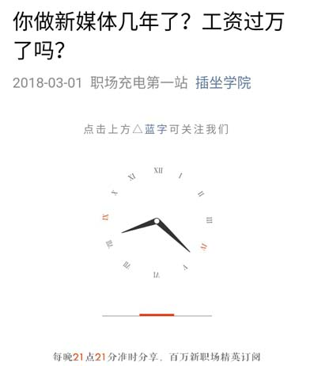

图4–3 “插坐学院”公众号文章

### 暴怒

有句古话叫作“喜怒不形于色”，而现在生活中，大家的普遍做法是“喜形于色，而怒不形于色”。也就是说大家在现实生活中的愤怒，一般都会在考量到社交关系的维系需求后不直接表达，但这些不好的情绪也需要一个发泄的出口，很多公众号文章正是充当了这个出口，用户借转发你的文章来表达自己的不满、愤怒等情绪。比如：

咪蒙：《别再让我给你的娃投票了！！！》。

咪蒙：《我借钱给你，我有错吗？！》。

年糕妈妈：《这样对待我的孩子，我是绝对不能容忍的！》。

### 懒惰

懒惰不是不劳而获，而是少干多得、少付出多回报、少投资多收益、少工作多赚钱等思维的集合。针对这一人性弱点，我们的文章标题可以像以下这样：

插坐学院：《阅读量10万+的标题怎么取？14种模板直接套用（先收藏）》。

i烘焙：《3分钟就能搞定的日式便当神作，慵懒的假期早餐赶紧做起来》。

### 贪婪

人的欲望是无止境的，总希望占有更多。涉及免费的、打折的、低投入高回报的信息往往能吸引用户点击。比如：

插坐学院：《1个好创意，可以帮你省掉30000块的文案（这里有22个）》。

咪蒙：《我有10个职场经验，价值100万，但今天免费》。

剽悍一只猫：《工作忙成狗，如何一年搞定365本书，打败99%的同龄人？》。

十点读书会：《养成这个习惯，你的增值速度提升10倍》。

### 色欲

食色，性也，但是我们在这里所说的“性”并非是性和色，而是与性和色有关的字词本身就有眼球聚集器的作用。由于尺度偏大，就不具体举例了，有需要的朋友可以自行摸索或者和我联系。

### 暴食

民以食为天，吃饭问题可是头等大事，很少有人能够抵抗来自美食的诱惑。因此，在起标题的时候，我们可以理直气壮地为“吃”正名，让大家觉得热爱美食是天经地义的事情，只有会吃的人才懂得生活。比如：

咪蒙：《这里有50份零食大大大大大大礼包，要送给你》。

咪蒙：《好吃到让我疯狂爱上北京的30家外卖》。

艾格吃饱了：《淘宝上有哪些好吃的飞禽？》。

日食记：《谁发明了这么好吃的土豆做法？》。

美食台：《做好口水鸡，三步就搞定！》。

利用用户痛点取标题的方法非常实用，需要注意的是，并不是每一个技巧都适合每一种标题。我们要熟练掌握，然后在具体的实践中巧妙地匹配，选择最恰当的那一个标题。

## 画龙点睛

所谓画龙点睛，简单而言便是当我们将标题写好后，在标题上再加一个点睛之笔，使标题更有说服力，进而吸引用户点击。对此，我发明了两个词——标题前缀、标题后缀，也就是在标题开头或结尾加一个词或者短语进行补充，让标题更出彩。

在这个技巧中，后缀更为常见，加后缀一般有以下5种方法。

### 定位人群

我们写完标题之后要进行确认，这篇文章我们更希望吸引哪个人群阅读，然后提炼出一个能代表这类人群的标签，放在标题后面，以便精准地触及此类人群。这样的标签有很多，比如职场新人必读、年轻人必读、房奴请进、有车一族、单身狗看哭等等。

《万科总裁郁亮：企业不再需要职业经理人了（职场人必读）》。

《88岁褚时健：垃圾产品+互联网，简直痴心妄想（创业者必读）》。

《7500字彻底讲透罗辑思维的最新战略（新媒体人必读）》。

### 加强推荐

加强推荐也就是在写完标题后，再加上一个加强推荐的词或者短语，比如强烈推荐、重磅推荐、某名人推荐、建议收藏等。

《2015年，杜蕾斯团队创作了哪些内涵文案？（强烈推荐）》。

《年轻人必看的10本书（罗永浩推荐）》。

《微信官方没教你的12项技能（建议收藏）》。

《打工思维vs老板思维（强烈推荐）》（如图4–4所示）。

《环时互动创始人金鹏远：关于社交网络传播，我有96条心得……（年度分享）》。

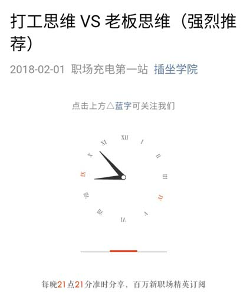

图4–4 “插坐学院”推荐文章

### 解释说明

解释说明就是给用户一个看这篇文章的理由，增加标题的说服力，吸引用户点击阅读。

《70篇文章，近200万用户，“毒舌”咪蒙凭啥刷爆朋友圈？（最全解读）》。

《一个人心理成熟的具体表现都有哪些？（知乎点赞破万）》。

《1个好创意，可以帮你省掉30000块的文案（这有22个）》。

《致新媒体编辑：请告别低质量的工作和学习（2年经验8000字深度思考）》。

### 补充亮点

通常写标题的逻辑是先提炼整篇文章的亮点信息，然后将其在标题中排列组合。在这种操作逻辑下，经常会出现多个亮点由于逻辑原因无法组织成一句话的情况。这时，我们就可以加个括号单独列出那个特别重要，但无法跟其他亮点放在一句话里的亮点信息。比如：

《西单女孩创业身价过亿，要做下一个董明珠！（或今年再登春晚）》。

《王思聪：要用一生去超越父亲（网友花17万，让王思聪回答了这32个问题）》。

《习近平演讲全文+视频，释放重磅信号！（科技圈大佬出场秀，周鸿祎又赢了）》。

### 赠送福利

这一点是当下最常见，也是最好操作的一个方法，一般在文章加“附、赠、含”这类词句，就可以吸引更多用户阅读。

《3分钟56张图，锤子T2发布会全程回顾！（附3个必看小视频）》。

《震惊！UC编辑部试题外露！（附参考答案）》。

《你和咪蒙的排版，差了一个留白的距离（附详细操作教程）》。

了解完后缀，接下来让我们再学习一下标题前缀的使用技巧。相比后缀，前缀的使用频次相对较少，一般会用一些吸引眼球、增加点击的语气词、感叹词，比如重磅、突发、爆料、颠覆、励志、惊呆等。比如：

《重磅！打车费将翻倍，百万司机将失业，网约车新规要给滴滴判“死刑”？》。

《独家重磅！锤子风云》。

《突发！四川阿坝州九寨沟县发生7.0级地震！》。

在使用前缀时，我们还要注意一点，就是要控制好比例，不要做“标题党”。无论是标题后缀还是前缀，技巧都很简单，但却非常实用。很多不为人知的小技巧，可能就隐藏在我们每一次的阅读中。

## 标题创作的补充细节

标题作为文章的“文眼”，对于整篇文章往往起着提纲挈领的作用。一个恰到好处的标题让文章锦上添花，而一个不合时宜的标题则可能让作者对文章内容付出的心血付诸东流。前文说了5个打造爆款标题的常用方法，足以应对绝大多数情况。接下来，和大家分享一些我在撰写标题时的实用心得，有些心得说出来大家可能都明白，但具体操作时却往往会忽视。殊不知，它们能让你在新媒体写作时百尺竿头，更进一步。

### 不要用第一眼看不懂的标题

这是我们撰写标题、优化标题的第一原则，咪蒙曾说过“不能在一秒钟看明白的标题都不是好标题”。这并不是低估用户的理解能力，而是在朋友圈的信息流中，用户只可能留给你一秒钟甚至更短的时间。如果用户无法第一眼注意到你的标题，你就失去了俘获他的可能。永远记住一句话：认知成本和传播效率成反比。

为了避免这样的错误发生，我建议大家首先多用短句、学会断句、少用复杂长句，还有要多用大众常用字词，少用或不用生僻字词，坚决不用大多数人都不认识的字词。最后，逻辑要清楚，语句要通顺。这是如今很多作者都做不到的一点，一方面是语言能力问题，另一方面是很多作者想在标题中尽可能多地罗列出亮点信息，最后导致混乱不堪。

比如，公众号“三节课”曾经发过一篇名为《研究了100场知乎live后，这是我对小透明如何做一场高质量知乎live的建议》的文章，这个标题就不够好，标题的后半句太长了，一句话超过了20个字。“小透明”这个词放在标题中，已经违背了让人一眼看懂的原则。

### 标题中要多用“你、我”这两个字

之前我们说过，做内容要有代入感，而“你”“我”这两个字天然就有这样的能力。

比如“咪蒙”发过的《你凭什么穷得心安理得？》，用户一看到这样的标题，产生的第一反应就是：这文章不就是在说我吗？

### 标题中可以多用痛点字词

我研究了很多爆款文章后发现，这些文章的题目中几乎都存在至少一个会刺痛用户的字词。比如“穷”这个字，我们每看到一次，神经都会被刺痛一下。

LinkedIn：《BBC跟拍了49年：穷人与富人到底差别在哪里？》。

新世相：《如何度过20岁开头的穷苦日子》。

我们可以梳理一下这些词，比如穷、丑（如图4–5所示）、胖、矮、失败、自卑、封杀、离婚、出轨、谋杀、自私等。一方面，将这些词梳理出来，我们就会有意识地去灵活应用这些词；而另一方面，就是我们要去研究这些词，去思考为什么这些词能够刺痛大家，时间长了你就会更了解人性，越来越接近传播的本质。

[figure not shown]

图4–5 不二大叔公众号文章

### 标题尽量不超过32个字，最好在27字以内

说到标题的字数，很多人都陷入了一个误区，就是认为标题越短越好。其实，标题的长短并不是判断好坏的标准，而是我们应该在精彩程度不变的情况下，优化得越短越好。因为在精彩程度不变的情况下，标题越短认知成本就越低，传播效率也就越高。

但是标题的长度有一个上限，上限的标准就是朋友圈能显示的最多字数。而且我发现，苹果手机和安卓手机显示的上限是不一样的。苹果手机的显示上限是27个字（汉字），而安卓手机是32个字。另外，在标题中，一个标点符号就相当于一个汉字，两个阿拉伯数字相当于一个汉字。

### 标题要兼顾点击和分享

点击率和分享率并不一定成正比。很多文章的标题表现出了人性的阴暗面和劣根性，这种做法确实能够有效提升点击率，吸引用户阅读。但是，这样的文章有多少人愿意分享呢？愿意分享的人中又有多少不是设置了分组的呢？切记一点，相对于微博，朋友圈是一个熟人圈子，里面有自己的父母、同事、领导，所以我们不要写用户不好意思分享的标题。

同样的问题也存在于某些过于幼稚和极端的标题中，这些标题也只能提高点击率，却不能提高分享率。相信大家在转发朋友圈文章时，或多或少都遇到过类似的情况：明明觉得内容很好，想转但又不能转，就是因为标题用力过猛了。

### 标题要兼顾点击和转化

物以类聚，人以群分。你用什么样的标题就会吸引什么样的用户阅读，我为这个现象起了个名字叫“流量定位”。流量本身没有价值，它是产生价值的通道。

比如，如果你要靠软文来卖一个很正经、很有品位的东西，但是你为了点击量，起了一个非常低俗的标题，那么这篇文章的点击率可能会很高，但转化率却为零。因为你用这个标题吸引过来的人，和你的目标用户完全没有关系，这就是流量定位。所以，很多时候我们并不需要没有价值的流量。

### 前10个标题可能都没用

所有优秀的标题，可能都是经过几十次甚至上百次的打磨，优化出来的，别奢求短时间内就能想出一个爆款标题。

“一条”创始人徐沪生是个资深媒体人，但他在刚创业做“一条”这个公众号时，每天都要亲自起标题。据他自己说，经常一个标题要修改100遍以上。

千万级流量大号“咪蒙”对标题更是严苛。同一篇文章的标题，咪蒙都会让团队中的每个人反复多次修改，每个人都选出一个相对满意的，这样大概能产生五六个备选标题。此后，再在团队内部进行集体讨论，同时将备选标题发到很多标题顾问群中，让大家给自己满意的标题投票，最终找到最能触碰用户心灵的那个点。

比如，2017年7月13日，“咪蒙”的头条标题是《原来婚姻，就是我们背对背玩手机》，这个标题是从6个备选标题中脱颖而出的，其他5个标题分别是：《明明是两个人，却活得比一个人孤单》《我独自一个人走完了我们的结婚纪念日》《我在床上哭成狗，你在旁边睡成猪》《因为孤单我结婚了，因为孤单我离婚了》《我和你：陌路。朋友。爱人。陌路。》。

任何一个爆款标题都要经过反复打磨，即使咪蒙这样的高手亦是如此。百分之百完美的标题是不存在的，推送之前我们都可以尝试改得更好一些，要有耐心，要有追求极致的心态。

### 优化标题的5个注意事项

**@用阿拉伯数字代替中文数字** 大家在起标题时，都知道数字法则。但是很多人都不知道的是，要使用阿拉伯数字，而不是中文数字。因为从视觉效果上，阿拉伯数字更能吸引眼球。

**@不要重复用词** 同一个词尽量不要在标题中出现两次，如果有，就尝试换一种表达方式。

**@学会前置亮点** 把标题中最精彩的部分放在前半句，要让用户第一眼看到时就被吸引住。

**@删掉或替换不痛不痒的字、词、句** 请珍惜标题的每一点位置。

**@规范标点符号的使用** 标点符号规范化，不要省略标点符号，也不能滥用标点符号。

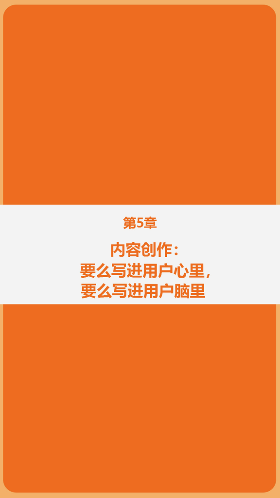

作为品牌公众号长久运营的支撑载体，内容从根本上决定了品牌公众号的粉丝规模与用户忠诚度。可以说，凡是能被用户眼睛看到的、耳朵听到的文章，都是我们进行内容创作的对象。而想要做好内容编辑，我们就应当从形式和主题两方面入手，对公众号文章的各个部分进行精心创作。

## 快速提升文章可读性

所谓“可读性”，是指文章流畅易读，让用户在阅读文章的过程中，从头到尾都感到顺畅、爽快，主要有以下4种技巧（如图5–1所示）。

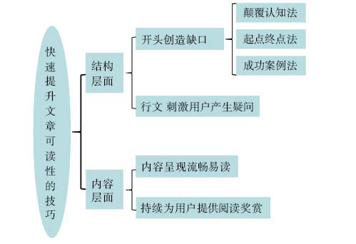

图5–1 快速提升文章可读性的4个技巧

### 开头创造缺口

要卖米饭就得先让顾客感觉到饿，要卖大衣就得先让顾客感觉到冷，这种方法被称为“创造缺口”。写文章也是如此，你想让用户读你的文章，就得激发出用户对这篇文章的渴望。具体有以下3个方法。

**@颠覆认知法** 长期以来你一直认为是对的事情，有人突然告诉你那是错的，你的固有认知就被颠覆了，继而激发出对“正确”的渴望，这就叫颠覆认知。我们可以将反常识、反直觉的内容放在文章开头，让用户产生一探究竟的欲望。

例如在一篇名为《Facebook最强女皇，年薪3000万美元，扎克伯格都怕她！》的公众号文章中，作者于开篇处便写道：“Facebook（脸谱网），大部分人只知道扎克伯格，其实呢，在Facebook最有分量的，应该是谢丽尔·桑德伯格。”

**@起点终点法** 只讲缘起和结尾部分，能激发用户对“过程”的渴望，继而阅读下去，这便是起点终点法。该手法通常用于人物写作，特别是励志人物故事的写作。先讲某人的起点低于尘埃，再说这个人最终达成了何种成就。这样一来，用户就会非常好奇这中间存在着怎样的一个励志过程。

在公众号“商务范”2014年发布的一篇文章《今天你对我爱搭不理，明天我让你高攀不起》中，作者用了这样的开头：“‘15年前来美国要200万，被30家VC（风险投资）拒了。我今天又来了，要200亿。’9月8日，马云在阿里巴巴路演现场，说了这样一段开场白。”

**@成功案例法** 人人都渴望成功。当你要表达一个方法、技巧、观念、观点时，如果你能找到一个正面、成功的案例，那么你的内容就更具说服力。

### 行文刺激用户产生疑问

对于文章主体部分内容的写作，有时候我们与其直接告诉用户答案，不如先让用户产生疑问，抓住用户的注意力，让用户的脑子转起来，并对问题答案产生预期。注意，这里是指让用户产生疑问，而不是持续地提问。很多时候疑问会暗藏在陈述句里，我们要学会这种写作技巧。

我们要写关于网约车新政的文章时，一般会这样写：

“下个月1号开始，北京将出台网约车新政，受新政影响，打车费将翻倍，经常打车的用户日子可能要不好过了。”

这句话是平铺直叙的风格，没有疑问。如果你的行文一直这样直白讲述，用户就会疲倦。而如果你改成有疑问的句式：

“注意啦，经常打车的用户日子要不好过了（疑问出来了：为什么不好过），打车费要翻倍了（这句回答了上句的疑问，又引出了新的疑问，为什么打车费要翻倍），因为下个月1号起，北京将出台网约车新政（解答疑问）。”

改之前和改之后表达的意思完全一样，但修改之后的版本，更能让用户产生一探究竟的好奇心，继而对文章欲罢不能。

其实，不光一个段落可以用“疑问法”，我们在整篇文章都可以这样持续发问。句子与句子之间、段与段之间、小标题与小标题之间、不同模块之间要遵循一个大逻辑：让用户的疑问持续地发酵。

### 持续为用户提供阅读奖赏

什么是“阅读奖赏”，结合自己的理解和实践，我认为阅读奖赏就是：在这篇文章必须传达的内容外，我们为用户附赠一些超出其预期的东西。

为文章多配一些高质量图片，在文章中插入一些与内容相关的精彩视频，在文章中穿插一些段子、金句，这都属于阅读奖赏的范畴。应该说没有这些增加阅读趣味性的东西，文章一样成立，但一旦加上了这些内容，用户会更加有兴致。

在公众号“新闻哥”中，编辑人员会在每篇社会新闻中插入很多令人忍俊不禁的图片。而在专讲运营干货、分享运营工具的公众号“脑洞运营”中，编辑人员则热衷于使用表情包提高文章的趣味性。

### 内容呈现流畅易读

很多时候，用户之所以不愿意读你的文章，并非内容本身有问题，而是内容的呈现方式有问题，即排版有问题。很多文章明明写得非常好，但视觉呈现却做得一塌糊涂，最终落得一个无人问津的结果，实在可惜。而如果我们在视觉层面做文章，让文章整体有序、结构清晰，那么用户的阅读快感就会增强。

为了达到流畅易读的效果，我们首先要做到内容模块化，多提炼些小标题，让文章看起来有层次感，这一点可以参考“插坐学院”“麦子熟了”等公众号。其次，分段应合理，不要一段文字动辄八九行甚至十几行。一般5行刚刚好，最好不要超过8行，这个可参考公众号“罗辑思维”。最后，配图的尺寸、风格、字体字号都要统一，确保文章整体美观大方，这一点可以参考“深夜发媸”等公众号。

以上就是快速提升文章可读性的4个技巧，我们在实际写作中，应因势利导、综合运用，不必拘泥于其中一种方法。

## 龙头凤尾：爆款文章的开头和结尾

成大事必慎其终始。如果说文章的标题决定了用户是否会点击你的文章，那么开头部分就决定了用户是否会深入阅读文章的内容。而当用户的阅读行为接近尾声时，他们对文章的态度也会逐渐成形，若我们在此时能够对末尾部分多做提炼和打磨，用户便能被含义隽永的文字打动，继而记住我们的公众号。

### 开头的写作方法

开头的写作基本原则是：迅速锁定用户注意力、激发阅读兴趣、避免啰唆。具体来说，我们可以采用以下7种方法开头。

**@摘要开头，浓缩精华** 用最短的语言总结文章的主要内容，并在提炼的过程中尽可能把文章的精华部分展现出来，让用户读开头的时候感觉到趣味性。

公众号文章《马化腾：我最大的担忧，就是越来越看不懂年轻人的喜好》使用的就是摘要式开头的方法：“在这篇文章中，马化腾先生从早期创业开始回顾，涉及创业公司的生存之道、QQ迅速发展起来的背后原因、推出微信前后他幕后的思考、他做产品的一手实操方法、投资Facebook与snapchat（色拉布）的总结以及他最大的担忧。”

**@表明观点，亮出态度** 用户阅读、转发一篇文章的过程，实际上也是他们为自己支持的观点投票的过程。社交媒体时代，“有鲜明主张、有明确态度、有自己观点”的文章明显更受用户瞩目，年轻人更重视“表达的权利与自由”。所以，我们可以在文章的开头就亮出自己的态度，说出自己的观点。

**@与你有关，对你有用** 我们可以在开头直接向用户表明这篇文章对于用户的益处，以便让用户直观感受到这篇文章“为我而写，对我有用”。比如，公众号文章《重磅！打车费将翻倍，百万司机将失业，网约车新规要给滴滴判“死刑”？》开头是这么写的：“憋了一个国庆假期，昨日一枚重磅炸弹，将影响所有人的出行，并改变数百万出租车司机的命运！（大家都做好今后打车费翻倍的心理准备～）”

**@描述痛点，戳中用户** 我们可以先思考一下自己的文章要解决一个什么样的用户痛点，然后你就可以在文章开头对这个痛点进行描述。用户只要点进来一看，就会有一种“哎呀，这说的不就是我吗”的感觉，继而就会为找到问题的解决之道而继续阅读。

**@提出疑问，激发好奇** 好奇心是人类共有的天性，如果你能在开头想办法激起用户的好奇心、让用户产生疑问，他就一定会带着“找到答案”的心态继续阅读。

**@引发共鸣，增加认同** 每个主题都设置有相应的金句。这些金句机智、幽默，非常讨巧，用户读来会产生一语道破天机的感觉，既有共鸣，也有传播力。

**@直接说事，欲罢不能** 这种写法基本没有铺垫，也没有大段大段的观点阐述，就是直接说事。所以从用户阅读第一句话起，他们就会被作者置入一个场景中。这种开头通常会使用较为紧凑的语言，每句话之间环环相扣，让用户欲罢不能。

### 结尾的写作方法

在很多人看来，结尾对于文章的价值微乎其微，事实上结尾的作用绝不亚于开头：结尾一方面要与文章开头首尾呼应，帮助用户总结文章的内容，加深印象；另一方面还需要升华文章主题，继而激发用户共鸣。很多时候，用户的转发行为来自其对结尾的欣赏，因而结尾的写作也颇为讲究。我们可以从以下4个角度撰写结尾（如图5–2所示）。

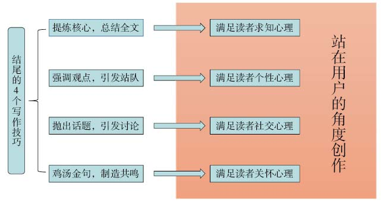

图5–2 结尾的4个写作技巧

**@提炼核心，总结全文** 在结尾部分梳理一下文章的观点，能够有效加深用户的印象。我们可以用一句或几句话来阐述一下整篇文章的中心思想、核心立意和论点。

在公众号“咪蒙”名为《985学霸，生于农村，死于传销》的文章结尾处，作者这样写道：“对于星华来说，地心引力实在太重了，他无数次地跃起，最终都只是被牢牢地拽回地面。而我们这些漂浮在新鲜的空气里的人却从没想过去拉他一把，只是嘲笑着他摔倒的丑态，终于有一天他被拽进了那口枯井，再也没有跳起来。不是所有人都有资格轻盈地度过一生的。”

**@强调观点，引发站队** 既然用户阅读、转发公众号文章的行为可以被认为是一种“投票”行为，那么我们就应该主动迎合用户的喜好。除了在开头、正文处阐明相关观点，在结尾处我们依然要对这些观点进行强调，以便让用户感受到作者的倾向性。

**@抛出话题，引发讨论** 在社交媒体上，话题就是“硬通货”。如果你的结尾可以制造话题，也就相当于为用户提供了“社交素材”。用户获得了这些社交素材，便有很大可能会在他们的朋友圈中传播你的文章，因为他们围绕你的文章可以完成交流、吐槽等社交行为。

**@鸡汤金句，制造共鸣** 在结尾处引用一些情感美文、名人名言是极为常见的一种写作技巧。鸡汤永远都是刚需，人的内心总是需要抚慰，故而“心灵鸡汤”就成为刚需产品。充满正能量、励志的句子总能有意无意地激发用户的积极心态。

开头为始，结尾为终，有始有终，才能掷地有声。对于上面讲述的这些关于开头和结尾部分的写作方法，大家应当将其与自己文章的主题、风格一一比较，继而选取出最适合自己文章的开头、结尾形式。当开头结尾真正成为“龙头凤尾”时，相关的文章自然就具备了成为“爆款”的潜质。

## 导语、摘要的写作要点

在逼仄的推送界面中，我们不可能将文章的所有或大部分内容展示给用户。在这种情况下，若想让用户了解文章的主要内容或精彩片段，我们就必须设计特殊的文字格式。其中最有效的两个形式便是导语和摘要。

### 导语的写作要点

和正常的文章开头部分不同，导语会通过特殊的排版形式与正文分开。在导语中，我们不仅要将文章的内容提纲挈领地告诉用户，而且还需要对文章中最精彩的部分进行介绍。导语创作，我们可以遵循以下5种套路。

**@写一个内容推荐** 我们可以这样理解：编辑就是一个推销员，文章就是产品，用户就是点进来可能看也可能不看的客户。作为推销员，我们必须用一定的宣传词来吸引用户，而这个宣传词就是“内容推荐”。关于内容推荐我总结了三个模板。

模板一：这是我看到的关于×××最好的一篇，没有之一。

例如公众号文章《如果你还年轻，如何思考未来？这是我看到的最佳建议，没有之一》一文的导语是：“原文取材于硅谷第一孵化器YC的CEO（首席执行官）Sam（萨姆）的blog（博客）。这是我看到的关于年轻人如何思考未来的最好建议，没有之一。我的唯一补充建议就是：如果你还年轻，阅读三遍！（如图5–3所示）”

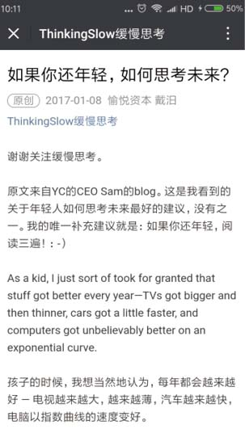

图5–3 公众号文章《如果你还年轻，如何思考未来？这是我看到的最佳建议，没有之一》一文的导语

模板二：这篇文章如何如何，就是写给你的／推荐给你阅读。

如《真格基金联合创始人王强：如何判断一个创业项目的好与坏？》一文的导语就是：“今天分享这篇，是王强老师的投资哲学，推荐每一个想有一番事业的人阅读。”

模板三：你是否也经常怎样怎样？你是否也经常有这样的疑问？这篇文章会告诉你答案／会给你解释／会颠覆你的认知。

**@写一个背景介绍** 科普一下选题、事件、作者、人物、时间、环境等背景知识，用户就能更好地理解文章主题所处的环境。

**@文章重点内容概述** 以简洁凝练的语言说明文章的内容。一可以明确用户的阅读预期，二可以降低用户的判断成本，三可以辅助用户理解文章内容。

如《董明珠独家回应：为什么员工必须用格力手机？她还认为，中国的税不算高》一文的导语就是：“针对要求格力员工都使用格力手机以及年终奖的话题，董明珠都一一回应了。董明珠还谈到了曹德旺、宗庆后等人反映的实体经济税负过重的问题。”

**@文章核心要点评论** 我们可以将文章的核心要点讲述出来，并做一个简单的点评。

**@主题金句亮点摘录** 我们把与文章主题相关的亮点、精华摘录出来作为导语即可。

如《吴晓波：为什么是张小龙？》一文的导语就是：“极简主义是互联网最好的审美观，如果某个功能已经做到极简化了，就不可能被竞争对手超越，因为我们是做到了什么都没有，你要超过我们总要加东西吧，你一加，就超不过我们了。”

### 摘要的写作要点

此处所说的“摘要”，不是位于文章前端的摘要，而是文章在推送界面封面图下方的摘要。在微信后台的编辑页面中，最下方有个小框，小框上写着：摘要，选填。如果我们不填写，系统会默认抓取正文前54个字作为摘要。由此可见，摘要是对正文的“剧透”，正是有了这种“先睹为快”的体验，用户的兴趣才会被激发。

撰写摘要，我们可以从以下3个方面入手。

**@写一句读后感** 一句感叹、一句总结、一个中心观点、一个紧扣主题的金句，都可以作为读后感。先告知心得，再引出正文，可以有效激发用户的好奇心。

如《她用5毛钱笔芯画了幅画，周立波开价20万想买，结果这个一穷二白的食堂服务员愣是拒绝了》一文的摘要就是：“难以想象，这个时代还有人能活得这么纯粹。”

**@延续标题，加强吸引** 在标题已激发用户好奇心的情况下，摘要应对标题进行进一步解构，描述一些我们在标题中想表达却没表达完的东西，继而强化用户的好奇心。如《比尔·盖茨白送他100万美刀，只因为他为一帮野孩子造了间奇特的教室》一文的摘要是：“这样造教室的，他恐怕是头一个。”

**@加强推荐效果** 我们可以以说服的预期，用各种直接、间接的方式告诉用户“这篇你应该看看”。如“李叫兽”公众号推送的《消费升级，便宜货一定没机会吗？》，它的摘要是：“消费升级，卖价格便宜的商品没戏了吗？这篇文章，李叫兽教你六个套路。”

以上就是关于文章导语、摘要的写作要点。在这里需要特别强调的一点是，导语和摘要作为我们对相应文章的宣传形式，其语言并不是文章中的内容。换句话说，导语、摘要对于文章只起点缀作用。因此，在撰写这两项内容时，我们应严格控制篇幅，避免“喧宾夺主”。导语一般不应超过50个字，摘要则更应被控制在15字以内。既然用户想要以最短的时间了解我们的文章，那么我们就应当以短小精悍的导语与摘要迎合用户的诉求。

## 如何提升转载内容阅读量

很多人在转载时，采用复制+粘贴的方法，中间没有任何再加工。其实，这样的转载效果并不好，因为未经修改的转载文章没有附加的价值。反之，如果我们对转载文章进行一定的修改，可以赋予这些文章我们独有的风格，其自身的品质也能得到强化。最终产生“青出于蓝胜于蓝”的效果。

提升转载内容阅读量的技巧主要有下列4项。

### 重新排版

重新排版的原则是：弱化原账号风格，强化现有账号风格。具体包含3点。

**@字号大小和文字颜色要改** 正文、重点语句、图表、小标题、引用内容、文字格式的风格信息全部要改成我们常用的，尤其得选用能凸显我们账号风格的品牌色。

**@特殊格式要换掉** 例如小标题，有的是黑色加粗、字号变大，有的是品牌色加粗居中，有的是实用排版工具里的小框框等，这种都要修改。

**@其他** 比如空格、分段、留白、图片等也要全都换成我们自己的风格。

### 增删内容

增删内容的原则是：更准的内容定位，更高的用户价值。我们在拿到转载授权之后，应先通读一遍文章，删除文章中一些多余的句子。然后根据自身的理解和需要，增加一些必要的内容。

通常，可以增加的内容有：能辅助用户理解、提高阅读体验的图片；与原文话题相关的视频；用户原创内容。

我们可以搜集一些与文章主题有关的、由网友创作的、有趣的内容，整合一下加入原文，这样会让文章元素更丰富，阅读体验更好。

这一点需要注意的是，增和删的篇幅都不要太大，很多只需要微调整，不需要给文章做大手术。

### 内容优化

内容优化的主要目的是将我们的传播策略加入文章中，本质就是将文章各个部分重新优化一下，以达到最佳的传播效果。主要包括5个方面。

**@重取标题** 标题一般都要重新取，你必须要把标题取得比原账号更好，大部分文章的标题都有很大的提升空间。

**@换封面图** 封面图除了更能吸引人点开，还要看是否符合自己账号一贯的风格，因此转载文章时封面图也是必须要换的。

**@开头结尾** 开头要改得更引人瞩目，结尾要改得更能刺激用户转发。这里的修改也可以是附加开头结尾。因为很多文章虽然写得不错，但作者没有传播意识，经常不去认真策划开头、结尾，我们转载过来可以重新编辑一下。

**@优化小标题，标注重点语句** 现在，很多公众号编辑人员没有小标题概念。大部分公众号文章往往从头到尾，没有小标题、不分层次。如果是短的文章这样做没问题，一旦文章长了，加之有限的手机屏幕和碎片化的阅读场景，用户的体验会非常差。

所以，我们在转载文章的时候一定要通读完整篇文章，然后看看文章都讲了哪几块内容，接着在每块内容前加一个吸引人的小标题。最后，帮用户画重点。

**@文字细节** 重点检查错字、病句或者不太好的字词句。

### 写推荐语

我们可以在文章的开头写一段推荐语，给这篇文章加上你的个性化解读。写推荐语的目的还是在于实现“内容私有化”，增加这篇文章的平台属性。

推荐语毕竟也是文章的一部分，即使用户知道这篇文章并非你的原创，也会增加对你的好感。因为他们知道你是认真阅读过这些文章之后才真心推荐给他们的。推荐语可以视为编辑人员对文章价值的背书，因为这毕竟是转载的文章，用户在阅读前会想：你凭什么要转载这篇文章给我读。所以我们要通过推荐语明确告知用户阅读预期。同时，坚持写推荐语对人格化的塑造也很有帮助。时间长了，推荐语就会成为我们内容风格的一部分。

以上就是转载文章的4个发布技巧。最后，大家还得注意两点：

首先，转载必须先拿到作者授权，并按照对方要求转载，必要时我们还要在文末注明版权声明，不能抱有侥幸心理。其次，转载的速度要尽量快，避免赶末班车。现实中，很多编辑只是追热点的时候有速度意识，但转载的时候就不着急了。其实转载也要抢时间，因为原创账号特别少，转载账号特别多，随着转载数量的增加，相关文章的价值将逐渐被稀释。这时候，哪家平台更早转载，哪家平台就能获得更多的关注。

## 如何搜索文章素材

当文章的选题与其他品牌公众号的选题雷同时，我们就需要出奇制胜，以“最多、最新鲜、最有料的素材”，进一步构建公众号文章的产品力。一般来说，我们常用的素材渠道有以下7个。

### 微信体系

微信的搜索优势在于：质量高、信息量大、全网联动。具体来说，我们可以以下列5点作为微信搜索的切入点。

**@朋友圈范围内搜索** 在微信聊天页面的最上方，有一个放大镜，这里就是微信体系的搜索入口。点击进入后，该页面有一行灰色小字“搜索指定内容”。下面有6个选项，朋友圈、文章、公众号、小说、音乐、表情。我们点击“朋友圈”这个选项，即可进入朋友圈范围内搜索。

**@指定朋友圈内搜索** 我们先进入朋友圈范围内搜索。然后，我们输入相关好友的微信昵称。之后，手机界面就会出现一行灰色小字——“搜索好友的朋友圈”，再下面会显示相关好友的头像和昵称。接下来，我们点击一下对方的头像或昵称就会跳转到该好友个人的朋友圈中。随之，页面就会显示他/她允许查看的朋友圈信息。

**@微信全范围搜索** 我们在搜索界面输入关键词，首先会出现微信聊天记录的相关内容，往下有一个选项“搜一搜关键词”，“搜一搜”下是微信全范围搜索的相关结果。点击“搜一搜关键词”，我们可以看到一个微信全范围的搜索结果页面，最上方的菜单栏中我们可以看到全部、朋友圈、文章、小程序、百科、公众号、视频、表情、问答、小说、音乐，分别代表不同范围内的搜索结果。

**@指定公众号内搜索** 指定公众号内搜索一般可通过两种方式实现：

第一种，公众号自带的搜索功能。当你关注一个公众号后，点击“查看历史消息”，历史消息页面的最顶部就有它的搜索入口。

第二种，新榜的“号内搜”功能**。**“号内搜”是移动互联网服务平台“新榜”推出的一个插件。相关品牌公众号一旦添加该项功能，即会将“号内搜”放在菜单栏中。我们只需点击“菜单—号内搜”选项，即可在指定公众号内搜索素材。

**@指定文章内搜索** 如果我们需要寻找一篇文章的指定段落作为素材，则可以先点击该文章页面右上角的多选按钮，接着点击“搜索页面内容”选项，然后在搜索栏中填入该指定段落中的关键词，即可迅速确定相关内容的具体位置。

当我们以“互联网经济”作为素材主题，并在公众号“创业黑马学院”上找到名为《王功权：消费升级会比想象的更快，如何开发2.3亿新中产市场？》的文章时，即可点击该文章右上方的“搜索页面内容”，在搜索栏中输入“互联网经济”字样，即可找到对应段落（如图5–4所示）。

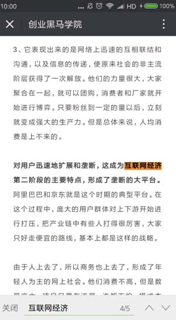

5–4 公众号“创业黑马学院”的文章关键词搜索界面

### 微博体系

我们登录微博之后在上部的搜索框中填入关键词，即可找到相关信息。在搜索结果页面的上方我们还可以按用户、实时、关注、视频、文章、图片、热门、印象、话题、主页对材料进行进一步筛选。

### 行业网站

几乎每个行业都有特定的网站，这些网站上的内容相对专业，也更符合我们的内容定位。我们只需在网页中键入这些网站的网址即可登录。

### 百度

在网页地址栏输入“https：//www.baidu.com/”，在搜索栏中输入关键词，即可在全网内找到相关的内容。

### 知乎

我们登录知乎，然后在页面顶部的搜索栏中输入关键词，即可找到相关内容。而当我们点击以相关关键词命名的话题，即会进入特定的细分区域。

例如当我们要寻找与“人工智能”有关的素材时，可直接在页面顶部的搜索栏中输入“人工智能”，然后点击“人工智能”话题，搜索结果的热度由高到低排列，即可轻松找到知乎平台最热门的人工智能话题（如图5–5所示）。

[figure not shown]

5–5 知乎话题“人工智能”的搜索页面

### 视频

登录优酷、腾讯视频、爱奇艺、哔哩哔哩等视频网站之后在搜索栏中输入关键词，我们就能找到相关的视频素材。一般来说，视频素材时长应在5分钟内，最好不要超过10分钟。

### 书籍

我们通过纸质书寻找素材时，可遵循两种思路。第一，从实用角度入手，我们可以寻找行业工具书，诸如《一个××从业者的自白》《××训练手册》《××枕边书》《手把手教你×××》等书籍都存在着大量的干货。第二，从内容稀缺性入手，我们可以剑走偏锋，从与特定内容相关的人物传记、人物专访、跨界书籍中寻找那些不为大众熟知的信息。

以上就是我们最常用的7个素材搜索渠道。需要特别注意的是，我们在撰写文章的时候，一定要为搜索素材预留出充裕的时间。如此一来，我们就可以在素材整理阶段通过各种各样的关键词在不同的渠道重复搜索，从而发现尽可能贴合文章论点、最契合用户喜好的材料。

## 引爆共鸣感

共鸣感，即文案所描述的场景恰好唤醒了用户记忆中本来存在的某个相似场景，两种场景的连接让用户感受到了心灵共振与感应，继而产生愉悦的心理感受。通俗点说，共鸣感就是用户认为作者替自己说出了心里话，这些心里话既包括正面的鼓励、支持，也包括负面的批判、打击。但无论是哪种理念，作者与用户的观点必然是高度重合的。

### 激发共鸣感的一般方法

制造共鸣的一个关键点在于：做到两种相似场景的连接。第一种场景是指我们的文案必须能描述出某种具体的情境、氛围、情感体验。第二种场景是指在用户的脑海中，存在着一个和第一个场景相同的、固有的场景。由此来看，制造共鸣的过程可被分为下列4个步骤。

（1）选定一个主题范围，并确定目标用户。

（2）寻找目标用户在你既定主题范围内有什么痛点。这些痛点类型一般包括：用户遭遇的否定、怀疑、反对，用户面对的不合理现象，用户面临一些问题时产生的心理障碍、消极情绪，用户对于自身得到外界认可的需要、放大的心理诉求等。

（3）针对目标用户的痛点，找到对策以支持用户。这些支持一般包括：用户反对的东西，你也表示反对、批判、打击、反击；用户相信的东西，你也表示支持、认可、帮助、鼓励等。

（4）将对策以用户听得懂、易理解的语言表述出来。

### 引爆共鸣感的特殊技巧

除了上面讲到的一般套路，我们还可以在内容的表现形式上做文章，用更感性、更直观的方法优化内容。

**@内容场景化** 场景，即特定的时间、地点、人物、行为、关系，也泛指生活中各种具体的情景。将内容场景化，我们既能给用户自己“接地气”的印象，保证内容的实用性，也可以结合实际工作解决用户的真实痛点，提高转发率。

打造场景化内容，我们可以从文章的选题、标题和内容这3方面入手。

文章选题的场景化。在每次做选题之前，我们要再次明确一下目标用户和内容定位，接着换位思考，将自己带回到真实的场景中，设想目标用户在体验公司产品和服务过程中的每一个节点、每一个场景。重点思考哪些痛点没有被满足，我如何通过做内容向他们提供帮助。

公众号“年糕妈妈”的目标用户是有小宝宝的妈妈。那么我们可以回到现实场景中思考，妈妈带宝宝的时候经常会遇到什么问题、产生什么需求、有什么痛点。这样一想，很多场景化的选题就出来了：

针对宝宝一理发就哭闹的场景，“年糕妈妈”做了个《90%的宝宝都害怕理发，4个妙招亲测有效！》的选题。

针对宝宝晚上老是哭闹不睡觉的场景，“年糕妈妈”做了个《轻松哄睡小宝宝的7个要点，10个诀窍》的选题。

针对宝宝不愿开口说话的场景，“年糕妈妈”做了个《没有不肯开口的孩子，只有不会引导的妈妈》的选题（如图5–6所示）。

[figure not shown]

图5–6 《没有不肯开口的孩子，只有不会引导的妈妈》一文的界面

文章标题的场景化。标题场景化的检验标准就是：用户一看到标题，就会唤醒脑海中相似的记忆。

文章内容的场景化。内容场景化的关键在于：讲故事、说案例、描述具体细节。

**@内容视觉化** 写文案的时候，我们可以把自己想象成一个画家，用文字作画，用户在看你的文案的时候，不断在脑中产生画面。内容视觉化包含下列5个技巧。

数据化表达。通过将模糊的信息量化，我们可以让描述性语言更加准确、具体，进而营造内容的画面感。

案例化表达。在我们想表达抽象的概念、观点、规律的时候，可以直接说一个具体的案例。

用形象化的比喻。将无形、陌生的内容比作有形、熟悉的内容，有助于用户的理解。

直接描述场景。对内容场景进行直观描述，可以有效增强用户的代入感。

多用名词、动词。名词、动词真实可感，用户在阅读这些关键词时，能够快速想象出相应的场景。

假如我们要形容一下“双11”的优惠力度，如果用“优惠双11”“优惠不停”这样的语言，用户会感到很空洞。而如果我们把这句话换成：“马云降价降哭了”或者“抢！100部苹果手机0元购，更有神秘大奖等你拿”，这样一来，名词和动词就能有效刺激用户，继而在用户脑中营造出对应情境，这种视觉化的文案能让人直接感受到优惠的力度。

**@积极使用表情包** 表情包自带场景和情绪，表达层面不仅更准确，而且还能传达出更多的语境含义。我们积极使用表情包，不仅可以避免文章内容同质化，而且还有助于塑造本平台的宣传格调。我们可从3方面入手，在文章中插入表情包。

建立素材库。我们可以将生活、工作中看到的表情包直接复制到单独的素材库里，用的时候直接调用就可以了。

公众号自带表情+“壹伴”表情库。公众号后台本身已经具备添加表情的功能，位置就在图文编辑页面的上方。同时，如果你安装了公众号插件“壹伴”，那么在后台还会有两个表情库，一个是常用的emoji表情，另一个表情库包括螃蟹大人的兔子、阿鲁、猥琐萌高清版、猥琐萌年代版这四套表情包。

微信内搜索。我们打开微信聊天页面最上方的搜索入口，选择里面的“表情”选项，输入关键词就可以搜索相应表情。

以上便是通过引爆共鸣感做出好内容的方法，无论是选取一般方法，还是使用特殊方法，我们都应抓住“共鸣感”这个牛鼻子，确保辅助内容、正文、用户心理三者相统一。

## 用音频和视频打造优质内容

目前，公众号的内容形式可分为文字、图片、音频、视频这4种。相较于纯文字或图文混合，编辑人员朗读所造就的声音信息无论是在形式还是内容上，都要更加贴合用户需求。而视频信息则可以为用户提供更完整、更立体的学习体验。由此看来，创作者若想让自己表达的信息更为用户所接受，就必须跳出“图文”的框架，大胆采用音频、视频等多媒体形式，打造优质内容。

### 音频的5个使用技巧

以声音传递信息的形式省去了用户主动接触的环节，故而大大节省了用户的时间，满足了现代人日益碎片化的阅读需求。同时，声音自带情绪、辨识度等特点，既能赋予文章内容额外的魅力，也能防止盗版。一般而言，音频在微信公众号有5个使用技巧。

**@将图文内容录成音频，插入文中** 我们在写完文章后，可以朗读原文，录音上传。再将音频文件插入到文章开头，既不单独用图文呈现，也不单独用音频呈现，而是将二者结合起来，满足不同用户、不同场景的需要。

当用户进入“十点读书”的公众号，并点击“精读名家经典”的选项时，即可看到很多知名作家或文化名人所撰写的各类文章。而在这些文章正文的开头，“十点读书”公众号贴心地设计了音频播放模块（如图5–7所示），点击模块左侧的播放按钮，用户就可以收听文章正文内容。在这种情况下，用户可以获得全方位的阅读体验。

[figure not shown]

图5–7 微信公众号“十点读书”的文章阅读界面

**@直接用音频呈现内容** 这个区别于第一种形式，第一种形式既有文字版内容也有音频版内容，这一类只有音频版内容。总体来说，晚上情感陪伴类文章、早上新闻资讯类文章、文学类文章等类型，更加适合用纯音频的方式呈现。

**@直接推送语音** 直接发语音省时省力，但形式和内容都未免太单薄，因此我不建议大家长期使用这种音频形式，偶尔用一些即可。因为偶尔发一次语音对用户来说是一个惊喜，它有助于将相关公众号人格化。

**@文首用语音对文章进行人格化推荐** 该方法其实就是用语音表述摘要，即内容依然以图文形式呈现，但你可以录一段语音来给相关文章做一个推荐，简单介绍一下这篇文章的主题、特点。

国内知名的新科技自媒体“科技美学”公众号，一直致力于通过形象生动的内容，为民众解读市面流行的各类数码产品。在发布一篇原创文章时，“科技美学”公众号的主编那岩都会事先亲自录一段语音，并放在文章的开头（如图5–8所示）。

尽管这些语音往往只有5分钟，但那岩却通过这些语音将文章的主旨层次清晰地展示给了用户，并留下了悬念。许多用户在听完那岩磁性的嗓音和略带幽默的语言之后，很快对接下来的内容产生了兴趣。

**@插入音乐，让用户边听边看** 音乐可以为用户营造一种促进阅读的氛围，继而增强用户阅读的体验。我们在公众号后台搜索，可以找到“QQ音乐”平台上的授权音乐，如果在那里搜不到，可以在其他平台下载，然后上传。

[figure not shown]

图5–8 微信公众号“科技美学”的文章语音推荐界面

### 视频的4个使用技巧

从2015年开始，越来越多的短视频项目拿到大额融资。随之而来的，就是“一条”“二更”“陈翔六点半”“Papi酱”“日食记”等短视频类公众号的迅速发展。一般来说，视频在微信公众号有4个使用技巧。

**@插入与内容主题相关的视频** 当你决定阐述一个主题时，你要通过其他公众号、微博、视频网站等渠道，搜索一下是不是有一些跟这个主题有关的、有趣的短视频。如果有的话，则应将其插入到文章中，以便通过形式的多样化带动用户体验的优化。

**@直接以精品视频做选题** 我们可以先找到一个既符合账号的定位，又能够吸引用户观看的视频，然后根据该视频所呈现的主题、内容做一个选题，写一篇文章。当然，这类文章在结构上应以视频为主，文字为辅，后者是前者的注释和补充。

**@将图文内容转化成视频** 制作完文字版的内容之后，我们可以通过真人出镜的方法，用类似于“视频讲座”的形式将相关内容再复述一遍，然后再将录制的视频稍加剪辑，插入到文首。在这里需要大家特别注意的是，这里的内容视频化工作，无须做过多的准备，更无须像拍电影一样进行加特技、画面渲染等繁复的后期工作，一切环节从简。

**@直接做短视频内容** 品牌公众号若想以短视频作为内容的唯一载体，就必须事先组建一支专业的视频团队。专业团队的加入，既意味着更高的人员、资金成本，也意味着相关公众号获得了多媒体层面的优势。所以大家在决定是否直接做短视频内容之前，应从公司战略、内容定位、资金规模、团队情况等角度审视相关工作的可行性。

以上就是我们用音频和视频打造优质内容的方法。很显然，音频制作比视频制作要容易得多、省事得多，因此我在这里向大家建议：在开展优质内容多媒体化时，可以先制作音频内容，再尝试制作视频内容。

## 写好名人大佬的励志故事

励志故事是朋友圈里转发最多的一种选题类型。大家普遍喜欢从他人的成功中获得经验。那么如何才能写好名人大佬的励志故事呢？我可以从以下7个方面着手（如图5–9所示）。

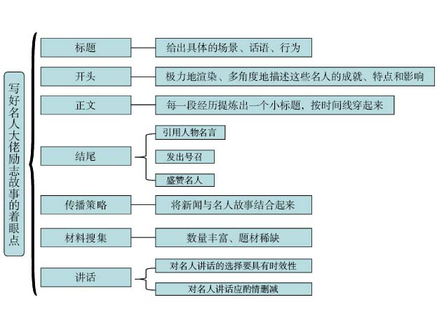

### 标题：直接有力

你要写这个人的过人之处在哪里，他干了什么惊天动地的事，他达到了什么境界。直接有力就是在表达这个人过人之处的时候，不要模糊、不要空泛，而要给出具体的场景、话语、行为。

《56岁才创业，如今年利润却是华为1.5倍，他是个让对手发抖的人！》

《靠给员工画大饼，一口气创办10家公司，身价过亿！他的创业模式吓傻周鸿祎！》

《30岁丧夫，36岁南下打工，放弃8000万年薪，董明珠为格力耗尽一生，图的啥？》

这些标题一看就能给予用户心灵上的震撼：这个人真厉害！

### 开头：吊足胃口

为了让人物励志故事在一开头就说服用户，我们要多角度地描述这些名人的成就、特点和影响。

比如《56岁才创业，如今年利润却是华为1.5倍，他是个让对手发抖的人！》一文的开头是这样的：

“宗庆后42岁创办娃哈哈，任正非44岁创办华为，陶华碧49岁创办老干妈，只要你有激情、有梦想、有野心、有渴望，什么时候创业都不算晚！

“而今天扒哥要跟你介绍的大佬，要比上面几位更颠覆，他55岁的时候还在打工，56岁才开始创业，如今他一年能赚下1.5个华为。而这样的获利状态，已不是一年两年，而是保持了几十年，其经营水平可谓冠绝群雄。”

这就是一个非常有吸引力的开头，吊足了用户的胃口，只要看了开头，用户一定会带着“这是谁啊这么厉害”的心态看个究竟。

### 正文：以时间为轴

以时间线写人物经历，就是从头到尾写这个人是怎么一步一步实现“草根”逆袭的。操作方式一般就是：在这个人从平凡走向成功的过程中，每一段经历提炼出一个小标题，按时间线穿起来。

在《56岁才创业，如今年利润却是华为1.5倍，他是个让对手发抖的人！》一文中，其正文部分一共有13个小标题，分别讲了主人公的少年时代：居无定所、颠沛流离；青年时代：美国留学，18岁考入哈佛大学；然后毕业后的工作经历，如何拼命工作、如何得到赏识、怎么升职以及最后为何辞职；接着写辞职之后如何重新出发、创业，创业过程中经历什么，创业成功后的守业思考等。

### 结尾：3种方式，提高转发

我们可以依照下列3种方式撰写结尾。

**@引用人物名言** 例如在《25岁成联想接班人，27岁被柳传志送进监狱，草莽英雄终成房地产大佬！》一文中，其结尾是这样的：

“孙宏斌曾有一段话：‘人原本生活得很好，原本可以不冒险，但因为选择了梦想，而遭受到困苦和失败。虽然中国人讲究成王败寇，但为了梦想和理想而拼搏，即使没有成功，也值得所有人尊重。因为这个世界就是靠有梦想的人去推动的。’”

**@发出号召** 例如在《44岁被开除，离婚欠债200万，27年后他成为世界第一！》一文中，其结尾是这样写的：

他们那时，远不如你。他们都是万里挑一的人，他们的特点就是一直在努力，梦想听起来不切实际，过的日子比你差，也没人知道他们这辈子能否成功。但是最关键的一点——他们受尽非议，却毫不动摇，一直坚持自己的信念，努力前行，直到成功！

**@盛赞名人** 例如在《30岁丧夫，36岁南下打工，放弃8000万年薪，董明珠为格力耗尽一生，图的啥？》一文中，其结尾是这样写的：

“董明珠，一个作风彪悍的女企业家，一个在互联网上长盛不衰的话题女王，一个脆弱、敏感的中国单身母亲。她不介意被黑，但决不允许任何人伤害格力，她像堂吉诃德一样在移动互联网时代为中国制造业摇旗呐喊，她的梦想是让世界爱上中国造，她不允许自己失败。”

### 传播策略：借助热点

人们对于新鲜信息具有天生的好奇心，若能将这些新闻与名人故事结合起来，那么相关文章的可读性将大大增强。

### 材料搜集：数量、质量兼顾

一方面，名人故事的信息量要足够充实，即对于大佬在任何时间、任何地点、任何阶段的成功经验，用户都能在你的文章中查到，而无须另寻他处。另一方面，被收录的名人故事应具备稀缺性，你要尽可能地发掘相关人物不为大众所知的材料。

### 讲话：二次包装

我们对名人大佬的讲话进行二次包装，一方面可以将公共资源私有化，提高辨识度；另一方面，还能增加名人讲话的附加价值，强化内容的稀缺性。

**@我们对名人讲话的选择要具有时效性** 一方面，在选取相关素材时，应选择最接近当下的讲话；另一方面，一旦得到相关名人大佬的讲话内容，应尽快处理、尽快推送，从而在传播环节占据主动。

**@对名人讲话应酌情删减** 即便是名人大佬的言论，也不可能做到字字珠玑，在原始素材中，总会有一些可有可无甚至多余的内容。对于这些价值不高或毫无价值的内容，我们应将其坚决、彻底地删掉，只留下精华部分。

大佬的故事一向为业界瞩目，而移动互联网则进一步放大了这些言论的影响力。马云的艰苦创业、窦唯的传奇经历、董明珠的负重前行……这些商业名人的经历，无一不具有成为“热点”的潜力，而全面而又有针对性地对名人信息进行重新创作，使其价值得到彰显，正是需要我们做的工作。

## 热点文章的策划思路

人天生对孤独有厌恶感，同时希望自己时刻处在社会发展的前沿。基于这种性格，人们会对社会上曝光的热点进行有意无意的追逐，以此获得外界积极的回应。因此，我们以时事热点和社会热点作为文章的切入点，可以有效吸引用户关注。

通常，策划热点文章可以用下列8种思路（如图5–10所示）。

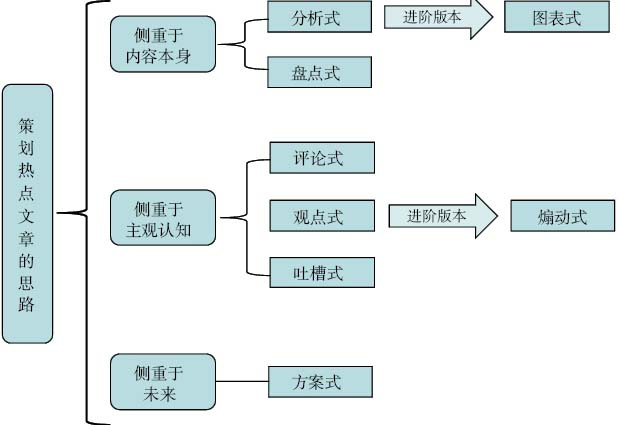

图5–10 策划热点文章的思路

### 分析式

开展分析式写作要求我们将自己定位为专家，以关键意见领袖的姿态向用户讲述热点的前因后果。这种平铺直叙的方式，其优点在于不会引起用户的反感，难点则在于工作量繁重。在实际写作时，我们可以以热点中的某一个场景、物品入手，由表及里地分析这些热点。

例如2018年2月25日，当天正值平昌冬奥会闭幕。国内一家广告自媒体便借势发布了题为《北京八分钟里的色彩运用》的文章，从色彩的角度来对该热点开展解析。

### 图表式

图表式写作可视为分析式写作的进阶版本。在对热点内容认识足够深刻的基础上，我们应将热点内容及其相关的信息逐步量化，继而转化为图片，最后将其与文字内容相结合。图文并茂的表达形式有利于用户快速理解相关热点。

例如围绕“区块链”这个热点，我们就可以撰写诸如《一张图告诉你区块链技术对我们的影响究竟有多大》《一张图告诉你区块链产业的投资机遇》等文章，将区块链的知识点转变为图形。

### 盘点式

盘点式写作较为简单，我们只需围绕相关热点的特定属性，集中梳理同类型的信息即可。应该说，盘点式写作是一种既能给予用户饱腹感，又不显生硬的写作方法。

例如每年的2月，都是春节档电影的放映期，故这段时间“贺岁片”往往是社会的热点。那么我们就可以结合“贺岁”这一属性，撰写下列盘点类文章：《冯氏贺岁片大盘点》《那些让人过目不忘的贺岁片》《贺岁片的剧情都有哪些套路》《贺岁档最热门的导演，除了冯小刚还有……》。

### 评论式

评论式写作的基本套路是这样的：先在开头部分把热点内容用自己的写作风格复述一遍；去微博、微信、知乎等平台上搜集与热点相关的评论，将有价值的内容整理出来；将这些内容放入文章的后部，但要注意正反意见兼顾，防止用户对自己的倾向产生不满；最后对相关观点进行综合阐述，但不要妄下结论，以防热点出现剧情反转。

对于评论式文章的选题，我们可以直接引用正文部分最犀利的观点，以便在第一时间吸引用户。同时，如果我们有熟悉相关热点的人脉资源，也可以邀请专业人士进行评论。总之，我们在开展评论式写作时，应当避免观点绝对化、孤立化。

例如围绕世界杯赛事的热点，我们可以这样写：《今夜惜败！×××深度解读不为人知的隐情》《从×××比赛结果反映出：中国球迷面对胜负双方的态度》《×××战败，×××有话说》。

### 观点式

顾名思义，观点式写作要求我们以热点为基础，独立地表达自己对相关领域的态度，并寻找足够的案例来论证自己的观点。相较于评论式写作，观点式写作对我们的思维能力要求更高。

这里需要注意的一点是，为凸显文章的价值，我们提出的观点应具备独特性，即与大多数人的观点都应不同。当然，特立独行的论点很容易成为众矢之的，所以我们要做好遭遇语言攻击的准备。

例如当某位明星宣布“闪婚”时，我们就可以避开大部分人对他隐瞒情史的评论。从其他方面入手，表达自己的观点，如《比起闪婚，×××的发展漏洞才是他更大的隐忧》《不要将注意力放在明星的下半身》《其实×××没错，我们只爱他的作品》。

### 煽动式

煽动式写作可视为观点式写作的进阶版本。在阐述热点自身的基础上，我们可以将主题、观点向整个社会延伸，继而号召民众做出明确的决定。因为这类文章煽动性较强，容易激发用户的共鸣，所以更容易产生“10万+”的阅读量。一般来说，阅历丰富或者文字基础扎实的编辑人员更适合开展这类写作。

例如面对社会上对90后群体的争议，我们可以请那些90后的同事分享自己的人生经验与教训，继而写出类似于《90后：个性不等于乖张》《一位90后的自白：真正的勇士，敢于直面群嘲》《谁的青春不曾迷茫》之类选题。

### 吐槽式

如果你是一个天生幽默或喜欢关注趣闻的人，可以考虑以戏谑的形式解构热点。吐槽式写作的整体框架与评论式一致，用各种素材来弥补文章的槽点。我建议大家在撰写这类文章时，适当配置一些搞笑表情或图片。

例如围绕《舌尖上的中国》第三季这个热点，我们可以从《知音体不可怕，不能带货才可怕》《你们都没看懂舌尖三：精神的鸡汤才是世间最上乘的美食》《舌尖三，麻痹了我的味蕾》等角度来阐述自己对该热点的认识。

### 方案式

方案式写作，实际上就是指我们将自己想象成热点当事方身边的参谋人员，继而为热点中暴露的问题出谋划策的写作方法。在这种框架下，我们无须将过多的笔墨放在热点“是什么”“为什么”上，而应将主要篇幅放在解决方法上，多写建设性的内容。

例如围绕“乐视”这个从2017年就成为舆论热点的企业，我们可以从该公司高管的角度撰写类似于《贾跃亭应该考虑这4条脱困渠道》《乐视身陷旋涡，贾跃亭可以用这4个方式来应对》这样的文章。

当用户将一篇热门文章转发到自己的朋友圈里时，面对了解过该热点的好友，他可以获得对方的认同感，而面对未了解过该热点的好友，他更能获得优越感。无论是何种情绪，这位用户都能获得心理上的满足。而以上介绍的方法，正是我们有效迎合用户这种心理需求的可行之道。

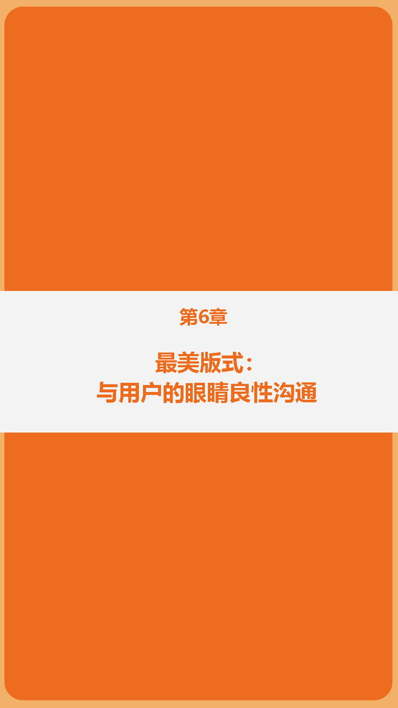

如果说内容是与用户的心灵沟通，那么版式就是与用户的眼睛沟通。版式设计就是公众号的“脸面”，用户了解内容的第一步还是颜值。不要考验用户的忠诚度，没人愿意跟自己的美感较劲，设计个漂亮的版式，至少不会有什么坏处。

## 排版为何如此重要

现在的公众号五花八门，推送的内容也千姿百态，千变万化的版式更是各有千秋。一篇文章的版式就相当于公众号的脸面，因此作为公众号的创作人员，要时刻注意版式技巧的更替迭代。毫不夸张地说，排版关系着公众号赖以生存的用户体验以及定位气质，所以必须要引起足够的重视。

### 提升阅读体验

所谓把用户服务做到极致，就是内容不仅要有价值，还要让用户看得舒服。提升阅读体验能带来两个好处：一是文章变得段落清晰、整洁有序、逻辑感强，让用户更容易发现重点，进而提升阅读效率。二是好的排版能在整个视觉效果上，给用户带来美的感受和体验。

### 给用户内容精良的心理暗示

用户通常会觉得，一个排版非常有品位的公众号，内容一定不会差，所以好的排版永远都能成为公众号的加分项。像看到“一条”、“深夜发媸”、“拾遗”（如图6–1所示）、“樱桃画报”这样的账号，很多人的第一反应可能就是：这个号太精致、太漂亮了！如此有品位的公众号，内容一定不会差。

[figure not shown]

图6–1 “拾遗”文章排版

### 提高文章读完率

阅读量表现的仅仅是打开率，并不代表读完率。可能1万个点击量的背后，只有两三千人读完了你的文章。一个不能否认的事实就是，大部分用户点开一篇文章，往往只是随便看一下就离开了。所以我们用尽各种排版技巧，配图、文字加粗、文字加颜色、留白、合理的分段等手段，很大程度上就是试图让尽可能多的点开文章的用户读完这篇文章。

### 辅助塑造品牌

你的内容风格、账号品牌和你在用户心中的形象是在一次一次的推送中，通过高标准且风格稳定的排版形成的。你每一篇内容的视觉呈现和排版，无时无刻不在影响着用户对你品牌的认知。

在我们了解完排版的重要性后，下面让我们来学习一下排版的4个原则，也就是我们在日后工作中的基本逻辑。

**@风格固定原则** 我们提供的内容对用户来说，其实就是一款产品或者是一项服务。而无论产品还是服务都必须满足一点，那就是质量和形式的稳定性。比如加多宝凉茶的罐装外观，必须要长时间保持一致，而不是每个月换一次包装。可口可乐经常在包装上有微创新，比如推出歌词瓶。但是在整体上，它的瓶装外观却是很多年都不变的。

现在我们经常看到一些公众号的排版，10篇文章出现了10种排版方式，每一次都不一样，非常不稳定。这样的文章是无法称为产品的，用户的体验和预期也会变得非常差。所以，我们一定要设计出一个优质的排版方式，并且稳定地用下去，不要经常换，就像“咪蒙”“夜听”那样。

**@简约美观原则** 我们一定不要为了排版而排版，在使用排版工具的时候一定要克制，不要太花哨，也不要太复杂。在排版时，心里一定要记住的是：内容本身才是关键，而排版是一种辅助工作，不要本末倒置。排版是为了提升阅读体验，但过于复杂的排版反而降低了阅读体验，违背了工作的初衷。

**@结构清晰原则** 排版也并不是一道必需的工序，如果一篇文章只有3句话，那就大可不必费神了。排版是把长篇的复杂文章简单化、模块化、结构化的一个过程，让文章呈现更有逻辑、更清晰。同时，也是为了让用户更容易接受、更高效地阅读，这是我们一定要明确的一点。结构清晰的另一点就是整体性，比如内容中谁和谁是一个整体，这些在排版呈现上也要体现出来。

**@重点突出原则** 呈现内容的时候一定要有优先级思维，因为我们无法确保用户能够从头到尾每一句话都阅读。所以，我们要去突出表现那些更为重要、更希望用户注意到的内容。比如小标题、开头、结尾、重点字词句、重点图片、视频等内容，我们都要想办法通过排版，让这些内容更为突出。

排版显示的就是公众号的外在形象，就像是我们的衣服一般。但是，这也是一项有风险的工作。好的排版，自然可以为我们的文章增光添彩，让公众号更加深入人心。而劣质的排版，也可能毁掉文章的优质内容。所以在接下来的篇幅中，我会为大家详细地介绍排版的技巧，以及注意事项。

## 用封面图提高打开率

一个公众号是否受欢迎，从公众号的打开率和转发率上可以看出端倪。文章的打开率跟标题、头像、摘要文字等多种因素有关，其中封面图的重要性不容小觑。如今，很多公众号创作人员在做封面图时，都会在网络上随便找几张看着漂亮的图片，从中进行挑选。但事实上，封面图的选取并非想象中那么容易。封面图可以在第一时间传达文章的中心信息，体现公众号的气质格调。一张好的封面图片能够传达的信息，甚至用几百字都不足以表达。因此才会有“一张好图胜过千言万语”的说法。

所以，在如今公众号的打开率越来越低之际，我们千万不能浪费掉封面图这个资源。对此，我总结出了关于封面配图的技巧。

### 优先选择含人物元素的照片，优先选择名人照片

在没有特殊要求的情况下，我们要尽量用人物形象或包含人物形象的图片，而不是物品照片、建筑物图片、自然风景图片、抽象设计图片等。因为人是一种高级动物，情感最丰富、细腻，表达也最准确、具体。爱恨情仇、喜怒哀乐、赞成或反对、热情或冷漠、伟大或渺小等，都通过人物形象来表现出来。而这一特点显然不是建筑图片或者风景图片所能具备的。配图的大忌就是，你自认为这张图片可以表达出你的情感、你的信息，但用户却并不能感受到。

为此我特意去观察了“咪蒙”的封面图，发现“咪蒙”的封面图虽然全是插画师给她做的，理论上画什么都可以（如图6–2所示）。但实际上，“咪蒙”采用的大多数图片也以人物为主。大家如果注意观察“罗辑思维”的封面图的话，就会发现同样如此，几乎都是含人物形象的照片。

[figure not shown]

图6–2 “咪蒙”文章封面图

其实，人物的配图并非只能用在写人物的文章中，转换下思路，其实大部分的文章都可以运用此技巧。比如我要写阿里巴巴，就可以用马云的图片；我写微信就可以用张小龙的图片；我写富二代主题的文章就可以直接上王思聪的图片。甚至，如果我要写摩拜单车，也可以用一个帅哥或美女骑摩拜的照片，而不是用一张摩拜单车停在路边的图。另外，名人永远是最能够吸引人们眼球的点，所以能用名人的照片就尽量不用其他的。

### 用具体场景照片，增加现场感和代入感

场景化的照片相当于向用户描述了一个故事画面，增加代入感，进而产生共鸣感。像新闻、热点类的文章，就会常常使用现场的具体场景照片，在增加现场感的同时，也增加了时效性和紧迫感，对提高点击量有很大的帮助。比如：

《OPPO副总裁最新演讲：比努力更重要的，是永远“年轻”》这篇文章就是用的OPPO副总裁、人力资源与战略部总裁蒋安奕在浙江大学演讲时的具体场景照片，非常有新闻的现场感（如图6-3所示）。

[figure not shown]

图6–3 《OPPO副总裁最新演讲：比努力更重要的，是永远“年轻”》封面图

### 封面图和标题要强相关，两者互为辅助

在表达主题、表达对象、表达感情或观点上，封面图和标题一定要有很强的相关性甚至是一致性。并且，这种相关性应该是非常直接的，而不是需要用户动脑子才能想象出来。很多编辑配封面图的时候，经常会用两者关系不大的照片，这样无疑会在很大程度上降低文章的打开率。比如：

“丁香医生”的《据说，91%的人都会抠鼻屎，而剩下9%的人……》封面图用的就是一张抠鼻屎的照片，而且这张图片是从影视剧中截选的，大家都非常熟悉，增加了戏剧性和幽默感（如图6–4所示）。

[figure not shown]

图6–4 《据说，91%的人都会抠鼻屎，而剩下9%的人……》封面图

“创业邦”的《警察出动维持秩序！他的超市开业1小时后被迫关店停业，只因太火爆！》这篇文章是写的河南的一个传奇超市胖东来，为了搭配标题，“创业邦”直接选用了开业当天，超市外面顾客挨挨挤挤的超级火爆照片（如图6–5所示）。

[figure not shown]

图6–5 《警察出动维持秩序！他的超市开业1小时后被迫关店停业，只因太火爆！》封面图

### 照片必须能传递情绪、烘托气氛

无论选择什么类型的照片，都应该做到这一点，这也是最根本的一点。要让图片自己说话，所有你想表达的观点、态度、情感、情绪等，都要让用户看到这张图片的一瞬间就感受到。

比如题目是《〈我不是药神〉：买不起房痛，上不了学痛，但更痛的是生不起病》，我们该如何选择封面图呢？电影剧照实在太多了，最后我选择的是主演徐峥饰演的“勇哥”面对众多白血病人时的照片作为封面图，让用户一下就能感受到戏里戏外的沉痛与悲伤（如图6–6所示）。

[figure not shown]

图6–6 《我不是药神》剧照

再比如，题目是《你毕业几年了，混成啥鬼样子了？看看这些年轻人怎么说》封面图配的是一位受访女性掩面哭泣的照片，并标注着“梦想现实”的字样，一下子就让用户感受到了在大城市打拼的年轻人的辛酸（如图6–7所示）。

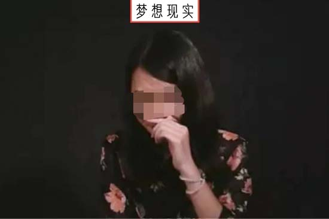

图6–7 《你毕业几年了，混成啥鬼样子了？看看这些年轻人怎么说》封面图

除了选用封面图的技巧之外，我们还需要了解4个方面的注意事项。

**@尽量用大众熟悉的** 因为人天然会亲近自己熟悉的事物，而对陌生的事物有抵触心理。所以我们在做内容的过程中也要记住这个原则：用熟悉的东西去包装陌生的内容，否则直接向用户传达陌生的东西，用户会有排斥心理。

**@视觉焦点一定要在图的正中** 想要让封面图和标题搭配提高点击的效果，在朋友圈有效传播，我们就要保证照片中的核心元素在分享到朋友圈之后，依然是清晰可见的。所以我们要养成一个习惯，在正式推送前试发朋友圈检验封面图的效果。

**@尽量多用颜色更深、更亮的图片** 从视觉传播角度来说，人更容易被色彩艳丽的东西所吸引。因此，尽量不要选用白色和灰色占比太多的图片，因为这样的图片会让用户看起来没有欲望，除非你的公众号已经形成了这样的格调。

**@注意题目和封面图的排版** 我们要通过排版避免让图片的亮点被标题遮挡住，让用户看不到或者看不清。

## 如何让内容配图更抢眼

目前内容的呈现形式主要是文字、图片、音频、视频、直播以及它们的各种组合。就单体形式来看，文字的生产门槛最低，因此产量也最大，但是这种呈现形式对用户来说刺激感相对较弱。视频是当下年轻人最喜欢的形式之一，刺激感最强，但生产门槛、生产成本都比较高。而音频的表现形式受限较大。直播还无法直接在公众号中完成。所以，图片是当下对于公众号来说非常好的一种内容形式，生产成本没有那么高，表现力非常强，又深受用户喜欢。

**@图片要保证有用** 有用是配图的第一原则，不要为了配图而配图。而判断一张图是否有用，我们可以采取删除法。也就是说如果你将图片去掉，会感觉表达不完整，就说明这张图有用，反之则无用。有用也有很多层面，增加趣味性是有用，增加事实材料是有用，加强文字的表现效果也是有用。比如“Sir电影”“一席”这样的账号，就会大量地使用配图，而且每张图都是有用的。

**@图片要有感染力** 图片有感染力也就是要用能自己说话的图片，要让图片能自带情绪。一张好的图片能表达不同程度的喜怒哀乐，能渲染一种气氛，还能帮你展现一个态度，抑或替你表达一种观点。比如“樱桃画报”“脑洞运营”（如图6–8所示）这样的账号，每一张图片都是精心挑选的，和文字巧妙搭配起来，让人拍案叫绝。

[figure not shown]

图6–8 “脑洞运营”文章配图

### 图片要保证颜值

图片的颜值是一个审美问题，无法传授，但可以培养。方法也很简单，只需要我们每天去看美的东西，多去看颜值特别高的账号、杂志、图片、视频、电影等。当然还有一些最基本的要求，比如图片的清晰度、表达的内容等。比如“拾遗”、“日食记”（如图6–9所示）、“一条”的图片都是高颜值高标准。

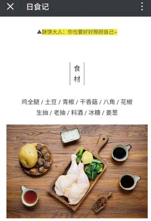

图6–9 “日食记”精美配图

### 配图位置要合理

首先，配图不能破坏阅读体验，不能破坏文字的连贯性和逻辑性。如果用户看完这段话需要马上看下一段，我们就不能在两段中间插入图片，除非这张图片能让两段的衔接更完美。其次，配图要尽可能均匀分布在整篇文章中。不要时而密集，时而稀疏。

### 尝试多使用动图

从视觉效果上来说，动图更能抓住用户眼球。从信息量和表达效果上来说，动图也是更胜一筹。比如“日食记”是一个美食类账号，它用动图来呈现美食看起来更加诱人，更有表现力。再比如“Sir电影”这个账号在解读电影时，也都是直接从电影中提取动图，让用户更能有共鸣。

### 配图要遵循三个统一

**@主色调统一** 保证视觉体验的连贯性与整体色调的协调性，提升观感。

**@风格统一** 避免多种画风的出现。比如“脑洞运营”不管是文章的封面图还是主体内容中的配图，都是统一的暴走漫画风格（如图6–10所示）。

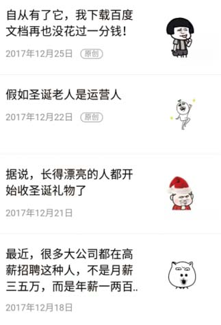

图6–10 “脑洞运营”文章封面图

**@图片宽度统一** 图片的长度可以不统一，但宽度要统一。注意，这里说的宽度统一并不是指实际宽度一致，而是指显示效果。比如“樱桃画报”的配图，尺寸都是统一的标准，所以整体上看着非常干净。

## 头图的“第一屏体验”

对于公众号文章来说，除了封面图和文章配图，还有一种特殊的图片，称为头图。顾名思义，头图也就是点开标题后文章开头的那张图。为此，我创造了一个词，叫“第一屏体验”，指的是用户不管是在朋友圈、微信群，还是公众号会话里被文章标题吸引之后，点开后看到第一屏内容时的体验。

我们之前提到过，点击率并不代表阅读率。但是只要是点击文章的用户，都会看到头图，单单这一点就足以显现出头图的重要性了。我总结了头图的4个使用技巧。

### 头图和标题关联度要足够高

用户首先看到的是文章的题目，题目的信息会激发用户的某种思考或情绪，且形成一定的预期。所以当用户点击进来的时候，我们要通过头图加强或者延续标题中表达的东西。如果是一张不相干的图片，则会让用户的情绪中断，预期减弱，注意力转移。

所以头图和题目关联度要高，表达要直接，不要让用户花时间研究照片象征了什么，寓意是什么。

“插坐学院”的《我最怕30岁以后，还要去招聘会找工作》，点进来之后的头图就是一个30岁左右的职场女性匆匆跑去面试的场景（如图6–11所示）。

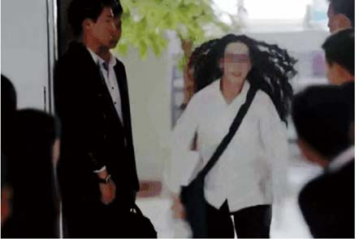

图6–11 《我最怕30岁以后，还要去招聘会找工作》头图

“浪潮工作室”的《第一批90后已经秃了》，点进来之后的头图就是一个秃顶男人的头（如图6–12所示）。

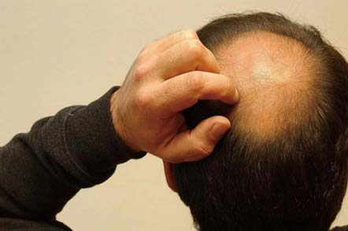

图6–12 《第一批90后已经秃了》头图

“粥左罗”的《小米上市！雷军：我给有梦想的年轻人这5点建议（附雷军现场视频）》，点进来之后的头图就是小米上市当天各位重要人物的合影（如图6–13所示）。

[figure not shown]

图6–13 《小米上市！雷军：我给有梦想的年轻人这5点建议（附雷军现场视频）》头图

### 尽量选择最有爆点的图片

图片的爆点指的是，这张图片有一些特别吸引眼球的元素。这些元素可能是名人明星，可能是图片中展现的场景非常少见，也可能是图片中展示的东西颠覆了大众的常识性认知，或者图片非常有话题性、争议性等等。比如：

“GQ实验室”的《冯唐的公开信|如何避免成为一个直男癌患者？》点开之后的头图是一张视觉冲击力非常强的裸男的背身图片（如图6–14所示）。

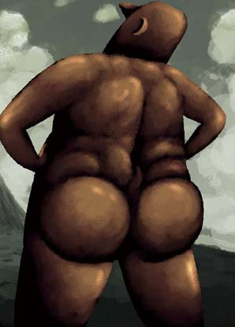

图6–14 《冯唐的公开信l如何避免成为一个直男癌患者？》头图

“花儿街参考”的《你愿意接受罗敏的捐助上学吗？上了大学还有校园贷等着你》点开之后的头图上展示的是一个受了委屈的女性，然后你会立马被图片上那句话吸引：“人生说到底就是场互相争夺金钱的战争（如图6–15所示）。”

[figure not shown]

图6–15 《你愿意接受罗敏的捐助上学吗？上了大学还有校园贷等着你》头图

### 设计一张重复使用的品牌概念图

品牌概念图也是我创造的一个词语，指的就是精心设计一张能塑造品牌的图片，并且在每篇文章的开头都重复使用这一张图，形成一个固定的形式，通过对用户日复一日的视觉冲击来强化账号品牌，这也是目前很多账号都在使用的方法。

比如“差评”“十点课堂”“清单”“赵圆圆”“看理想”“一句心情签名”等皆是如此。

### 做一个持续塑造品牌的头图模板

这个技巧指的就是，虽然我们每次都根据文章的内容选择一张图片，但我们可以用同一个模板。比如设计一个品牌元素，加在每篇文章的头图上，这也是一个增强品牌印记的好办法。比如：“新世相”在每张头图的顶部中间加上白底黑字“新世相”。头图下面写一个：这是新世相的第×××篇文章（如图6–16所示）。

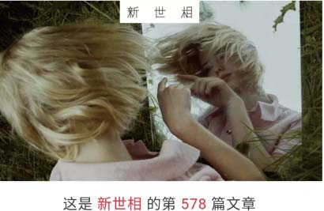

图6–16 “新世相”头图

“开始吧”把每张头图的左边1/3设计成留白，在留白处写上账号slogan：这就是你报复平庸的方式（如图6–17所示）。

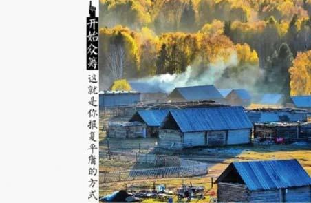

图6–17 “开始吧”头图

## 文字排版要讲究，不要将就

在大部分公众号文章中，传达基本信息的载体是文字。用户打开文章，如果感觉字数太多，会产生放弃阅读的想法；相反，如果感觉字数不多，可能就会继续读下去。因此怎样对文章的文字呈现进行视觉设计，使用户“感觉”字数不多便成为文字编辑工作中最重要的工作。通过巧妙的文字排版，可以让用户淡化对文章字数的印象，而沿着文章的整体思路进行阅读。以下是文字排版的6大技巧，希望能对读者朋友们有帮助。

### 内容模块化

在碎片化阅读时代，一篇几千字的长文会给用户很大的阅读压力，即使用户愿意读，也会非常疲惫。所以，我们可以尝试将每一篇长文分成四五个以上模块，每一个模块就是一个部分，尽可能多地提炼小标题。

如果没有小标题，你可以将文章分成四五个模块之后，用一定的格式标出一二三四。这样就相当于将一个2000多字的文章，分成了四五个五六百字的小内容模块，给用户一个喘息的机会，阅读体验会提高很多。

### 段落标准化

分段不合理是新手编辑最容易犯的一个排版错误。我们在调查了大量优秀的公众号后总结出，一段不超过5行，会有比较好的阅读体验，三四行一段是比较舒服的，一段文字最好不要超过8行。因为如果我们使用14至16号的字体，在5英寸（12.7厘米）左右的手机上，一次大概能显示20行左右。所以一个屏显示三四段文字，再加上留白，用户会感觉比较舒服。如果一篇文章一段超过10行，就会给用户很大的心理压力。比如“罗辑思维”的清单体文章，基本上都是一段文字控制在5行以内。

### 字体字号规范

**@字体** 最好用公众号后台的默认字体，不要自作聪明。因为用户长期在公众号上阅读，已经形成了习惯，所以我们不要随意去打破这个习惯。

**@字号** 不要违反人性，12号字过小，会让用户的眼睛感到非常疲惫。而18号或20号字又太大了，除非你的文章定位是60岁以上的人群。做服务永远要考虑大众需求，取最大公约数，千万不要自以为是，把自己的小众偏好当成大众需求。

所以，字号大小讲究的是普遍适用原则，也就是要照顾80%用户的习惯，而不是去讨好20%的用户。大概的规范就是正文用14至16号字体，小标题用16至18号字体，注释性文字用12至14号字体。并且，不要使用斜体（如图6–18所示）。

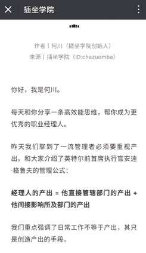

图6–18 “插坐学院”文章字体、字号

### 文字配色规范

配色，我们遵循的是简约美观的原则。一篇文章中配色最好不要超过3种，常见又舒服的方式就是：黑色+灰色+品牌色。也就是说，正文用黑色，注释性的文字用灰色，然后再选取一个亮眼的彩色作为突出重点的颜色。最后将这个彩色固定下来，不要频繁更换。

**@重点突出技巧** 不要让用户自己提炼要点，也不要让用户自己画重点。公众号每天产生几百万篇文章，用户愿意点开这篇文章已经是万幸了，我们要替用户完成画重点的工作。文章中的重点内容（字、词、句）、小标题、模块的序号等需要重点展示给用户，所以要使用一定的排版技巧使其更突出更显眼，让用户优先注意到。一方面这是不断吸引用户读完的手段，另一方面这也是提高用户阅读效率的技巧，让用户更快地找到重点。

常见的标重点的方式有：

·需要重点突出的单独列出。

·标注特殊颜色（品牌色）。

·字体加粗、字号加大。

·使用特殊排版格式。

### 摘要排版

摘要也需要注意。有很多新媒体编辑不注意自己去写摘要，因为摘要是选填项目，如果你自己不写，系统就会默认自动抓取前54个字。但是尤其在文章头条单推的时候，这样的排版就显得太简陋、太寒酸了。所以我们一定要自己写摘要，并且尽量保持在10个字以内，不要超过15个字，这样的话整个排版就会显得更加美观、整洁。

### 标题排版

标题的排版主要需要注意字数和标点符号这两个方面。

**@字数** 现在的公众号流行长标题，编辑们总是希望能够在标题中呈现更多的信息量。虽然这种想法是好事，但是标题的长度还是要有所限制，尽量不要超过32个字，27个字以内相对较好。如果标题太长，用户可能无法一眼看懂，在碎片化阅读环境下，大家没有耐心去看完那些四五十字的标题。况且，你的标题一旦超过40个字，在排版上的体验也会变得很差。

**@标点符号** 另一个要注意的就是标题中标点符号的用法，还是要遵循大众的阅读习惯，基本上使用逗号、顿号、句号、问号、引号等大家平时用的形式。尽量不去使用那些陌生的、不常见的符号。因为这会让用户产生不好的阅读体验。最后要记住，我们做的既是产品，也是服务，要以用户的体验为主，而不是故作文艺。

## 用小标题为文章加分

现在的很多公众号文章中并没有小标题。我并不认为是编辑的懒惰，而是因为他们还没有意识到小标题的重要性。所以，我首先要为大家解释一下小标题到底为什么重要。

### 增强文章逻辑，表达条理分明

曾经有个做新媒体的朋友，说过这样一个观点：社交媒体时代，文章的逻辑已经不重要了。在碎片化阅读时代，只需要写一些段子，再配上图，表达一些极端、有共鸣的观点，用户就非常喜欢看。

有这样想法的新媒体人并不在少数，但这是一个误区。我认为越是在碎片化时代，就越需要逻辑，逻辑的含义里有几个关键词：序列、流动、顺序、过程。以我个人的理解，很简单：逻辑是一种力量，它可以一环扣一环地推动用户往下阅读。

想要加强文章的逻辑，最好的办法就是增加小标题。很多编辑在定好选题后，马上就动笔开写，导致文章逻辑混乱。因为他在写之前没有定结构、框架、逻辑，说具体点就是没有列小标题。当然我们在写之前可以将小标题列得粗糙一些，写完之后再调整润色，但不能不写。

你的小标题提炼好之后，文章的逻辑感肯定会增强，表达上也会更加条理分明，更加流畅，用户读起来更觉环环相扣，体验自然变得更好（如图6–19所示）。

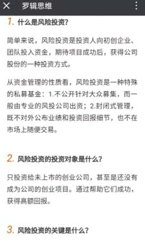

图6–19 “罗辑思维”文章小标题

### 抓人眼球，提高文章读完率

小标题就是在文章中提炼出来的精华，语言简洁、有力、抓人眼球，可以吸引用户继续阅读。大家可以回忆一下自己的阅读经历，当我们点开一篇文章的时候，多数是带着“看一眼”的心态，而并不是带着很强的阅读预期。所以在很多时候，我们点开之后做的动作并不是从头开始读，而是先很快地滑动屏幕，看一下小标题，如果小标题足够吸引人，我们才可能继续阅读这篇文章。就这样，在阅读的过程中，我们会不停地被下一个小标题吸引，导致我们继续看下去。如果没有这些抓眼球的小标题，我们很可能在中途就放弃了。

### 帮助用户理解文章内容

我们经常会遇到一种情况，就是文章刚刚推送还不到一分钟，就已经有用户在下面留言、评论了。并且，我们可以感觉到，他是认真读过文章后写的留言，这是为什么？其实，他并不是一分钟就读完了文章，而是因为文章的小标题起得足够好，他扫一眼开头结尾和小标题就完全明白了文章内容。即便用户会通篇读完你的文章，小标题也可以辅助他理解整个文章。因为小标题都是根据内容提炼出来的，是内容的精简版、浓缩版。能够帮用户节省时间是一件好事。

### 控制阅读节奏，减轻用户压力

《纽约时报》调查了2500个用户后发现，长文章更容易被分享，因为长文信息量大、内容有厚度。但这里又有一个矛盾：碎片化时代用户的注意力非常容易分散，看长文是一件压力很大的事情。当我在上班路上的地铁中打开一篇文章，发现洋洋洒洒几千字的时候，我可能会直接退出。但是如果这篇文章结构非常清晰，分成了几大块，并且每一块都有一个非常吸引我的小标题的话，长文的压力可能就会消失，让我有了阅读的欲望。

这个时候，我们相当于用了五六个小标题将文章分成了五六个模块，这就是在设计用户的阅读节奏，让他在每个小标题结束时能够有一个喘息和停下来思考的机会。

以下是我总结的设置小标题的5个技巧。

**@多提炼小标题** 所谓的多是相对的，并不是越多越好。如果非要给出一个长度的建议，我建议两个小标题之间不超过2屏，大概就是正常手握5英寸左右的手机，然后拇指滑动屏幕，用户每滑动三四下就会看到下一个小标题，尽量不要超过5下。当然，这并不包括图片特别多的文章。

这是我根据长时间的实践摸索出来的一个模糊的标准。也许大家会认为这样的标准很苛刻、古板，但经验不会骗人，这样的标准是让用户最为舒适的。

**@设置多级小标题** 提炼小标题，也可以通过设置多级小标题来实现，即给文章设置一级标题、二级标题、三级标题，以达到提高用户阅读体验的目的。如果设置多级标题，那么上面所讲的两个小标题之间尽量不超过2屏长度的标准就不用遵循了，因为你下面还有二级、三级标题（如图6–20所示）。

比如涉及一件事的原因、经过、方法、结果、影响等这种类型的描述，都可以梳理出个一二三，设置上小标题。

**@小标题要长短适中** 传统媒体写小标题的时候，喜欢用非常短的，甚至是一个字来表达，比如“春、夏、秋、冬”。虽然一个字的小标题，看起来很高端且有深度。但其实社交媒体上的文章不用太强求简洁凝练，能把事情说清楚、能帮助用户理解内容、吸引眼球才是第一需求。长度上的大概标准是：在5英寸左右手机上用14至16号字不超两行，一旦超过两行就显得太冗长了。

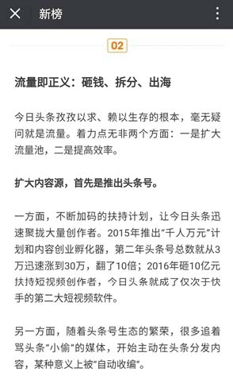

图6–20 “新榜”多级标题

**@小标题排版要吸引眼球** 小标题能够吸引眼球，除了语言文字本身，想要在视觉呈现上吸引眼球，就要在排版上下功夫。比如给小标题加粗、加大字号、标上品牌色、居中、加上更吸引人眼球的排版格式等。

**@小标题之间要有逻辑** 小标题的逻辑是一件非常重要的事情，而想要验证也十分简单。我们写完文章，并且将小标题都提炼好调整好后，只需要将小标题全部拿出来，按顺序排列起来，再从上往下读一遍自然就明了了。如果没有逻辑，就要继续优化。

以上就是设置小标题的4个必要性和5个技巧。相比5个技巧，我觉得大家更应该深刻理解4个必要性。因为当你真正感受到小标题的强大作用时，你自然而然地就会去主动琢磨小标题应该如何设置，而总结出来的经验，可能会比学习而来的技巧更加强大。

## 留白：让你的内容呈现更生动

合理的留白可以让内容更生动，更具呼吸感，减轻用户的阅读压力，提升用户的阅读体验。同时，合理的留白本身能让内容在呈现上条理清晰、重点突出、张弛有度、更有美感。基于以上原理，我给大家总结了新媒体时代的文章留白法则，即文章排版中的9个留白技巧。

### 段首不要留白

段首的留白技巧就是不要留白，现在很多编辑在排版时，还保留着传统媒体中段首空两格的习惯。但是在新媒体时代却不必这样做了，因为手机的屏幕本就相对窄小。你如果还要在每一段的段首再空两格的话，整篇文章在手机屏幕中所呈现出来的效果就会变得很差。而且传统媒体的段首空格主要是为了区分段落，而新媒体时代却不需要用它来区分（如图6–21所示）。

[figure not shown]

图6–21 “咪蒙”文章排版时的留白

### 字与字之间使用系统默认

虽然在公众号后台可以调整字间距，但是我不建议去加大正常段落中的文字字间距，还是用系统默认的为好。这种手段只有在特殊情况下可以使用，比如想要突出小标题，可以在排小标题的时候加大字间距。

### 不改变行间距

正常的段落，我也是推荐大家直接使用系统默认的行间距。如果有些重点的短句子需要更突出一些，可以适当增加行间距，让这部分内容更有辨识度。另外，行间距在公众号后台也可以直接调整。

### 段与段留一行

段与段之间建议空出一行的距离。如果不留白，就会变得满屏幕都是字，增加用户的阅读压力，而且无法区分不同段落。如果想要加大留白，最多不要超过1.75倍行间距。因为如果留白太宽，用户眼球移动的体验就会变差。

### 文章两侧适当留白

比如“咪蒙”“插坐学院”等账号，主体内容的两侧都有留白。因为两侧留白，一方面可以从视觉呈现上减轻用户的阅读压力，另一方面也可以提高用户的阅读效率。但是还是不要留白太多，通过我对一些优质账号的研究分析，我认为两端各留白0.5至1个字符比较好，尽量不要超过2个字符。

### 小标题加大留白

整体上，小标题上下的留白一般要大于段与段之间的留白，这是为了让小标题更加突出一些。但是要注意的是，小标题与下面内容的留白，要小于小标题与上面内容的留白。这是整体性原则，要让小标题与下面的内容成为一个整体。最后，小标题的排版最好是居中式的，因为这样更符合用户的阅读体验。

### 配图与文字的3种留白

**@图片与图片说明之间不要留白** 在逻辑上，图片与图片说明是一个整体，没有留白看起来更和谐，另外图片说明一般居中、两侧留白，这样更美观。

**@配图和正文之间要有留白** 配图和正文的整体性没有那么强，合理留白看起来更美观。

**@图片较多时的留白技巧** 连续多图片，且每张图片都有文字说明时，文字说明一定要更靠近相应的图片。如果文字说明跟上下图片的留白一样大小时，用户就可能产生混乱，搞不清楚文字说明到底是针对上面图片的，还是针对下面图片的。

### 整体两端对齐

因为手机的屏幕相对较窄，很多时候我们会发现，文章在后台排版的时候，段落都比较整齐。但是当推送出去在手机上浏览的时候，行与行之间就会变得参差不齐。你要记住，在后台排版的时候一定要使用两端对齐的格式，这样不管多大的手机屏幕，文章在展示出来时，段落都比较整齐。

### 其他留白

·当出现数字、英文单词、字母时，前后要空一格留白。

·英文排版时，逗号、句号之后都要加一个空格留白。

·摄氏度、度量单位、百分号等，前面不加空格。

·货币标志、正负数符号后不加空格。

·数字与日期之间不需要空格。

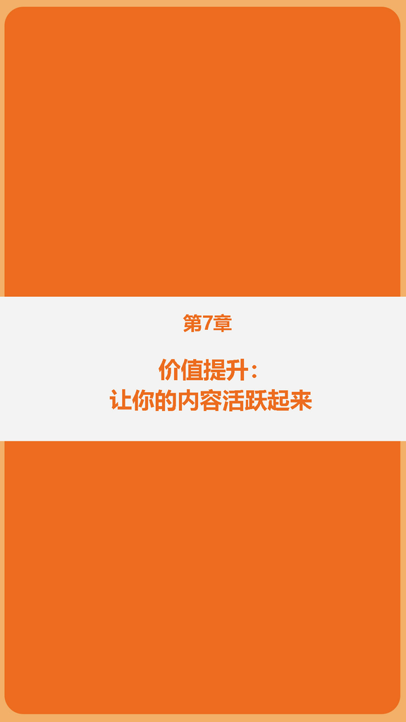

相比于传统媒体，公众号是一个相对新鲜也相对神秘的领域。不仅内容需要精心打磨，排版需要精心策划，还有很多新奇的功能和细节等着我们去发现和学习。这些平时被我们轻视甚至忽视的细节，都可以帮助我们提升公众账号的价值，为用户提供更好的阅读体验。

## 将公众号人格化

在互联网交流越来越趋于扁平化的当下，用户对微信公众号的使用需求也开始更加趋于人性化。在很多用户看来，公众号不应当只是一个冰冷的沟通工具，而应当是一个有血有肉的“人”。人格化的公众号能使用户感觉自己不是身处在一个虚无缥缈的网络环境，而是面对一个有温度的、有情感的、活生生的人。

我认为，人格化运营公众号的好处有很多。

### 商业变现更容易

大多数人在消费的时候，最重要的参考意见其实来自朋友。一旦自己信任的人推荐，大多数用户都会放心购买。人格化的新媒体更容易变现，因为用户已经把你这个号当成了自己的朋友。

另外，由于中产阶层的崛起，大家已经变得富足了许多。但是，很多人却并不知道要买些什么。所以，就只能跟着他信任的人购物，这也是现如今大量的博主、号主、网红做电商做得风生水起的一个重要原因。

### 更好的阅读体验

人格化的内容，在表达上更直接，更容易拉近用户距离。语言也更有温度、更有性格、更有意思，这样的内容更容易让用户有代入感，阅读体验会更好。

### 增加关注

想要用户喜欢上一个平台可能需要很久，但喜欢上一个人可能只需要5分钟。所以，用户对人的认可在一定程度上可能要大于对内容的认可。

### 增加辨识度

如今是一个全媒体时代，单公众号的数量就已经达到了千万级。这就导致了内容同质化的现象非常严重，人格化的语言可以让你的公众号和其他公众号、其他的内容区分开来，让用户记住你。

在了解完公众号人格化的好处后，下面我为大家介绍在实际运营中的4种技巧。

**@起一个好昵称** 好的昵称是公众号人格化运营的第一步，我们要给这个人格化形象取一个好听、接地气又符合账号格调的名字。比如“少女兔”的“兔姐”、“Sir电影”的“毒Sir”、“独立鱼电影”的“鱼叔”、“年糕妈妈”的“糕妈”、“商务范”的“范主”、“新世相”的“世相君”、“有束光”的“司马”等。取完名字后，如果条件允许，甚至可以让设计师为它设计出一个IP形象。

**@进行人格设定** 光有昵称肯定是不够的，我们还要根据自己公众号的人格化形象做一个性格设定，它的性别是什么，年龄在哪个阶段，说话是怎样的风格，有着怎样的好恶，等等。当我们将这些详细的信息都添加到自己的账号中后，这个账号也就拥有了自己的人格和调性。

比如“Sir电影”的“毒sir”，他的人格化形象就是：热血影痴男青年，阅片量大、幽默风趣且不失专业，喜欢用调侃戏谑的方式表达观点、做影评时敢说真话，毫不避讳，既耿直又“毒舌”。

**@内容上进行人格化表达** 人格化表达首先应该是“说人话”，呈现的内容风格要像和朋友聊天那样。比如“独立鱼电影”的推文《靳东的前半生与后半生》中，“鱼叔”一词就出现了4次，而且每一次都是带着鲜明的人格化表达的属性。

做好人格化，就要在写每一段话、每一句话，甚至是用每一个词的时候，都想象成你的对面就坐着一个自己的朋友，而我们笔下的内容就是要对他说的话。

**@运营上进行人格化互动** 很多公众号都像一台高冷的机器，用户在后台与它对话时，有的公众号不予回复，而有的公众号是自动回复，评论区的留言也基本看不到回复，这就是典型的非人格化。

建议大家多回复后台消息，评论区有时间的话也尽可能多回复，而且回复的时候不要当成例行公事，要尽量展现自己的风格。

公众号“脑洞运营”的评论区互动就非常精彩，在推文《如何用公众号大V的方式说“我辞职了”》的评论区中，用户郭婉君留言：“自己选的工作，想辞就辞。”作者回复：“写这句话时在公放梁静茹的《勇气》？”用户倩毛留言：“大V辞职我能顶上不？哦不，现在还是白天，不能做梦。”作者回复：“灯光师给我往这里照，我看看是谁这么好意思。”

大家在进行公众号人格化运营时要时刻记住，人是可以交流的，而交流是双向的。用户的每一次说话、每一次留言，都要尽可能回复。在大部分账号都不回复的时候，你给用户的每一次回复，都有机会让他感动，时间久了，他就会把你当成自己的朋友。

## 重复利用历史文章

如今，大部分公众号更新的频率都比较高，甚至有一部分达到了日更。而这些公众号的每次推送都将上一次的推送盖住。日复一日，那些比较靠前的内容基本上都被埋没了，即使价值再高，也鲜有用户会再去翻看、挖掘。而且公众号相对于其他内容平台，内容质量确实比较高。每天推送这么高质量的内容，但却由于内容推送、呈现机制的原因，只能在很短的时间内产生价值，显然是一种资源的极大浪费，非常不划算。

基于这样一个底层逻辑，我开始思考如何让这些优质的内容能发挥长期的价值，并总结出了以下6种方法。

### 价值恒定，重新发布

价值恒定也就是你文章的价值要经得起时间的考验。一篇文章在今天看有价值，一个月后，甚至一年后，这些内容对用户依然有价值，这就叫价值恒定。如果有这样的文章，我们就可以多次拿出来推送给用户。

这样的文章有很多，比如像《雷军：不要拿战术上的勤奋来掩盖战略上的懒惰》《为什么说绝大多数人都是“低品质”的勤奋者？》《任正非：员工要做好本职工作，不要把精力放在构思“宏伟蓝图”上》……这些文章在一年、两年甚至五年、十年后都不会过时，每隔一段时间你就能拿出来重新发布。

各领域的一些干货、科普、人物、故事、鸡汤、观点类的文章都可以定期拿出来重新发布。你可以选一个周末，在空闲的时候，将自己账号上推送过的文章，重新翻看一遍，然后将可以重新推送的文章全部罗列出来。这样就可以在后期运营中，有技巧有策略有节奏地重新发布。

### 借势热点，整合利用

这个是最常用，也最值得用的一个技巧。也就是每次当热点事件发生后，你就要迅速思考，自己之前发布过的文章，有没有可能在追热点的时候当作素材来用。

比如我之前写过一篇文章《30岁丧夫，36岁南下打工，放弃8000万年薪，董明珠为格力耗尽一生，图的啥？》，这篇文章是我写董明珠的一个人物稿件，写这篇稿子的时候搜集了非常多的资料，全面而细致地呈现了董明珠的人物形象。

有了这篇稿子之后，今后董明珠一出热点，我就可以拿出来再整合利用。比如后来我又写了《重磅！董明珠被免去格力集团董事长职务！62岁的铁娘子遭遇了什么？》《董明珠又火了！给7万员工加薪1000元！快过年了，你们公司加薪吗？》这两篇关于董明珠的文章，都是在出现关于她的热点事件后做的。这也就是为什么我能够在短时间内做出一篇信息量更大、更全、推送速度更快的文章。

### 相关文章，文中插入

这是一个非常简单的技巧。当你在写一篇文章，里面讲到了某个观点、某个人物，或者某个事件、某个故事的时候，如果之前你写过相关的文章，你就把这篇文章的链接插入其中，并提示用户，点击链接可以查看相关文章。这样的做法可以提高用户的阅读体验，而且还能让用户在自己账号上停留更长的时间。这个方法十分简单，此类成功的公众号更是数不胜数，所以在这里我就不一一列举了。你只需要提高这方面意识，多去使用就可以。最后，相关主题或者系列的文章，我们也可以统一放在文末。

### 优质文章，文末推荐

这个方法使用起来也非常方便。一些你觉得好的文章、想要持续推荐给用户的文章，你都可以经常在文章末尾推荐给用户，有两种推荐方式，一种是直接放题目，在题目上加超链接，而另一种方法则是将超链接放在每篇文章的头图中，并提示用户点击图片查看文章。这种方法“36氪”就运用得很好，文末写四个字“推荐阅读”，并提示点击下方图片即可阅读（如图7–1所示）。

[figure not shown]

图7–1 “36氪”推荐阅读

### 列关键词，点击查看

这个技巧如今有很多的账号都在使用，因为它有以下3大好处。

·持续发挥优质文章的价值。

·增加黏性，提高用户在你账号的停留时间。

·方便用户查阅。

在这一方面，“新榜”就一直做得很好，每篇文章底部都有关键词，大家可以去学习一下（如图7–2所示）。

[figure not shown]

图7–2 “新榜”关键词

### 专题整合，形成体系

我们可以将账号上所有的好文章，按照一定的标准分类整理，放在菜单栏中，让用户平时可以非常高效地查看。

“插坐学院”菜单栏里有一个子菜单“最全自学教程”，点进来之后就是用页面模板给大家分类整理的好文章，一类是关于新媒体的“自学教程”，一类就是关于个人成长的“必读好文”。

千万级大号“咪蒙”的菜单栏有3个：“加薪课”、“看么”和“约么”（如图7–3所示）。点一下“看么”，就会跳转到一篇文章，题目是《咪蒙所有的文章都在这里》，里面集合了咪蒙几乎所有的文章，而且还分类为励志、职场、情感、爱情故事、亲子、社会话题、生活方式、征集、娱乐等。

[figure not shown]

图7–3 “咪蒙”菜单栏

“年糕妈妈”这个账号也比较典型，它的菜单栏右边的那个主菜单“用户服务”，点开之后有个子菜单“育儿知识”，里面是一个目录，几乎包含年轻妈妈关心的所有话题，比如睡眠引导、辅食添加、早期发展、小儿疾病、孕产健康、辣妈心经等，每一个点开之后还有更细的分类，然后每一个分类下包含很多文章，其实这就是做成了一个工具包，一个年轻妈妈遇到关于孩子的任何一个问题，都能在这里解决，这样的话这些文章就有了长期价值、工具价值（如图7–4所示）。

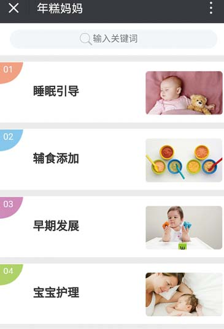

图7–4 “年糕妈妈”育儿知识菜单

以上就是历史文章重复利用的6个技巧。大家在了解之后，可以根据自己账号的实际情况，看看哪些技巧可以用在今后的运营过程中，一方面可以持续发挥优质文章的价值，另一方面也可以更好地为用户做内容服务。

## 内容运营栏目化

新媒体时代中，其实在某种程度上我们是在打一场注意力的争夺战。张小龙所说的“让用户用完即走”大家都听说过，但是这句话放在运营公众号上，并不是让我们把用户的注意力拱手让给其他的账号，而是想办法让用户更高效地获取内容，帮用户节省时间。

但是这时候就出现了一个矛盾，因为每个账号都想从更多的维度为用户提供更多的内容，所以现在很多账号不仅保持每日更新，而且每次更新超过3条，甚至直接达到推送条数的上限8条，愿意做单推的账号越来越少。这样导致的结果就是，定位越来越复杂，越来越不垂直细分。

但是我们不要忘记，大部分用户是不会点开每一篇文章阅读的。这样的做法就导致了用户筛选适合自己的内容，变得越来越困难，越来越复杂。这是一种不为用户着想，没有帮用户更好地做决策的做法。长期如此，我们推送的每一篇文章的打开率就会越来越低，总阅读量会下降，甚至，用户忠诚度降低，最终会导致取关率提高。

想要解决这个问题，就要栏目化运营内容。简单来说，就是将你的内容梳理归纳为几个类别，每个类别就是一个栏目，给每个栏目取个名字，每天推送内容的时候按栏目推送，给用户提示。我认为，栏目化运营内容有5大优势。

### 帮运营者梳理内容、明确定位

每个公众号都有自己的内容定位，但是在平时的运营过程中，受“流量的诱惑”经常会做出一些偏离定位，甚至不符合定位的选题。大家都可以回看一下自己的内容，肯定都出现过这样的情况。

我们做栏目化运营的过程，也是一个重新梳理、明确定位的过程。每一个栏目就是用户的一个内容需求点，解决一个痛点或者满足一个需求。你分好了栏目，也就是将定位做得更精准更规范了。你在做选题的时候就会更有目标感，更能从用户需求出发，这样无形中也提高了自己的选题质量和选题效率。

### 方便运营者后期管理内容

这一点也是对运营者的好处，我们之前在如何对历史文章再利用这节里讲了很多处理已推送文章的技巧。比如做专题整合、历史文章重新编辑、不同内容类别的页面模板等。如果我们每天推送三五篇文章，而没有分栏目的话，后期在做梳理工作的时候就会变得非常困难。相反，如果有栏目的话，就会高效很多。

### 用户有明确的阅读预期

从用户角度来说，你的栏目名字就是一个明确的预期。比如公众号“正和岛”的内容栏目一般包括大势、高手、案例、干货、姿势等。这个公众号的用户，在读过几次“正和岛”的文章之后，就会对每个栏目的内容有比较好的预期。

### 帮用户做决策，降低选择成本

刚才已经提到，并不是所有的用户都会阅读公众号推送的所有文章，他只想看对他更有用的。而且可能用户今天想看的和昨天想看的文章类型都不相同，如果你不分栏目，用户就得点开每篇文章浏览一下，这就增加了用户的选择成本。栏目化就是为了解决这个痛点。

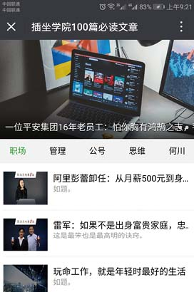

图7–5 公众号“插坐学院”的栏目

### 方便用户后期查询

现在很多的公众号都是日更，有些账号甚至日更三次，每次推送都会覆盖之前的，内容越积越多。有一部分内容时效性强，过去了就没价值了，但很多内容其实有长期价值的，比如“插坐学院”推送的内容。所以，很多用户经常会反复查看这些内容，而且有很多用户并不是每天都打开看，而是每几天查看一次，你怎么保证让用户高效地查看内容呢？做栏目化就可以。

为了帮助大家完成公众号栏目化，我总结出了以下三个步骤：

**@第一步：梳理内容定位** 根据用户的需求及痛点，重新梳理你的内容定位，将自己的内容认真地分一下类别，看看都有哪些内容板块。

**@第二步：为每个板块想一个栏目名字** 名字最好是两个字的，最多不要超过四个字，用常用字词，千万不要造词，要做到直接、有效、一目了然。

**@第三步：确立栏目的标注形式** 关于这一步，目前最主流的公众号普遍有两种做法：

（1）直接用栏目名字做封面图，设计好模板后上传到后台，每次都可以直接使用。这样做的优点是：栏目名不占用标题的位置，推送到朋友圈之后能正常显示，不用再给每篇文章找封面图。

（2）栏目名称直接在标题中展示，然后封面图依然根据每篇文章内容来定。这样做的好处是，封面图根据内容来定，选择好了可以提高打开率。不好的一点就是，栏目名称会占据标题的位置，导致标题变长。

另外，在我们进行公众号栏目化的过程中，如果直接用栏目名称做封面图，一定要确保文章分享到朋友圈之后，依然能非常清楚看到栏目名称。如果直接在题目中体现栏目名，最好将栏目名称放在题目最后，因为我们讲标题技巧的时候就说过，尽量把题目亮点放在开头。另外，栏目名称要和题目做区隔，用方括号“［］”、方头括号“【】”或者用竖线“|”都可以。栏目名称如果放在题目结尾要保证分享到朋友圈之后依然可以显示出来。如果不能把内容全部栏目化，我们也可以将其部分栏目化，比如“丁香医生”不全是栏目，但它有“丁当盘点”“丁当日历”等栏目，“清单”有“口碑清单”“测评”等栏目。

## 精心设置页面模板

所谓页面模板，就是给公众号创建网页的功能插件。公众号可以选择模板，然后导入文章素材生成网页，并对外发布。但是，目前只有开通了原创声明功能的公众号可以申请开通。如果你有原创功能，可以在账号后台的左侧功能区最下方找到“添加功能插件”这个菜单，点开之后找到“页面模板”，点击开通即可。

公众号页面模板暂时只提供媒体行业模板，其中包括列表模板和封面模板。

### 列表模板

列表模板比较简单，就是一个列表组成的页面，最多可以添加30篇文章，没有分类。这样的模板适合内容定位比较单一，推荐文章数量较少且不用分类的时候使用。比如公众号“拾遗”有一个主菜单叫作“好文”，点开后有两个子菜单：人物和观点。将这两个子菜单点开后，都是一个列表页面模板。

### 封面模板

封面模板的功能相对更优秀一些，它是由封面文章和分类列表组成的页面。最上方封面文章可以选择3篇，每篇文章显示大封面图和文章标题，这3篇文章可以通过左右滑动选择。封面文章的下面可以再添加列表文章，最多可以添加5个列表，每个列表可以添加30篇文章素材。并且，每个列表都可以添加相应的名字，也就是相当于分类展示内容栏目。

正是因为封面模板的功能强大，在用户体验上会比列表模板更好一些。用户点击进来后，可以按照栏目找到自己想看的内容，阅读预期比较好，而且这种模板最高可以容纳153篇文章。

[figure not shown]

图7–6 “冯仑风马牛”的菜单

以万通董事长冯仑的自媒体账号“冯仑风马牛”为例。它的菜单栏有个主菜单“内容精选”，点开之后有两个子菜单，分别是“精彩专栏”和“精彩视频”。这两个子菜单点开后都是封面模板，比如点开“精彩专栏”，这个页面模板上，有3篇封面文章，然后下面它将文章分为“冯叔说”“十问冯叔”“周签”“房事夜话”“人物”这5个栏目（如图7–6所示）。

如果你的内容分类比较复杂，5个栏目满足不了你的使用，你就可以像冯仑一样，做多个页面模板，然后将其放在菜单栏不同的子菜单下。

经过研究与整理，我将页面模板的优势总结成了5点，分别是：

·封面模板可以按照栏目呈现优质的历史文章，列表中的文章顺序可以随着公众号内容的更新迭代而随时调整。

·文章素材既可以添加已经推送的文章，也可以添加素材库中未被推送的文章。如果你使用超链接的话，就只能添加已推送的文章。

·页面模板呈现的文章列表可以同时向用户展示标题、封面图、摘要。（不过要注意的是标题只能显示14个字，摘要能显示35个字左右。）

·页面模板中展示的文章，保存着完整的数据，阅读量、点赞、评论都能显示。如果直接把文章添加在菜单栏，通过菜单栏点开的文章数据会重新计算。

·一个公众号最多可以创建15个页面模板。

页面的用处也十分广泛，当页面模板设置完成并且保存成功后，在页面最下方中间会有一个“复制链接”，我们只需要点击一下就可以完成复制了。这个链接可以放在菜单栏，可以放在“阅读原文”，也可以添加在关注后自动回复和关键词自动回复中。

另外，大家一定要记住。页面模板与菜单栏一样，一定要定期优化。因为页面模板在本质上也是一个内容查询工具，它是有工具属性的，这个工具应该随着你内容的不断增加而不断更新和优化。优化主要包括4个方面：封面文章的定期更换、列表文章顺序的优化、根据内容定位和栏目的变化定期增删分类列表、随时往里添加新的优质内容。

比如我经常在公众号“一席”上看视频，它的账号菜单栏有个子菜单“100000+”，点开之后就是一个列表模板，模板里都是它推送过的10万+内容。我经常发现它的账号上刚出现了10万+的内容，然后点开它的页面模板，就会发现这篇10万+的文章已经被收录进去了。这说明“一席”的运营者每天都会去查看、优化页面模板。

这些都是运营的一部分，就看你能不能坚持做，并且将它做到极致。

## 公众号作者栏的实用玩法

随着公众号的盛行，越来越多的行业人士纷纷投入公众号的开发中。不仅仅针对输出的内容，就连公众号的作者栏也成了大家的研究对象。这时大家可能会有“作者栏不就是填作者名字吗”的疑问。确实，原本作者栏的功能自然是为了填写作者的名字。但是强大的新媒体运营者们已经把作者栏玩出了花样，它的用途已经完全不局限于填作者名字，还诞生了非常多有创意又实用的玩法。在观察了大量公众号后，我总结出了最常见的几种。

### 作者信息

填入作者信息是最常见的，也是标准的做法。比如一些偏媒体机构类型的账号，作者们大都很在意自己的署名权，作者是谁就填入谁的名字。如果是转载的稿件，也要询问对方的需求，有的要填入原作者的名字，有的则需要填对方账号的名字。如果对方无要求，我们就可以自己选择，或者不填写也可以。

另外，现在很多账号在接广告的时候，会在作者栏填入“广告”二字。这样就可以让用户在看文章前有比较明确的阅读预期，减少对用户体验的伤害。

### 引导关注

引导关注的做法十分简单，也十分盛行，常见的形式有：“点击关注”“走进”“按右边”“点这”“戳右关注”等。

### 根据每篇文章给公众号加入一个人格化定语

比如公众号“丹尼尔先生”（如图7–7所示），它的作者栏几乎都是根据每篇文章的内容和题目填入的。

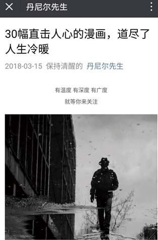

图7–7 “丹尼尔先生”的人格化定语

题目：《穿旗袍的女人，才是男人的毒药》，作者栏：莫名中毒的丹尼尔先生。

题目：《爱情多半不成功，不相互厌倦已是幸事》，作者栏：相信真爱的丹尼尔先生。

题目：《彼得·德鲁克：信仰需要经历绝望》，作者栏：坚守信仰的丹尼尔先生。

这样的思路很多。比如“插坐学院”追了一个热点，作者栏就可以填：追热点第一的（插坐学院）、拼手速的（插坐学院）、熬夜赶热点的（插坐学院）等。

再或者大家都在谈论小程序时，如果是“插坐学院”做这个选题的话，作者栏就可以填：被小程序惊艳了的（插坐学院）、喜欢小程序的（插坐学院）、正在卸载App的（插坐学院）。

这样的做法一方面可以帮助你做人格化的账号，另一方面作者栏中的内容其实对用户也起到了一个引导作用。用户看到后更容易去讨论这个话题，也就起到了促进转发、提高评论区讨论的作用，因为这个内容很容易成为一个槽点。

### 强化账号定位、内容风格的一句话

这一方面的例子也非常多，比如：

插坐学院：职场充电第一站。

清单：最专业的商品百科。

新经济100人：专注深度的。

年糕妈妈：1000万爸妈关注的。

### 直接填账号名称

如果你想让用户记住自己，不厌其烦的重复是一个最简单的策略。就像“今年过节不收礼，收礼只收脑白金”“高露洁，没有蛀牙”“保护嗓子，请用金嗓子喉宝”这样的广告一般，每次播出都要重复3遍。而“重要的话说3遍”，这句话一度成为互联网的流行语，而这句话说的就是重复的力量。所以建议那些作者栏空着的账号，将这个位置利用起来，如果没有什么可填的，就将账号的名称在作者栏里再重复一篇，这样做也要比什么都不填更好一些。比如“我走路带风”“财富中文网”“金错刀”“淘漉音乐”“顾爷”“剽悍一只猫”等我关注的账号，都经常在作者栏重复自己的账号名称。

以上就是作者栏的几种玩法，大家都可以进行尝试。这些技巧虽然简单，但可能在此之前大家都没有发现其中的作用。我们天天都在强调公众号要精细化运营，其实这就是精细化运营，连一个作者栏都要认真对待、认真利用。

## 历史消息的搜索功能

历史消息的搜索功能，一方面是为了提升用户的体验，节省用户的时间，而另一方面，也是为了让我们更好地去利用自己发布的历史文章。目前，历史搜索的工具有两种，分别是公众号自带的搜索功能和“新榜”开发的“号内搜”应用。

### 公众号自带的搜索功能

我们在关注任何一个公众号，点击历史消息页面后，在页面的顶部，会出现一个搜索框。输入关键词之后点击搜索，就可以搜索到这个公众号发过的文章的标题，或者内容中包含此关键词的文章了，这就是公众号自带的历史消息搜索功能（如图7–8所示）。

[figure not shown]

图7–8 系统自带的搜索功能

公众号自带的搜索功能不需要我们做任何的设置，每个账号都自带该功能。它只有两种搜索方式。

**@默认排序** 关于默认排序的算法，官方还未给出明确说法，但根据经验和搜索观察，大概是根据相关程度来排序，相关程度可能包括关键词与标题、内容的匹配程度、阅读量和点赞等。我们发现，默认排序中展示的文章，至少会在标题中出现我们搜索的关键词，而且前排的内容质量相对更高一些，也与预期更匹配一些。

**@按照时间排序** 按照推送时间的顺序，由近及远，也就是最近推送的在前排。

### “新榜”开发的“号内搜”应用

“号内搜”是内容创业服务平台“新榜”所推出的一项应用。我们将自己的公众号授权绑定“号内搜”之后，就会生成一个专属的搜索链接，然后把这条链接放在公众号的菜单栏里，大家就可以使用了。

因为“号内搜”是第三方平台开发的，不是公众号自带的，所以需要我们自己设置。首先登录“新榜”官网，点击进入“个人中心”—“我的资料”，授权“新榜”绑定你想要实现号内搜功能的公众号，然后根据提示一步一步进行操作。

相比自带的搜索系统，“号内搜”的搜索机制要更完善一些。我们可以设置筛选条件，输入关键词的时候你可以只选择题目中包含此关键词的文章，也可以选择全部显示。在时间范围上，你可以选择近一个月发布的、近三个月发布的，也可以选择全部历史文章。排序可以按发布时间，也可以按相关度。另外筛选条件还可以是只搜包含视频、音频或音乐的。搜索记录也会保留。“新榜”“我走路带风”“果壳网”“一读”“商务范”都在使用这个功能。

在了解过这两种不同的搜索工具后，我再介绍几种历史消息搜索功能的使用技巧。

**@高效查找文章** 你想搜索去年某个账号在“双11”时发过的一篇文章，如果你不知道搜索功能，那就只能点击查看历史消息，一直不停地向前翻，翻到去年11月11日可能需要十几分钟的时间。但是如果你记得文章题目中的某个词，就可以直接使用搜索功能，不再需要手动查找；如果你突然想再看一次在某个公众号上的一篇文章，但是你早已不记得那篇文章是在什么时间发出的，你可能根本无法找到那篇文章。但现在你只需要在“号内搜”输入关键词就可以找到。不只是我们专业新媒体人需要，所有的用户都有这样的痛点，而搜索功能都可以用“号内搜”完美解决。

**@选题、素材搜索渠道** 对于新媒体编辑来说，这也是一个非常好用的文章选题和文章素材的搜索渠道。比如当我想做某个选题或者写某个主题的文章时，我可以直接去某个我熟悉的垂直公众号中搜索。再比如当我想做一个关于“人生”的选题时，我可以直接去“新世相”中搜索。当我想写赵雷相关文章的时候，我首先想到的就应该是到民谣领域的一些精品公众号去搜索，比如“民谣故事”“民谣与诗”等，这样比直接在整个公众号系统内搜索要高效得多。

**@便于专题页面的制作** 如果我是一个做人物故事的公众号，写过很多次马云、任正非、雷军，我想将这些文章分类整理出来做成专题，我就可以直接搜索马云、任正非、雷军这些关键词，把相关的文章全部找出来，整理起来非常高效。

**@辅助高效学习** 搜索和精准度的提升，可以有效提高用户的学习效率。我们完全可以在任何碎片化的时间通过关键词查一些干货文章进行学习，只要随便输入一个关键词就有很多好的内容可供浏览。

当我们学会了如何使用历史消息的搜索功能后，应该做些什么呢？

**@创作标题要更加直接** 在今后的内容推送中，我们要使用更符合内容主题的关键词。我们平时起标题的时候，除了吸引点击外，还要问自己，这个标题是不是更容易被搜索到？比如我写了一篇关于选题技巧的文章，如果我在标题中不提选题或者选题技巧这两个词，被搜索到的概率自然就会大打折扣。所以，你的内容主题最好能在标题中有所体现，题文相符的内容会越来越受到用户喜爱。

**@避免成为“标题党”** 如果标题与内容不符，就会增加用户的搜索成本。有的人可能会自作聪明，故意在标题中使用更容易被搜到的字词，从而提高被搜到的概率，这其实就是“标题党”的做法，容易导致题文契合度不够，反而提高了用户的搜索成本。

**@分栏目运营内容可以将栏目名称放在标题中** 之前我们讲到按栏目运营内容时，我们讲过两种栏目展现形式，一种是在封面图中写栏目名称，另一种是在标题中写栏目名称。如果从优化搜索的角度来说，直接在标题中体现栏目名称相对更便于后期搜索。

**@有意识地引导用户使用搜索功能** 公众号在经历了这几年的发展后，整个体系内沉淀了大量的内容，而且越积越多。这些内容的价值非常大，有待挖掘，如何唤醒这些内容是微信一直在做的事情。所以，我们也应该有意识地引导用户在自己账号内使用这一功能，提高内容的利用率和用户黏性。

## 玩转公众号投票

虽然现在大家可以在很多账号上看到投票功能，但从整体来看，这一功能的使用率还比较低。很多账号不是不会用，而是很多运营者还未意识到投票功能的以下价值，像“吴晓波频道”“科技美学”“咪蒙”这些大号都曾多次利用投票做内容，效果都很好。

### 提高用户参与感

所有互联网人都知道要增加用户的参与感。但是参与感从何而来呢？其实就是在用户与你的互动中产生的，就是要让用户与你发生更多的关系。如果你在文章中设置了投票，那么投票也是这篇文章的内容之一，这个内容是由你和用户共同来完成的，缺一不可。用户和你共同推动完成一件事，参与感自然产生。

另外，投票和留言都是用户的互动参与方式，但你会发现每次参与投票的人数远远大于评论的人数，为什么？这其实涉及另一个问题，叫作参与的门槛。

试想一下，为什么朋友圈最主要的功能是发照片而不是发文字？而且纯文字的入口还藏得比较深，直到现在还有很多用户不知道可以发纯文字。微信朋友圈为什么这样设计？其实就是参与门槛的问题，文字的表达能力并不是每个人都有，但拍个照片谁都会。微信所做的不过是在降低你发朋友圈的门槛，让更多的用户更容易参与进来。

所以，投票这个动作对于用户来说，参与门槛非常低，只需要动一下手指就能参与其中获得参与感。如果说评论区相当于问答题，投票就是选择题。比较起来，选择题当然更好做一些，而且这个选择题通常还没有错误选项。“参与感”这三个字，对于每一个新媒体从业人员来说都大有可为。

### 增加用户黏性

黏性这个词我已经不需要再做解释，用户通过投票提高了参与感，进而减少了与你的距离感，达到了增加黏性的目的。而且，如果你每次的投票功能都设计得比较好，长此以往，用户就会养成每天来你这里投票的习惯。

另外，投票是一种让用户有自我满足感的事情，投票的时候用户会觉得自己在行使权力，在表达自己的观点，在向这个世界发出自己的声音，这对用户来说是非常重要的。

### 收集用户观点

创作公众号内容的过程，其实是个对外输出价值观的过程，但同时我们也非常希望知道用户们的观点。

比如在“新榜”的推文《“你愿意被别人称小编吗？”“自称是谦虚，你叫是蔑视”》中，作者想讨论新媒体编辑是否愿意被称作“小编”。文章结尾就做了一个投票，看看大家的看法是怎样的。

再比如“吴晓波频道”经常使用的一招：根据内容搞一个话题，然后进行投票。它通常会罗列出四五个观点，然后让用户投票选出自己的观点。比如它在《吴晓波：“壳”将很快成为一个历史名词》中设置了个投票：你最近如何选择一只股票（单选）。它给了5个观点备选，但我投票后一看结果，发现得票最多的竟然是：巴九灵推荐什么，我就买什么。做完投票它可能就会发现了，原来用户在推荐股票上如此信任我。所以，很多时候，用户在想什么，你是猜不到的，这时我们就可以多设置一些投票来收集用户的观点。

另外，吴晓波频道更厉害的是，它在投票位置上做了个广告，广告语为：巴九灵投票，把我们的观点告诉世界。投票由瑞士高端腕表品牌宝珀赞助。

### 加深运营者对用户的了解

我们心中的用户和真实的用户之间，永远都隔着一段距离，我们不可能百分之百地了解用户，但是我们可以通过设置投票让用户一次又一次参与表达，来缩短这个距离，让我们更加了解用户。

比如在“吴晓波频道”推送的《吴晓波：90后就别买京沪深的房子了》这篇文章中，就有一个投票“你继续留在大都市的理由是（单选）”，答案有：这里有我的事业梦想；这里有我爱的人；我喜欢这里的生活方式；我就是喜欢被虐等。

在关于达康书记的文章中，“吴晓波频道”也设置了一个投票：你喜欢职场中这种“唯业绩论”的人吗？

其实诸如此类的问题，都可以让我们更好地了解用户，每一个投票就是一个角度。你越了解用户，就越知道如何为他们提供服务，也越知道如何在他们身上变现。

在使用投票功能时，同样有几个需要注意的事项：

**@多做投票，让用户投票成为一种习惯** 我之所以建议大家多设置投票，其实就是因为投票的主题很好想。只要你想做，每篇文章都可以根据内容做一个投票。建议大家去看看日更公众号“科技美学”，每次都会推送五六篇文章，并能保证每天推送的每篇文章都有一个投票让用户参与（如图7–9所示）。之前我找了一些单选的投票问题计算了其中的投票人数，结果非常喜人，很多阅读量不到10万的文章，投票人数却能超过1万，这种活跃度堪称强大。这就是长期做投票，让用户形成稳定的预期和习惯的好处。

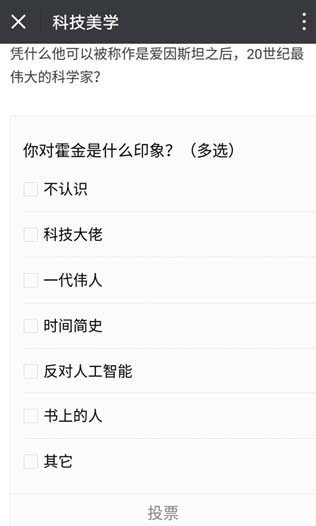

图7–9 “科技美学”文章投票

**@投票的问题和答案设计都很重要，要让用户有参与的冲动** 如果你想让投票有更多的人参与，那么你设置的问题就要保证是大多数人所感兴趣的，并且你所提供的答案，也要能覆盖大众主流的几种观点，答案的表述上也建议幽默有趣一些，这样用户的参与热情才会高。

“科技美学”在《苹果iPhone 8设计图曝光，这次苹果搞了不少幺蛾子》中做了个投票：你觉得苹果目前的创新有意思吗？（单选）”，这个题目就是大部分用户都想表态的一个问题。再来看看它的选项：（1）脑洞大，我喜欢；（2）脑洞是多，但是总研究没用的东西；（3）黔驴技穷了，赶紧找点妹子来吧；（4）不耽误用的话不太在乎；（5）不care（关心）苹果，路过。这5个选项基本覆盖到了所有的主流观点，绝大部分用户都可以在里面找到自己的态度，而像脑洞、care、路过等字词句非常符合年轻人的表达方式，让用户看着有感觉有共鸣，自然更愿意参与这样的投票。

**@一篇文章中只能添加一个投票** 一个投票最多只能添加10个问题，一个问题最多能添加30个选项。投票的截止时间可以更改，进入公众号后台，点击投票管理，选择投票项目，点击详情后，里面有一个有效时间，点修改截止时间就可以重新设置。

在“神秘”的公众号中，可能还有着很多我们没有注意到的功能。不过相信大家在了解了这么多实用的技巧后，已经提高了对这些细节的重视程度。带着这一份重视，在未来的时间里，我们还会发现更多，同时也会得到更多。

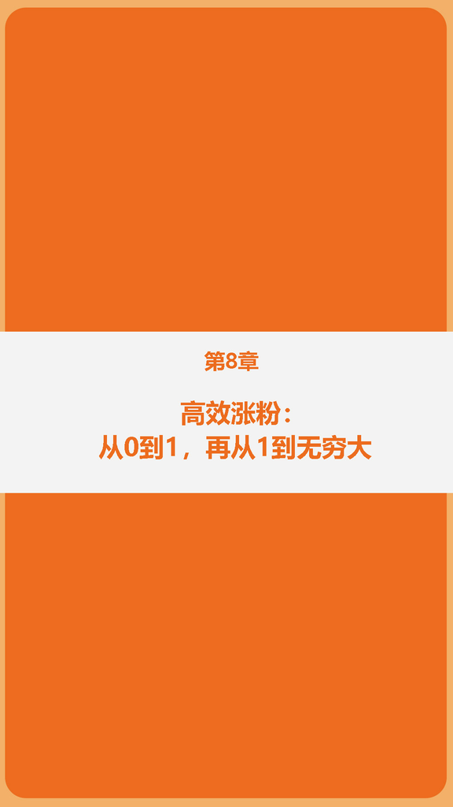

我们在运营公众号中所做的所有努力和使用的所有技巧，最终目的就是赢得更多用户的关注和喜爱。而为了这一目标，无数公众号的经营者上下求索而不得，煞费苦心而无果。其实，涨粉并不像大家所想象的那样神秘、困难。我们只要从用户的角度出发，并配以适当的技巧，就可以完成从0到1，再从1到无穷大的目标。这一章，就为大家介绍一下公众号涨粉的正确方法。

## 账号冷启动：如何找到第一批用户

有些朋友的公众号可能才刚刚起步，只有几百、几十个用户，有些才刚刚完成注册，粉丝只有自己和老板，也有些甚至还没有注册账号，刚刚有做新号的打算，所以迫切地想知道如何从0到1启动一个新账号。

接下来我们就来谈谈如何让账号冷启动，获取第一批用户。我为大家总结了6条普遍适用的经验，希望能够对大家有所帮助。

### 用已有账号推广

这一条适合公司已经有至少一个账号然后做新账号的编辑。

比如我在“创业邦”工作的时候，虽然已经有了“创业邦”这个账号，但当时又准备做一个泛科技类账号“毒舌科技”。“毒舌科技”最初的2000个用户就是我们从“创业邦”上导流过来的。我们会精心编辑一个推广“毒舌科技”的文案，然后放在“创业邦”头条文章的底部，告诉我们的用户，我们在做一个全新的账号，说明这个账号的价值，吸引大家关注。我们大概用一周的时间做了五六次推广，就成功吸引了2000个用户。

当然，除了用已有账号文末推广，还有其他的利用方式，比如：通过已有账号转载新账号文章导流；在已有账号的菜单栏里推荐新账号；在已有账号的关注后自动回复里推荐新账号；在已有账号推文的阅读原文链接里推荐新账号；甚至我们可以在已有账号推文的评论区置顶首条评论推广新账号。

### 用公司的其他内容平台推广

很多企业一直以来都有着自己的内容，而注册公众号的原因则是想要向移动端转型，所以大家就一定要利用好公司原有的内容平台。因为那里有很多忠实的老用户，这部分用户过来后就会成为高价值的种子用户。而转移这部分用户的方法也有很多，比如：在自己的朋友圈进行宣传，在公司的微博上宣传，在公司官网上进行宣传，或者是论坛、贴吧等途径都可以。

### 线下用户引流到线上

很多的企业新媒体都有自己的实体店或线下终端，这是一个非常好的资源，应该充分挖掘。

比如最近几年比较火的零售品牌“名创优品”，他们在线下有超过1000家实体店。而它的公众号超过1000万的用户，大部分都是从线下引流而来的。其中一种方式是，顾客在结账的时候，如果扫码关注账号则购物袋免费，否则收费，这就使得大部分用户都会选择扫一下。

再比如餐饮品牌“嘉禾一品粥点餐厅”的微信点餐，“绝味鸭脖”的微信支付立减5元等都是将线下用户引到线上的好办法。而且，通过线下引流来的用户，都是我们需要的精准用户、付费用户。当然，这个线下并不仅仅是指实体店，我们还可以通过线下培训、线下的各种社团聚会组织、定期的分享会等途径引流，这些线下资源都可以去挖掘利用。

### 借助其他平台组织策划线上活动

之所以要强调其他平台，是因为一个新账号目前还没有用户，也没法建立微信群，所以你要去找自带用户的平台去做线上的活动，把参与活动的用户转化为自己的用户。

就目前而言，去各个知识分享平台做分享是一个有效的手段。我记得有一次线下课的时候，有一个同学的账号是为那些“有一定的工作技能和影响力，想辞职成为自由职业者”的用户提供服务。像这样的账号你就可以找一些已经完成了“从上班族到自由职业者转换”的成功案例，然后付费邀请这些成功人士去做分享，比如现在比较火的知乎live、一块听听等平台。如果做得好，一次就可以连接几千甚至上万的用户。

### 微信好友、微信群和朋友圈推广

之前我注册了一个自己的小号，叫作粥左罗。由于当时并没有其他的渠道，所以我首先就想到了自己的微信好友和朋友圈。当时我花了两天的时间琢磨了几段文案，表达我做了个公众号、这个号是做什么的、以后的内容质量会很好等等。然后再加上了一些有理想和情怀的、能让人有共鸣的话，最后加上一张配图，整体做成了一张图片，群发给了我的微信好友。

因为那个文案写得非常真诚，所以虽然当时我只群发给了1200个微信好友，但却转化过来了将近700个用户。然后我又做了一些比较吸引人的小海报，发朋友圈、发微信群去进行推广，这样很快就完成了初期1000个用户的积累。千万不要轻视这个不起眼的渠道，就是因为我当时有了那部分用户的积累，所以推送的第一篇文章阅读量就超过了3000。

一定要利用好你的微信好友，因为现在每个人的好友都很多，如果你们小团队有5个人，每个人都有3000名好友，那就是15000名好友。你只需要花时间写一个比较好的推广文案，群发一下，可能仅仅通过这个渠道就能转化3000名以上的用户。甚至有很多运营者会专门注册一些微信号，然后去各种微信群加好友，一个微信号能加5000名好友，加满几个，这将会成为你做种子用户的手段。

### 付费推广：KOL、行业公众号

这是一个简单粗暴的方法，而且效率也相对较高。但要注意的是，一定要做到精准匹配。比如我要做一个“为新媒体编辑提供干货内容”的账号，那我就可以找到这个圈子中小有名气的新媒体高手、圈子红人、意见领袖和专家，与他们建立联系，并付费让他们在自己的朋友圈、微信群、公众号为我做推广，也可以付费让行业相关的自媒体账号做推广。因为他们在垂直行业都有比较大的影响力，如果匹配得好，这样获取的种子用户就会比较精准。

最后，再为大家分享一些做新账号时的注意事项：账号在做冷启动获取第一批用户之前，一定要把前期的工作做好，目标用户和内容定位一定要思考清楚；账号的名字和头像要足够吸引人而且相对固定，不要频繁更换改名字和头像；写好公众号的功能介绍；关注后的自动回复文案要精心设计；新用户关注后，在还没太多内容的时候如何跟用户互动也要提前做一些准备。因为初期的时候，用户还没有跟你建立信任，你这里也没有太多内容，前期这些工作做好之后，新用户来了会有比较好的信任感，否则新用户的留存率会比较低。

## 巧妙使用关键词回复

大家都知道公众号有个功能，就是可以在后台设置关键词自动回复。用户在你的公众号输入关键词，后台就自动回复相应的东西，可能是一篇文章、一张图片、一段文字。而这一功能，也可以帮助我们涨粉。

自动回复能够涨粉的原因非常简单，因为用户只有关注你之后才能回复关键词。所以只要你给出的东西足够吸引人，用户就会有动力先关注你，然后再回复你提示的关键词。下面是我为大家总结的利用关键词回复涨粉的5个技巧。

### 回复关键词查看公众号历史爆文

如今很多公众号都是日更甚至是日更三次，如此长期积累，一定会沉淀下来很多优质的文章，而这些文章的实效性通常较弱，是值得拿出来反复推荐给用户看的。所以，我们首先要将账号中推送过的精品文章找出来，然后做成关键词自动回复，最后在每天推送的文章底部附上这个关键词提示。

但大家使用这个技巧的时候也要注意，一次不要推荐太多，否则就会影响用户的阅读体验。我建议，每次推荐3到5篇即可。

### 根据文章内容用关键词回复推荐相关文章

这一个技巧与上一个的区别在于，第一个技巧中推送的文章和回复的关键词是什么没有关系的，而这个技巧是根据每一篇推送的内容，找到用户可能感兴趣的点，然后提示用户回复关键词就可以获取相应的文章。

公众号“说钱”就一直在使用这个技巧，比如《北京街头免费发硬币，结果被美女连盘偷走！》，它的文末写道：“想占便宜的人，往往占不到便宜。不想占便宜的人，生活不会让你吃亏。世间的美好那么多，别让那些贱人坏了心情。”然后，根据文章内容及结尾文案，它又写了“如果遇到这样的亲戚怎么办，关注公众号‘说钱’，回复‘亲戚’查看。”

### 回复关键词获取相应的福利

你可以经常给用户准备一些吸引人的福利，通过回复关键词的方式获取，从而刺激用户关注。

时尚大号“深夜发媸”曾在文章《拒绝假货！正品化妆品该去哪里买？》的末尾这样写道：“翠花整理了一份品牌官方旗舰店网址，后台回复‘地址’就能收到。这么贴心，你不打算给个赞吗？”

这种方式也是比较常见的，比如回复关键词获取一些干货、教程、资料、图片等福利。

### 回复关键词获取金句等

这里的金句是一个代称，使用起来也有很多种方式。这个技巧一般都是账号的固定栏目，每一篇文章都会有，每天也都会更新内容。

比如有段时间公众号“蛙哥漫画”在推文的文末写道：“后台回复‘晚安’，蛙哥送你一句暖心的话入梦。”

再如公众号“剽悍一只猫”，它会在每篇文章的开头提示：“今天在后台回复‘猫叔晚安’，我送你一个锦囊。”这个锦囊就是一个金句，或者是引人思考的，或者是让人温暖的，抑或是正能量等等，并且每天的锦囊都会不一样（如图8–1所示）。

[figure not shown]

图8–1 “剽悍一只猫”的开头提示

再比如公众号“清单”的每篇文章开头也会提示：“回复‘晚安’查看今天的清单日签”，这个清单日签通常是每天科普一个生活、购物的小常识，同样每天更新。

我举的这3个例子，回复的都是一张精美的图片。并且图片中有该账号的二维码，当用户将它分享到朋友圈时，自然会起到涨粉的效果。

### 将回复关键词变成线上活动的一环

“新世相”策划的“逃离北上广”活动，为它涨粉20万左右，其中一个原因就是在这个大规模的线上活动中使用了关键词回复。如果用户直接点击“阅读原文”就能参与该活动的话，很可能用户在参加完活动后，都不会关注公众号。所以“新世相”让所有想参与活动的用户，首先必须要在公众号回复“逃离北京”、“逃离上海”或“逃离广州”，这一点非常值得大家借鉴和学习。

以上就是通过关键词回复涨粉的5个基本技巧，本质上都是要先找到一个用户感兴趣的点，从而刺激用户去关注账号，再回复关键词获取这个点。当我们理解了这个玩法的本质，就更容易探索出更多的涨粉方式了。

## 一对多互推：最有效安全的免费涨粉方式

互推，顾名思义就是不同账号之间互相推荐。而一对多互推就是一个账号，一篇文案，一次推荐多个账号。我认为，互推可能是除了做爆文之外，最有效且安全的免费涨粉方式。其实早在公众号诞生之初，互推就随之诞生了。因为当时用户们的关注需求较大，但公众号规模较小数量有限，因此正是公众号迅速爆发的红利期，借助互推每天可以涨粉几千甚至几万。但如今，公众号数量早已突破了2000万个，微信用户超过8亿，用户关注的账号几近饱和，因此早期的互推方式效果已经很差了，且非常影响用户体验。

早期的互推方式往往有以下几个特点：题文不符的标题党、文案粗制滥造、被推荐的公众号质量参差不齐、互推过于频繁。

如今，依然有很多账号在用互推的方式涨粉，而且效果也不错，这是因为互推的形式已经经过了升级。我们以做得比较好的两个账号“小道消息”（如图8–2所示）和“Keso怎么看”为例，总结出了一对多互推的4个技巧。

[figure not shown]

图8–2 “小道消息”公众号

### 标题：拒绝标题党

早期的互推一般以标题党为主，比如《2015年最赚钱的10大行业，排在第一的竟然是》点击进去后变成了《这6种人，擦肩而过即可，无须深交》，由于用户点进去之前不知道是互推，再加上被推荐的账号一般质量不高，所以使得用户经常有被骗的感觉，甚至造成很多忠实的用户愤而取关。

而现在的互推，一般都会直接在标题中体现“荐号”二字。

“小道消息”的互推文章题目是《微信公众号推荐：2017第二期》这类的。这个账号从2015年就开始做这样的互推，一直坚持到现在。“小道消息”会在文章的题目中提醒用户，这是个互推文章。而“Keso怎么看”有一篇互推的题目直接就是《荐号》。这样不仅不会伤害用户，反而让用户觉得你更值得信赖。

### 推荐语：真诚不套路

早期的互推文案都是满满的套路，而且现在很多不注重阅读体验的账号依然如此。比如我最近看到的一篇互推文案，题目是《荐号：高智商高EQ的人，都是这样做的！》，点开之后就是8句话：“1.丧志的话的不能讲；2.负气的话不能讲；3.抱怨的话不能讲……”8句话之后，紧跟着一句文案：“关注以下公众号，成为成功的人！”再下边就是密集的12个公众号。毫无疑问，这样的文章严重伤害了用户的阅读体验。

在公众号“Keso怎么看”里，《荐号》这篇互推的文案是这样写的：“我这个公众号开设还不到一年，订阅数也很少，但从一开始就得到不少好朋友的推荐，心存感激。我下面推荐的这些公众号，都是我喜欢的，而且它们每一个似乎都比我有名得多，我的推荐对他们来说未必有多大价值，但我的用户中未必每个人都知道它们，我想让用户知道这些有价值的公众号。”然后在下方附上推荐的8个账号，并且以介绍朋友的口吻为每个账号写推荐语。

比如，他给“叔的刀法”写的推荐语是：“从传统纸媒，到传统网媒，李方是媒体兴衰的直接见证人和参与者，如今是腾讯网总编辑。一年半以前开设公众号，常就热点话题发声，每每引发波澜，外界有赞有灭，没少挨骂。但起码，他的公众号不是废话和鸡汤，用户总有所得。”

这样的推荐语非常真诚，用户会感觉到作者把自己当作朋友，为朋友介绍自己朋友，用户不光不反感，还会很感激。

### 账号选择：挑选精品账号

找阅读量相近的账号组队推荐，只看阅读量却不关注质量，这是一种粗制滥造的互推方式。然而，有很多阅读量高的账号都是些质量很差的营销号，最可怕的是，其中有很多是刷量的账号。这种情况，我在2016年做互推的时候就遇见过不少。

像“小道消息”这种做精品互推的账号，他们主要是看公众号的质量，而不是阅读量和用户数。他们推荐的很多账号我都会关注并且浏览一番，这些账号的阅读量从几千到几万都有，并且大都是质量非常高的原创号，这样的推荐就是一个良性循环，既能互相涨粉，又能保证用户体验。另外，其实你也不必太计较阅读量，因为用户的价值是不一样的，比如“Keso怎么看”其实是知名IT（信息技术）评论家洪波主理的账号，虽然用户数不大，但关注这个号的一般都是互联网圈中相对高端的用户，被他推荐一次也是非常值得的。

### 推送位置和频次：头条推送，频次较低

早期不注重用户体验的互推，几乎都是每天都有一条互推文案，而且一般是放在二条、三条位置。现在，像“Keso怎么看”和“小道消息”这些主打互推的公众号，一般都是放头条。它们比较注重用户体验，希望少进行推荐，但每次推荐都尽可能地连接更多的用户，所以一般就是头条推荐，周期较长。

以上就是一对多互推的4个技巧。我推荐大家都亲自去看一看这些互推文案，因为我每次看到都会觉得非常受启发，学到很多自己不曾发现的技巧。

## 一对一互推：强强联合，而非互捧臭脚

所谓的一对一互推，指的就是在一个账号或一篇文章里，只推荐一个账号。

2017年2月22日，公众号“周冲的影像声色”在接受“新榜”采访时称，过去8个月涨了70万粉丝，总粉丝数突破了100万。而关于大家都很感兴趣的涨粉经验，周冲也进行了分享。据周冲透露，自己账号的成功，除了那些优质的原创文章外，还多亏和很多大号进行了互推。并且，无论是原创的爆款文章，还是转载的优质文章，对于涨粉来说，都是很好的方法。

2016年“新榜”在采访优质原创账号大家“和小北”时，他也提到互推是重要的涨粉手段。

所以，正确地使用一对一互推，也是我们在经营公众号的过程中必不可少的一种技巧。关于一对一互推，我重点研究了比较擅长这方面的优质原创大号，比如“灵魂有香气的女子”“周冲的影像声色”“阿何有话说”等，总结出以下6个技巧。

### 题目：直接用被推账号的爆文题目

“灵魂有香气的女子”这个账号在2017年2月27日的一篇互推，题目是《有钱有事业的男人想娶什么样的女人？》，这个题目就是被推荐账号“遇见小mi”一篇文章的题目。

目前一对一互推，题目的套路基本都是如此。从逻辑上来看也是成立的，当用户被题目所吸引点击进入，然后你告诉用户，这篇文章是来自某个账号，那用户去关注这个账号就是顺理成章的事情了。

一对一的互推一般题目中是不加“荐号”二字的，因为如果是一对多互推，那么无论你推荐的账号多么精彩，从推广形式上来看都是简单粗暴的，因此要加上“荐号”来提高用户的体验。而一对一互推，不管你推荐的账号是不是精品，从形式上来看都是很精致的，用户体验相对有保证，因此可以不加“荐号”。当然，为了更好的用户体验，双方也可以经过商量，使用“荐号”二字。

### 作者栏：填“公众号推广”“荐号”等提示语

一对一互推文案的题目中一般不写“荐号”二字。所以为了加强用户体验，一般会在作者栏填写“公众号推广”“公众号推荐”这样的提示语，当用户被题目吸引进来之后，及时告知这是一篇互推文案，看与不看由观众自己选择。

当然，如果你在题目中已经加了“荐号”，那么在作者栏中自然可以不填，这时候我们可以填入被推荐账号的名字，这也是一种资源有效利用的手段。

### 位置和频次：非头条，高频率

在进行一对一互推时，选择的账号质量相对有保障，并且文案相对精致，所以在某种程度上保证了用户的体验，而且一对一互推的涨粉效果是比较好的。所以，很多账号互推的频率非常高，像“灵魂有香气的女子”（如图8–3所示）、“周冲的影像声色”，甚至经常每天都有一条互推，位置一般都是放在非头条。

[figure not shown]

图8–3 “灵魂有香气的女子”的一对一互推

### 文案技巧

之前我们所介绍的一对多推荐的文案技巧，用为朋友介绍朋友的口吻给每个被推荐账号写一段推荐语。这样做的优点是用户体验好，但缺点也很明显，就是涨粉效果和推荐者的文案水平挂钩，效果不稳定。

相对于一对多的文案，一对一单推的文案有所不同，一般由被推荐账号的作者自己提供。比如“插坐学院”要给“新榜”做推广，那么推广文案就是由“新榜”来提供，由于新榜对自己账号的优势足够了解，因此写出来的文案也更有吸引力。这样的文案写作套路一般为：

开头以用户的视角介绍被推荐账号（即自己的账号），比如“大家好，今天给大家推荐一个我超级喜欢的作者”。紧接着介绍一下作者的信息，还可以罗列一些作者或者公众号的成绩等，激发用户的兴趣。

在中间部分，一般会罗列一些账号曾经产出过的爆款文章，每一篇再附上几句推荐语或者文章概要，然后提示用户只要关注此账号，就可以看到这些文章。如果做得再精致一些，还可以告知用户关注后查看这样文章的方法，比如去菜单栏找，比如回复相应的关键词获取，等等。

最后，再写几句精彩的推荐文案，附上二维码，提示用户进行关注。

### 文末对互推行为做简单声明

由于大多数一对一互推的频率都会比较高，因此时间长了，即使你推荐的账号质量不错，可能也会引起用户反感、猜测甚至是取关。所以，我观察到一些账号的作者比较聪明，会在文末对这个互推行为向用户做一个简单的解释说明，比如“灵魂有香气的女子”文末会写上“生活有不同的精彩，灵魂有香气的女子会不定期推荐一些不同风格的公众号给大家。推荐文案由对方提供，香蜜们可以根据自己的爱好决定是否关注。本文非营利，请大家多包涵理解”。

另外，像“周冲的影像声色”“阿何有话说”“剽悍一只猫”等账号，互推文案的文末也都有类似这样的声明，在这里就不一一赘述了。

### 定期删除互推文案

我在研究这些账号的互推玩法的时候，发现很多互推文案都已经删除了，这也是提高用户体验、保护品牌美誉度的一个手段。因为单推频率较高，时间长了，你的账号上会积累大量的互推文案，而且这些文案并不是值得用户反复阅读的文章，会影响用户体验。

另外，你的广告主也不希望准备在你这里投广告的时候发现你这里有一大堆互推文案。从心理上，大家可能更喜欢全凭优质内容做用户的账号。所以，互推双方可以商定，比如文案在推送一周后进行删除。

以上就是一对一互推的6个技巧，想要让技巧奏效，我们首先要有永远对用户负责、一切以用户价值为中心的思维方式。即使做互推，你也要问自己，我推荐的这些账号用户是否真的会喜欢，我推荐的账号的内容是否真的值得被推荐。所以，挑选互推合作账号的时候一定要严格把关，互推一定是强强联合，而不是互捧臭脚。

## 账号矩阵：用大号为小号导流

从2016年开始，越来越多的大号开始做账号矩阵。做矩阵的目的其实很简单：首先，不要把鸡蛋放在同一个篮子里，通过做矩阵可以加强账号抗风险的能力；其次，垂直化自媒体是未来的方向，商业变现更有优势，这也是做矩阵的目的；最后，做矩阵本身就可以通过账号裂变拥有更大体量的用户数。

比如知名的情感类账号“小北”有超过200万粉丝，“小北”的团队还运营了超过120万粉丝的“睡前故事”和超过35万粉丝的“一个人的小酒馆”。

再比如，新媒体大佬沙小皮在拥有大号“视觉志”的同时，也运营着“她刊”“一读”“少女兔”等多个百万级大号。在2017年初接受“新榜”采访时，沙小皮称他们团队已经从“视觉志”一个账号变成一个坐拥2000万粉丝的账号矩阵，很显然想靠“视觉志”一个账号做到2000万粉丝是非常困难的，但是做矩阵的话就相对简单了。

经过对这些成功账号的研究和学习，我总结出了5条大号带小号涨粉的技巧。

### 大号关注自动回复文案里推荐小号

在某段时间里，“深夜发媸”的自动回复中一直有一句是“徐老师推荐关注美妆护肤小能手：深夜种草”（如图8–4所示）。“深夜种草”其实就是“深夜发媸”旗下的一个美妆类账号。

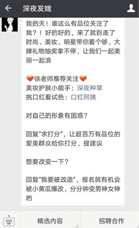

图8–4 “深夜发媸”自动回复

我们在“自动回复”中讲过这个小技巧，其中一点就是推荐其他内容载体，除了推荐小号，也可以根据你的需要推荐自己的微博账号、App和网站等。比如“插坐学院”在自动回复文案中，有时就会推荐自己的App“好多课”。不过“插坐学院”会经常根据需要及时更换自动回复文案，这一点值得大家学习，现在有很多账号的自动回复文案半年甚至一年都不更新。

### 大号菜单栏里推荐小号

“深夜发媸”某个时间段内的菜单栏中，一直有一个主菜单“美妆”，“美妆”又包含两个子菜单——“变”和“美”。点击“变”这个子菜单，系统就会自动回复一张图片，这张图片就是推荐小号“深夜种草”的。为此，运营者还做了一张比较可爱的引导关注图片，上面写着“关注这个美妆号，比别人早一步变美”，然后下面就是“深夜种草”的二维码，再加一句“长按扫码关注”。

### 大号转载小号文章，为小号导流

“少女兔”是“视觉志”旗下的一个手绘漫画类账号，“视觉志”有段时间经常会在头条位置转载“少女兔”的文章为其引流、涨粉。我之前在做“创业邦”这个创业类账号的时候，也用这个号给公司的新账号“毒舌科技”导流。当小号“毒舌科技”产出了质量比较高的爆文之后，便用大号“创业邦”进行转载，文末附上二维码和文案，推荐“毒舌科技”，效果显著。

### 直接在大号文首、文末推荐小号

“十点读书”的用户数之所以能够高速增长突破2000万大关，就是因为它在做矩阵上动作频频，如“十点课堂”“十点好物”“十点视频”等。它会经常直接在大号的文章内容中推荐小号，推荐位置一般在文首、文末处。

比如2017年12月4日，“十点读书”推送的第三篇文章《木心：文学是人生必备的武器和良药》，文末就是用一屏的位置推荐它的新账号“十点视频”；而在2017年12月6日推送的第五篇文章《你的坐姿，正在慢慢毁掉你》的文首，也有一屏文案推荐它的另一个账号“十点好物”。

### 大号建专栏推荐小号

这是一个十分常用也是十分有效的方法。如果你的大号定位相对比较广泛、比较模糊，想做一些定位更清晰、内容更垂直细分的账号，就可以用这种方式来裂变小号。在这一点上，“深夜发媸”值得大家学习。

有段时间它的推送中经常有个专栏叫“明星照妖镜”，这是为了给它的小号做推荐。但是它文末的推荐方式非常有新意，做了一个运营和徐老师微信聊天的截图，文案的对话是：

运营：“徐老师，我和小黄瓜发现大家都超喜欢明星照妖镜，我们想把它单独发在另一个账号里，让大家可以专心地看明星。”

徐老师：“很棒呀，记得告诉大家。”

运营：“好，有什么要注意的吗？”

徐老师：“告诉大家去哪看，还有别忘了二维码。”

运营：“扫码关注‘明星照妖镜’，小黄瓜带你专心看爱豆。”

随后，“深夜发媸”自然而然地放上了“明星照妖镜”的二维码，这是一种非常人格化的推荐方式。

以上就是大号带小号有效涨粉的5个技巧。最后提醒大家的是，做推荐的时候要注意频次，切勿太过频繁。并且你还要保证小号的内容质量，不然用户可能没关注小号，还取关了大号。最后，大号和小号的定位要有区分度，这样才能保证在关注小号的同时，大号依然有存在的价值。

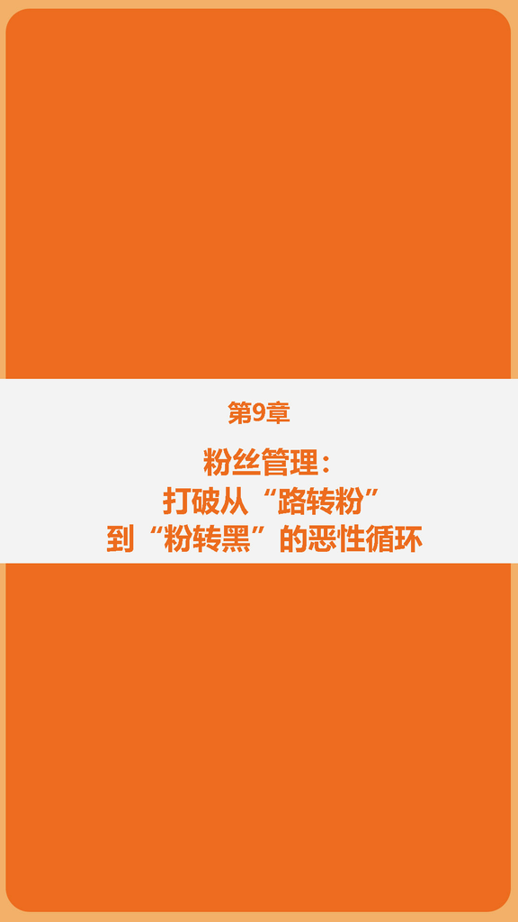

粉丝管理是公众号运营的关键，运营者把一个公众号打造成型，就相当于蚌贝打磨出了一颗珍珠。我们需要把“珍珠”展示出来才能让世人了解到它的价值。只有用户的加入和支持，才能让“珍珠”的光辉灿烂耀眼，历久弥新。那么，公众号究竟要怎么做，才能使用户知道并喜欢上自己，成为公众号的忠实粉丝呢？

## 后台数据是理性运营的关键

在传统媒体时代，我们完成一项工作并传播给大众，几乎拿不到任何有效的数据反馈，因此这项工作到底成效如何只能靠自己猜测。而通过新媒体，我们可以即时得到最直观最理性的后台数据，工作中的高低优劣会清楚地呈现在眼前，这是新媒体相较传统媒体的一大优势。数据可以最直观、最理性地告诉你，工作中你哪些做得好，哪些做得差，哪些需要及时纠正。

一个优秀的新媒体编辑，每天第一项任务就是查看后台数据复盘昨天的工作。通过数据不断地优化选题、标题、内容定位等，摒弃自我主观判断，逐渐形成数据思维，用数据支撑工作。工作中少一点“我觉得”“我认为”，多一点数据支撑，因为人的判断力是不稳定的，而数据不会撒谎。日积月累，这样打造出来的账号才会越来越好。

可面对繁杂庞大的后台数据时，我们到底要筛选出什么样的数据、怎么分析这些数据呢？在公众号后台数据中，通常包含了用户增长数据、阅读量数据和用户互动数据三个模块。下面，我们就一起来简单了解一下。

### 用户增长数据

**@净增、新增、取关** 每日用户净增数是需要首要关心的数据，它直接关联着公众号的用户基础。每日净增数的理想状态是：整体稳定，趋势上升。如果今天净增1000用户，明天净增200用户，后天又净增500用户，那说明公众号每天的内容并不是持续稳定、符合用户预期、满足用户价值的，需要及时调整，保证净增状态的稳定。

除此之外还要将每天的数据与平均水平线比较，如果低很多，就要反思哪些工作没有做到位；如果高很多，就留意哪些工作做对了。

做完这些工作，我们再相应地去关注新增和取关这两个数据。新媒体平台中，取关现象是一定存在的，如果数据显示每天新增500用户取关100用户，那就是处于正常范围，淡然看待即可。如果数据显示，新增200用户取关100用户，则超出正常范围，需要马上查明原因，可能是选题过于跑偏、文章质量大幅下降等。

**@用户来源数据** 用户来源主要分为公众号搜索、图文页内公众号名称、名片分享、扫描二维码这四大类。通过分析账号关注来源数据，分别对不同的关注渠道加强引导。如果账号扫描二维码来源占比高，则需要加强引导；如果账号点击图文页内公众号名称来源占比高，就在文章开头加强引导大家点击账号名称来关注公众号。

### 阅读量数据

**@阅读量变化趋势** 如果你没有其他的推广手段，那么公众号每天的新增用户主要由内容来驱动，所以阅读量数据是每天要看的第二重要的数据。与每日净增数据一样，最理想的状态就是：整体稳定，趋势上升。

如果公众号近一个月的评论头条阅读量是3万。那么以此为标准，每天发文章时以至少3万的阅读量为目标。分析数据时看阅读量数据是否在平均线以上，然后再通过阅读量中的其他数据来分析昨天的内容。

**@公众号会话打开人数** 公众号会话打开人数直接反映了文章的选题、标题。如果标题新颖抓人，那么打开率会很高。反之，标题枯燥无味，那用户的点击欲望就会瞬间下降。公众号会话打开人数跟内容质量没有关系，只与选题、标题有关。所以，每天要通过打开人数来复盘自己对选题的敏感度、对标题的把控度。长期分析下来，我们就能了解到自己的账号上，什么样的文章打开率高。

**@文章转发分享人数** 阅读量数据中，最重要的就是文章转发分享人数。打开率代表的是我们对存量用户的利用，分享人数代表着公众号的增量用户。如果账号阅读量很高，但只是打开率高的话，就代表公众号的增长停滞，需要提高文章转发分享人数，只有分享才能带来新的增量。

**@朋友圈阅读量占比** 朋友圈阅读量占比也非常重要，需要搭配阅读量、分享人数这些数据来看。朋友圈阅读量占比越高越好，因为这就是代表增量的数据。

**@四个看阅读量数据的小技巧** 阅读量低、分享人数低：选题、标题差，文章写得不好。也就是说喜欢读的用户不多，读完愿意分享的用户也不多。

阅读量低、分享人数高：标题差，但文章写得好。标题不好，致使点开率低，但文章很好，用户读过后愿意分享，所以分享人数很高。但因为标题差，分享也无法带来多少增量，所以阅读量还是不高。

阅读量高、分享人数低：标题好，但文章写得不好。标题很好，激发了用户的兴趣，但文章与标题水平相差太大，用户诉求没有满足，分享人数自然就低了。

阅读量高、分享人数高：标题好，文章写得也好。这就是我们追求的理想状态，用户与公众号互利双赢，皆大欢喜。

### 用户互动数据

**@点赞数** 点赞数能够非常直观地反映公众号内容质量。如果阅读量很高，但点赞数很低，说明大部分用户没有认可这篇文章，我们就要反思这次的内容是否满足了用户需要。当公众号内容达不到用户预期时，取关率就会上升。

比如公众号“我走路带风”上的两篇文章《有些女生出去玩，就是在星巴克自拍一下午》阅读量83252，点赞数1679；《她今天晒了很多礼物，却不敢晒送礼物的人》阅读量10万以上，点赞数却只有1584（如图9–1所示）。两相对比，可以看出《她今天晒了很多礼物，却不敢晒送礼物的人》点赞数偏低。首先，10万以上的阅读量证明文章的选题标题是成功的；其次，较低的点赞量，说明这篇文章的内容并没有满足大多数用户的需求。通过数据，我们就可以清楚地判断文章内容质量，从而针对性地进行改进。

[figure not shown]

图9–1 《有些女生出去玩，就是在星巴克自拍一下午》阅读量与点赞数；《她今天晒了很多礼物，却不敢晒送礼物的人》阅读量与点赞数

**@留言数** 留言数是选题的风向标，如果选题戳中了用户痛点、满足了用户需求，留言区一定很活跃。如果留言区非常冷清，说明这个选题不是大家感兴趣的，或者是文章的质量太差。

**@菜单点击数** 菜单栏里的点击量同样可以在后台查询。通过不同菜单的点击量，我们可以了解到哪些是用户痛点，需要加强；哪些是痒点，需要优化；哪些是不痛不痒的，可以直接去掉换上新内容。

公众号运营是一项严谨的工作，在日常工作中掌握数据情况，能够为公众号平台提供科学有力的支撑。深入分析数据情况，我们才能在处理问题时更加进退有据，得心应手。新媒体是时代发展的产物，作为新媒体工作者，更应该站在时代前沿，用长远的眼光和理性的思维，充分利用数据，让事实说话。

## 从文章到公众号，引导用户关注

得粉丝者得天下，用户流量是每个公众号创作者最关心，也最头疼的一个问题。对于很多已经拥有数以万计粉丝的公众号来说，是值得庆幸的，因为它们赶上了公众号的红利时代。而如今红利时代已经过去了，公众号创作者就要有自己的技巧才能提高用户关注。无论是之前以流量为王的时期，还是现在以运营内容为主，核心目的都是提高用户关注转化率。

新用户是公众号成长的动力，一个公众号想要持续发展，除了老用户的不断支持，还必须要有新用户源源不断地加入。而关注率就是直接体现新用户增减的数据，所以提高关注率是新媒体工作者的一项重要任务。那么，如何才能提高用户关注转化率呢？

首先需要明确的是，引导关注面向非粉丝人群，已经关注你的人，你就没有必要引导了。在这个前提下，我们可以通过以下6个技巧来提高关注率。

### 优化账号的功能介绍

账号功能介绍的价值如何体现？当一个用户在朋友圈里点开了公众号的文章，认可文章内容并想关注公众号，此时用户会点击账号名称，功能介绍语便映入眼帘。好的介绍语可以帮助用户做出决策，提高用户的关注动机。

“有书”的功能介绍是：“你有多久没读完一本书了？关注有书，每年免费领取52本书。”而“丁香医生”的功能介绍是：“这里有专业医生写的健康科普。身体上的问题，来问丁香医生。”这两个公众号的介绍语简单明了，一句话提炼出了公众号的性质特点，并以邀请的方式引导用户关注。

### 文首提示用户关注

公众号后台数据中的关注来源里，清楚地显示新粉丝是通过哪些方式关注的。多数情况下，图文页内公众号名称占比较大。所以要在作者栏和账号名称下面，通过一句话引导用户关注。具体的形式分为3种：

**@写一句基本提示** “视觉志”公众号经常在文首添加引导语，提醒用户关注。“视觉志”就是用最基本的提示语“点击题目下方蓝字关注视觉志”来引导用户，“视觉志”三个字特意被设置成了深蓝色，在文章开头尤为醒目（如图9–2所示）。

**@口号加引导语的形式** 青岛视觉志文化传媒有限公司除了有热门的“视觉志”这个公众号，还有另外一个很有风格的公众号名为“一读”。这个公众号除了推文内容上很有自己的特色外，引导用户关注的引导词也是颇为暖心，除了引导关注词外还添加了一句口号“每天陪你，一路读行”。

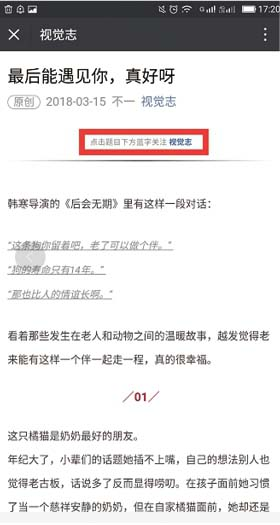

图9–2 “视觉志”引导用户关注的基本提示

**@特别语句引导用户关注** “正好有空”是一个每周向用户推送5节生活美学微课的公众号，在每一篇文章的开头，它都会添加一句特别的引导词：“一个为你的兴趣爱好操碎心的公众号。”和直接让用户点击关注不同的是，这句话并没有直接点明让用户关注，而是使用箭头的形式间接引导关注。这种特别的隐性引导词更容易引起用户的兴趣。

以上3种方法在实际应用中可以与图片甚至是动图相结合，更具设计感与个性化，用户体验会更好。

### 文末提示用户关注

二维码是文末常用的关注工具，可以通过一定的技巧引导用户长按二维码关注。值得注意的是，二维码要做到大小适中，保证合理美观。具体的形式分为以下4种。

**@二维码+一句必不可少的提示** 类似“长按指纹，一键关注”或“长按二维码识别关注”，提示总比不提示要好，很多账号却没有最基本的这句话。

**@二维码+用户痛点需求** 公众号“人物”的提示语是：“没看够？长按二维码关注‘人物’微信号，更多精彩故事在等着你。”“人物”在提示语中展示了自身的文章储备，与用户痛点相契合，起到了良好的引导作用。

**@一张图片，附二维码+一段话** 公众号“我走路带风”会在推文的结尾处放上一张较具诱惑力的个人图片，上面配上文字“1997年污妖王，没有故事的摩羯座，每晚九点半为你送上煲好的爱情毒鸡汤”。图片左下角附上二维码，加一句“扫描下方二维码即可关注，等你来撩”。用图文结合的方式，多元化展现公众号的特点，吸引用户注意力，激发用户关注动机。

**@二维码+一句有趣的文案** “果壳网”在二维码上添加了这样一句话：“果壳整天都在科普些啥啊！吓得我二维码都歪了！为啥这样的二维码也能扫？扫码发送‘二维码’告诉你原理～”

通过创意文案，“果壳网”不仅使文章锦上添花，也使用户获得了良好的阅读体验，是非常好的引导方法。

### 推荐阅读其他文章

一个新用户在朋友圈点击查看了公众号的一篇文章，可能关注动机还不足，如果他能了解到更多优质文章，关注公众号的概率就会提高。

推荐阅读其他文章的具体方式有3种。

**@文末推荐文章** 这是最简单的方法，在文章末尾提供其他文章的链接，可以有效缩短用户翻找的时间，提高效率。

“插坐学院”部分文章的文末有一个模块“推荐阅读”，一般会放上两三篇文章的题目+超链接。

**@利用关键词回复** 当用户想要回复关键词时，需要先关注公众号，所以引导用户回复关键词也十分重要。

一个科技人物类账号，可以在文末引导：回复人物名字如马云、马化腾等可查看文章。如果文章内容是关于买卖房产的，则在结尾提示回复“房子”查看更多文章。

**@阅读原文链接到历史消息上** 公众号文章内的“阅读原文”链接由运营者自行决定其跳转方向，所以我们可以将其链接到历史消息页面。当用户看完一篇文章，快速地进入历史消息页面，了解到公众号的内容类型后，关注公众号的概率就会提升。

一个时尚类公众号的“阅读原文”链接是历史消息页面，用户点击阅读原文后，会看到公众号内更多的时尚资讯与穿搭美妆推荐。

### 根据每篇文章内容，在文末编辑推荐语

根据不同文章内容随机应变，特殊处理编辑引导语。比如内容是关于如何做选题的文章，结尾就可以提示：“关于如何做爆款选题，我们策划了一个专题，今天是第一篇，后面还有4篇会陆续推送。”当用户对某一部分内容感兴趣时，文末引导起到了文章内容的延续作用，有效地刺激了用户进行关注。

### 文章内容中多次露出账号名称

这种方法简单易行，但很多人可能没想到过，或者懒得去做。

公众号“华商韬略”就经常这么做，它在每篇文章中都会多次提及自己的账号名称。比如它的文章中经常有这样的句子：某某某在接受华商韬略（微信公众号：hstl8888）采访的时候怎样怎样；华商韬略（微信公众号：hstl8888）之前发过一篇文章怎么怎么样。

在一篇文章中多次曝光账号，可以有效地提高公众号的知名度。当公众号的文章被用户转发到朋友圈，新用户点开看时，多次出现的账号会不断地刺激他的眼球，加深印象，新用户关注公众号的概率就会提高。

上面简单介绍了提高用户关注量的6种方法，创作者需要灵活地运用各种技巧。需要强调的是引导用户关注只是一个辅助性的工作，用户关注公众号的原因有很多，而本质上都是被内容所吸引。公众号的红利时代虽然已经过去，但是粉丝数量依旧是各个企业之间竞争的主要因素。作为企业公众号需要的不是泛流量而是精准流量，这就需要优质内容来支撑了。想要运用技巧引导用户关注，达到预期的效果，前提是有优质的内容作为保障。

## 如何让用户点赞转发

我们对点赞和转发并不陌生，在新媒体时代，点赞转发是用户与公众号最基本的互动，当一篇文章被用户点赞或转发，就表示这篇文章被用户认可。不难发现，颇具规模的公众号在引导用户互动方面做得十分成熟，而我们要做的，就是与它们一样，积极引导用户进行点赞和转发，让更多的人看到自身的闪光点。

在引导用户点赞转发之前，我们需要先了解引导用户点赞转发到底能为公众号带来怎样的价值。

### 彰显文章价值

一篇推文的价值是不会变的，但是很多用户衡量一篇推文的价值时，除了阅读的主观体验外，还会看点赞数量和转发量。用户看到高点赞高转发量的文章时，会有意识地认为文章具有高价值的内容；转发可以说是用户点赞行为的升级。通常我们对一篇文章认可程度的表现从低到高分别是：打开、阅读、点赞、分享，用户认可文章会进行点赞，而转发是在认同的基础上对文章的认可，用户想要通过转发让更多的人看到推文。

### 提升账号品牌价值

我们都知道微博上有热点排行榜，而公众号之间也存在排名先后。除了按照阅读量进行排名，点赞量和转发量也是重要的指标。

“新榜”中有一项“新榜指数”，“新榜指数”的算法主要取决于两个数据，一个是阅读量，另一个是互动指数，互动指数只看点赞总和，与评论区无关，可见点赞数的重要性。此外，“新榜”还有一个原创内容排行榜，但“新榜”能看到的最大阅读量是10万，之后的具体数据只面向运营者。所以，当很多文章的阅读量都是10万以上时，排名就完全取决于点赞数。

### 提高用户活跃度

点赞、转发也是用户与公众号互动的方式之一，提高用户活跃度不单单是指提高用户点赞、转发的活跃度，还包括推文下方的评论区。点赞、转发率越高，用户活跃度就越高，用户的参与感也就越高。所以当公众号要做广告投放时，点赞数也是广告主评判账号的重要指标。

既然提高点赞数大有裨益，那么公众号应该如何引导用户点赞呢？主要有5种技巧：

**@一个精彩的结尾，戳中用户心灵** 如果我们平时留心朋友圈会发现，点赞数高的文章通常结尾幽默诙谐，或者是有几句话正中下怀使人产生共鸣。这也启示我们写文章时不要草率结尾，否则前文再好，最后也会功亏一篑。在结尾写一些能引发用户共鸣的句子，可以有效地让用户完成最后的情感触发，从而使其发自内心地点赞。

**@用一句话、一张图引导点赞** 通常一篇文章的点赞处在最下方，再向下就是评论区，这样的排版可能使正文内容距离点赞处过远，那么引导点赞的结尾就无法产生最好的效果。所以，我们可以运用图片+文案的方式，在紧邻点赞处的上方引导用户点赞。图片的直观性可以吸引用户目光，有趣的文案可以突出目的性，使用户点赞动机极大提升。

“果壳网”经常运用图文结合的引导点赞方式，通常是一张有趣可爱的动图，图片下方是一行醒目的文案，这样的引导点赞轻松自然，更容易被用户接受，是简单有效的引导方式。比如在果壳网的引导点赞中有一张动图是一只乖萌的小猫咪，底下配上文案“赞过再走哦”；还有一张动图是只捂嘴惊讶状的小猫，配的文字是“我这么可爱你都不赞？（如图9–3所示）”

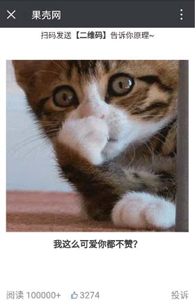

图9–3 “果壳网”的引导点赞

**@打感情牌求赞** 打感情牌并不是要求公众号刻意煽情，而是用情感共鸣的方式触发用户的点赞动机。感情牌的情感导向有很多，可以忧郁哀伤，也可以明媚愉悦，但目的只有一个，那就是引导用户点赞。

我们经常能在某些公众号文章的末尾处看见这样的句子：“看在我这么辛苦的分上，点个赞呗”，“老板说了，点赞过千就发红包，拜托大家给我点个赞吧。”类似的引导语还有很多，都属于打感情牌求赞。对于用户来说，公众号偶尔与自己套套近乎或者撒撒娇是种新奇的体验，点赞既不需要成本，又可以回应作者，一举两得。所以适当打打感情牌也是良好的引导方式。

**@做好人格化** 相比一个没有生命的文章或账号，用户往往更愿意给一个有感情有温度的人点赞。所以像“混沌大学”“笔记侠”这类账号，虽然内容质量都比较高，但点赞、互动比较少，就是因为这类账号机构感过强，人格化过弱。

用户使用公众号也是一种沟通交流的过程。公众号面向广大人群，属于一对多的形式，但从用户角度出发，用户与公众号是一对一的形式。所以在建设公众号时，运营者要设身处地，做好人格化。

**@评论区引导大家点赞** 通常评论区在点赞处的下方，两者距离很近，所以在评论区引导点赞也是一种有效的方式。这需要运营者时刻关注文章动向，在文章发表后，结合评论引导点赞。

“十点读书”通常会选择一条相对好的留言，回复的时候顺便引导大家给文章点赞，并且把这条留言置顶。比如在推文《你的爸妈，并不欠你一句“对不起”》后的置顶留言下回复了“喜欢这篇文章，快来给十点君一个赞，就是上方阅读原文旁边的大拇指哦。爱你们，晚安”（如图9–4所示）。

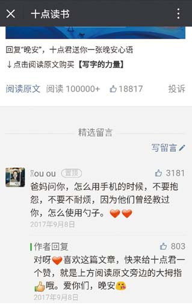

图9–4 “十点读书”的引导点赞

“十点读书”头条文章点赞数基本都在1.5万以上，有的甚至超过3万，除了内容本身足够好，长期对用户的引导也是其中一个原因。

说完点赞，再让我们看看如何提高用户的转发率。一篇爆款文章之所以火爆，是因为这篇文章被大量分享刷屏从而占据了朋友圈。所以，公众号只有点赞引导是不够的，还要做到转发引导。上文提到，用户如果高度认可文章的价值，就会选择转发，让更多的人看到。想知道如何引导用户转发，首先要清楚用户转发一篇文章的动机是什么，或者他的心理诉求是什么，解决了用户的问题，这篇文章就有价值了。

通常用户有表达观点、利他心理、站队心理、寻找谈资、塑造形象5大转发动机：

**@表达观点** 每个人都有表达的欲望，然而对于大部分人来说，“表达欲”和“表达”之间隔着一个“表达能力”，具有良好表达能力的人并不多。有时用户转发一篇文章，并不是因为喜欢这个公众号，而是这篇文章恰好说出了他想说的话、表达出了他想表达的观点，所以他其实是借助你的文章在朋友圈完成“自我表达”的诉求。

**@利他心理** 回想一下，我们是否常常会在父母的朋友圈中看到这样标题的文章：《早晨吃鸡蛋的惊人好处，你知道吗？》《郁闷的时候看看这头驴，改变你的心态！》《这5种食物千万不能吃！》，究其原因，是他们觉得这些文章颇有用处，应该让更多的人看到。这其实就是利他心理，几乎人人都有利他心理。

一位用户看完一篇文章后，如果觉得这篇文章对自己同学、同事、朋友、家人等有帮助的话，用户分享的欲望会更高一些。很多养生、鸡汤、励志、科普、干货文章都可以应用利他心理。

**@站队心理** 很多时候，用户转发一篇文章就是在为自己信任的东西投票，这其实是一种站队行为，它比单纯的表达观点更加深入。运营者在操作一篇文章的时候，也可以刻意利用用户这一心理，通过强化一个话题的两个对立观点，激发用户的站队心理。

**@寻找谈资** 用户转发文章到朋友圈，有时也是一种社交需求，一个有趣的话题可以引发大家的点赞、评论、聊天、讨论。

公众号“大象公会”的内容定位就是给70后提供饭桌谈资，《怕上火，难道你就不怕肾衰竭？》《如何起个与时俱进的英文名》《中国男人喜欢什么样的狐狸精》这些都是其爆款文章，这些文章不仅充分满足了用户的好奇心，而且具有话题点，适合制造谈资，用户的转发率就会提高。

**@塑造形象** 朋友圈是一个不完全真实的地方，它具有美化效果。每个人都渴望在朋友圈里塑造出更好的自己，无论是物质上，还是精神上。其实大部分时候，转发一篇文章，也是这样道理。通过转发分享，来展示“我是一个怎样的人”。

因此，运营者在写一篇文章时，要考虑到这篇文章能否帮助你的目标用户更好地塑造自我形象，如果可以，用户可能就会转发，如果不能，用户可能只是一看而过。

以上就是用户转发一篇文章的5大动机。运营者在选题、取标题、写文章时，都可以合理运用5大动机进行操作，以此引导用户转发。

俗话说“酒香不怕巷子深”，引导点赞转发就像深巷的引路人，而文章质量就是酒本身，作为运营者需要时刻谨记把“酒”酿好，才会有“酒香”，用户才愿意通过“引路人”到深巷“喝酒”。公众号最重要的功能是能够给用户提供帮助，如果用户受益匪浅，那么即使没有引导点赞转发，数据也会体现出文章的价值；如果用户毫无收获，即使引导点赞转发再精彩，数据也不会为质量买单。引导是一种辅助，内容质量高才是本质，所以做好本质，善用辅助才是文章能够大放异彩的核心。

## 评论区：让彼此的距离更近

继“点赞”和“阅读数”之后，微信公众号新增“评论”功能。在评论功能还没有出现之前，用户如果想要就一篇文章发表自己的想法，就只能进行转发，然后附带一些自己的观点。但随着评论功能的出现，用户不仅可以自己撰写评论，还可以看到他人的评论，有效增强了公众号与用户之间的互动性。

评论区作为文章的一部分，是公众号为用户提供的交互平台，用户不仅可以在文章中寻找共鸣，更可以在评论中找到志同道合的人。所以，打造出一个活跃的评论区，是公众号与用户的双赢。其价值主要体现在以下几个方面。

### 加强与用户的互动

传统媒体和新媒体的一大区别是互动性不同。传统媒体是单向传播，作者无法得到有效的反馈。新媒体恰恰相反，它是双向传播，公众号文章发出后可以即时接收到用户的反馈，运营者可以通过评论区和用户进行互动。

### 鼓励用户创造内容

公众号用户群体里难免卧虎藏龙，大量的相关从业者，甚至是这个领域的专家、学者、意见领袖，如果妥善运营，完全有可能做到“评论区比文章还好看”。这一点微博就是一个很好的例证，比如韩寒的微博，评论区金句比比皆是。评论区的内容也是整个内容产品的重要组成部分，比如“新世相”的每一篇文章，评论区留言都很多，从评论区的点赞来看，很多用户也会留意评论区的内容。

### 提高用户参与感，增加用户黏性

如果评论区显示密密麻麻几十条评论，用户看到后会潜意识代入活跃热闹的感觉。而作者与用户打成一片，使用户获得参与感，久而久之，用户的黏性、忠诚度都会非常好。

### 提高品牌价值

评论区的繁荣是增加品牌感的良策。尤其涉及广告变现时，评论区的留言数量和留言被点赞，一定程度上排除了刷量嫌疑，可以极大提高账号数据的可信度。

以上4点就是运营评论区的重要性，那究竟怎样才能打造一个活跃的评论区呢？当运营者具体操作时，可以参考以下5点。

### 及时精选评论

很多运营者都无法做到这点。当一篇文章推送出来后，阅读量已经好几千甚至过万，可评论区一个留言都没有，并非无人评论，而是运营者还没有放出评论，这是运营评论区的一大忌讳。正确的做法是，文章推送后，紧盯评论区，有好的评论立刻放出。最初的留言尤其重要，因为已有的留言会激发其他用户的留言动机。如果用户发现评论区空空如也，可能他也不会选择留言。

### 及时回复评论

评论区奉行及时原则，及时回复用户的留言，是用户非常重要的一个满足感来源。很多用户会以被喜欢的大号回复为荣。需要注意的是，甄选评论时可以着重考虑有争议性的留言，这也是激发其他用户评论的好方法。

### 回复评论要人格化

运营者不需要像严肃的学术会议那样一本正经，可以根据人格化设定回复留言，让评论区更加精彩。

“槽边往事”的评论区一大特色就是，用户与作者互相吐槽，令人捧腹（如图9–5所示）。这样的评论区让文章锦上添花，使用户在浏览内容时有了更多看点。

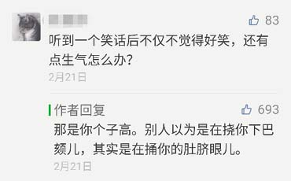

图9–5 “槽边往事”评论区

### 文末设置互动话题

事实证明，提供明确的话题让大家讨论，用户留言的积极性会更高。

“新世相”每篇文章文末都通过一个固定的板块“晚祷时刻”，根据当天文章的主题为用户提供一个讨论的话题（如图9–6所示）。这种互动话题一可以为用户提供留言思路，二可以激发用户的留言动机，三可以深入主题提升文章价值，用户参与感也会提升。

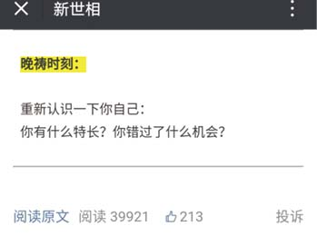

图9–6 “新世相”的“晚祷时刻”

除此之外，主动提示用户评论也十分重要。像街上的小贩，吆喝的肯定比不吆喝的人气高一点，运营评论区也是如此。

### 初期运营进行专人评论

如果评论区一直处于不太活跃的状态，那么在运营初期可以加强干预。比如组织公司内部的人留言，或者组织一批忠诚用户集中到一个群里，每次文章推出后，第一时间在群里通知，鼓励大家讨论、评论。人为创造一个活跃的氛围，调动用户的积极性，评论区会慢慢地热闹起来。

这就是运营评论区的技巧，合理运营评论区可以让文章增添许多亮点。在精选评论时，我们可以利用留言置顶功能，让我们想表达的东西处在一个醒目的位置。

目前开通了原创功能的公众号都可以置顶精选留言，并且一篇文章可以置顶5条留言，按时间排序，后置顶的在前，先置顶的在后。所以留言置顶也是一把运营评论区的利器。留言置顶功能有5个很好的用处，一是更正错误，补充内容；二是引导用户点赞、留言、分享，提前写好引导语，在推文后进行留言置顶；三是作者留言与用户进行人格化互动；四是主动干预评论排序，利用置顶功能使优质评论展示在前排；五是作为广告位资源进行商业活动。

留言置顶功能十分灵活，可以帮助运营者有效运营评论区。但要注意评论区的点赞排序机制是为了激发用户留言的积极性，如果利用置顶功能，过度操纵评论区的前五条留言，会打击很多用户的积极性，反而降低了用户活跃度。

运营评论区，其实也是在运营文章的一部分，运营者在精心准备内容的同时也应在评论区投入同样的心力。俗话说“好事做到底”，对待一份作品，我们也应从头到尾都尽善尽美。但要明确一点，评论区属于用户，我们可以使用和干预，但要相对克制。距离产生美，拉近运营者与用户间的距离时，也要给彼此留有足够的空间。

## 没有内容推送时怎么办

通常微信公众号都追求每日更新，并且是原创，因此对于推送者来说，压力非常大，经常会遇到弹尽粮绝的窘境，没内容可推送。比如当天绞尽脑汁也找不到好的选题；当天没状态写不出东西；当天有其他事情来不及写；遇到周末、五一、十一、春节等各种节假日不想做原创更新等。这些时候怎么办呢？

### 尽量不要停更

实际上，你没有那么多推送机会，一天一次，一周七次。假如你某一天停更了，就白白浪费了一次推送机会，也就浪费了一次与用户互动的机会。比如你每天头条推送都有一万用户，一天不推送，其实就相当于白白扔掉了一万个阅读量。因此，你如果是平时每日更新，就尽量不要停更。

### 不要毫无征兆地停更

所谓毫无征兆，其实就是突然不更新了，对用户没有一个明确的交代。这样会对用户造成不好的影响。如果你真的要停更，请提前跟用户说明情况。比如你十一黄金周不想更新了，你最好在停更的前一天，具体说明接下来几天将要停更，请大家假期结束的时候，继续关注你。

因为有一部分用户可能一直在关注你，是你的忠实用户，他们几乎每天都来看你。其实“我每天都会给你推送文章”就是一种非正式的承诺，那么你突然就不更新了，用户找不到你，也不知道你为什么今天不更新，某种程度上，这属于你失信于用户，这会给微信公众号运营造成许多负面影响。

那么，为了避免停更，在没有内容时可发送什么呢？

### 依旧发文章，但换一种思路

（1）找转载。即使你的公众号以原创为主，但在没有原创的情况下，转载也是可以的，转载的文章一定要保证符合你的用户定位、内容定位、提供用户价值、符合你的账号格调。当然也有例外，如果账号是像“咪蒙”“夜听”那种人格化、个性化非常强的账号，就不建议转载了。

（2）发旧文。日更的账号经过长时间的积累，会沉淀下很多优质文章，这些文章的价值不会随着时间的推移而降低，比如人物类、故事类、观点类、科普类文章，一般都是长期不会过时的，隔一段时间重新发送，用户也会乐意接受。不过这个需要你提前准备，你可以把你们账号发过的高质量文章全都整理出来，你在没有新内容的时候就可以从中选择推送。

（3）发专题整合。比如你在五一、十一、春节等节假日，不想每天推送新内容，但假期又相对较长，你可以提前做一些专题整合，让用户这几天就看这些专题里的内容。

“插坐学院”在2017年国庆期间发了一个专题整合，题目是《喜迎国庆，送你50篇必读好文章》，让用户在享受假期的同时也潜移默化地接受了文章带给心灵的慰藉。

### 不发文章，和用户互动

（1）征集内容。抛出一个话题，征集用户的观点、故事等，让用户参与互动。最后从用户的互动中筛选一些优质回答，整理出来。

微信公众号“晚安少年”每天都会在最后一个栏目推送一个大家感兴趣的话题，让用户参与进来，最后“晚安少年”会在互动里选一些好的内容，整理成文章（如图9–7所示）。

[figure not shown]

图9–7 “晚安少年”的互动方式

（2）单纯聊天。相对而言，聊天就灵活很多。你想说什么就说什么，偶尔来一个这种非常轻松的方式，也会受到用户的欢迎，也是跟用户建立良好关系、打造融洽氛围的好方法。比如简单说几句你今天做了什么，看了什么电影，读了什么书，见了什么人，有什么思考，有什么开心或者不开心的事等。

（3）问候祝福。假如你不想征集内容也不想聊天，也不要停更，你只简单发一句问候和祝福语也会慰藉用户的心灵。你可以写：“今天天气很好，祝你有一个愉快的假期，我们假期结束再见。”这样会让用户觉得你重视他，简单一句话，用户看到后心里会很温暖。

### 不发文章，跟用户请假

**@说明请假理由** 简单说一下你为什么不更新了，一般用户都会理解，甚至觉得你是一个有血有肉的人，责任感特别强，不更新还记得跟大家说一声，大家会更爱你。比如你可以说：“今天感冒了，暂停更新一天，明天见”，或者“今天生日，不写文章了，给自己放假一天，祝福我吧。”

**@直接撒娇请假** 你偶尔的任性，展现了你的另一面，对于用户来说也是一个小惊喜，用户会认为你是一个有趣、可爱的人。比如你可以说：“今天没状态，我要休假……”“天天写文章，也没有女朋友，今天不更了。”

总之，在实在没有内容可发的时候，你可以选择换种思路发文章，和用户互动，跟用户请假等。当然推送形式并不是单一的，这里有5种形式，可供大家选择。

（1）直接推送一段文字。把你要说的话直接以文字形式推送出来，既简单明了又方便操作。

（2）直接推送一段语音。用更人格化的方式拉近与用户的距离。比如冯唐经常直接用语音跟用户说话、读诗。

（3）直接推送一首歌。分享一首动听的音乐，既陶冶了情操，又让用户看到了你的品位，但要根据你的用户定位来选。

（4）直接推送一张图片。找一张精美的图片，配上文字，简单发表一下自己独到的见解。

（5）直接推送表情包。这在跟用户请假时使用为宜，有时会有意想不到的效果呢。

## 引导用户生产爆款内容

所谓引导用户生产就是让微信公众号的粉丝用户提供推文内容，也就是运营过程中经常提到的用户原创内容。公众号在运营一段时间后，就会积累一定数量的粉丝，这时就可以发动用户的力量，来为公众号提供一些内容的推送。那么引导用户生产对公众号有什么好处呢？

### 减轻更文的压力

引导用户生产，最直接的作用就是减轻公众号运营者的更文压力。推文创作是一个有入有出的过程，运营者如果只是长期的信息输出，那么肚子里剩下的内容就不足以支撑创作者写出一个爆款文章。而引导用户生产，不但可以减轻压力，而且还有利于企业公众号创作者有更多的时间进行再次信息充饥，自我造血。

### 用户提供的内容更鲜活、生动、多样化

用户生产的内容和公众号创作的文章最大的不同点是，用户生产的内容更生动、更鲜活、更多样化。很多公众号会向用户征集一些推文，这样的内容才贴近用户生活、更接地气，同时还能增加用户的代入感，引起共鸣。

在“咪蒙”的文章中，我们可以发现里面大部分都是身边人的身边事儿，举的例子很接地气，内容鲜活生动，“咪蒙”之所以现在还保持着旺盛的生命力，主要原因就是它推送的内容大多是用户提供的。

### 提高用户的参与感、成就感

微信公众号就是一个庞大的社交群，每个用户都渴望参与，因此用户的参与感非常重要。如果让用户享受到参与的乐趣，他们甚至会产生一种成就感，用户的积极性也就被调动起来了。

了解完用户生产带来的好处后，接下来我们就需要知道，如何才能让用户参与到内容生产中？这一点上，公众号可以通过以下几种方式：

**@先定选题** 大家都知道写文章要先定选题，再去写。同样，你让用户进行内容生产，也要先给用户定选题。

“咪蒙”2017年11月15日在公众号上推送了一张图片，图片的内容是“咪蒙”给的用户做的选题，其中一个选题就是“辣妈逆袭”，简单讲述了一个成功逆袭为辣妈的故事，然后向用户征集成功的例子（如图9–8所示）。

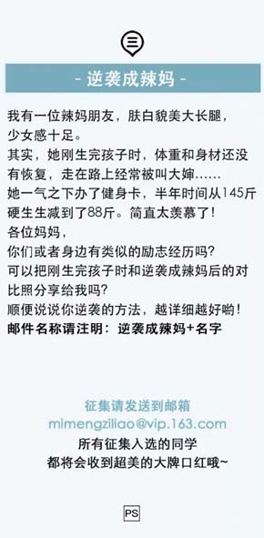

图9–8 “咪蒙”的选题

**@推送征集** 当你的选题和文案都确定之后，接下来你就要推送给用户，让用户参与。一般的形式主要有三种：

（1）做成海报，直接推送。“咪蒙”几乎每周周末两天都发两张海报，征集不同主题的用户故事。

（2）直接推送文案。“新世相”就喜欢采用直接推送文案的方式与用户互动（如图9–9所示）。

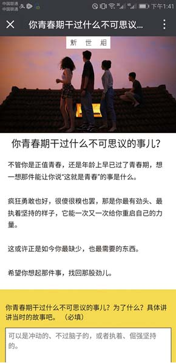

图9–9 “新世相”直接推送文案

（3）文末征集。“我走路带风”每天推送的第二篇文章就是UGC内容，然后在文末放上新的话题。

推送征集时除了选题和文案之外，最重要的是让用户参与其中，因此参与方式是尤为重要的。

推送征集的时候，最重要的3个组成部分就是：选题、文案、参与方式。有了这3个，才算是一个完整的征集。然后你可以根据自己的实际情况，灵活增加一些东西。很多微信公众号为了调动大家的积极性，通常还有奖励。

“咪蒙”在推送的征集中，写的是“所有征集入选的朋友，都会收到一支超美的大牌口红哦，请在邮件中附上你的微信吧，以便我们能及时联系你送你礼物”。

**@整理成文** 确定选题和推送征集之后你要从用户提供的大量内容中，挑出最好的一部分，然后整理成文章发布。

最后需要强调的是，征集用户故事绝不是随心所欲的，在引导用户生产的过程中，公众号运营者需要注意选择征集话题时，要考虑到话题覆盖的用户数量，要带动大部分用户参与而不是一小部分用户，同时，推送征集信息时一定要将收稿地址、截稿时间、奖励制度等内容交代清楚，只有让用户清楚规则用户才会参与其中。

此外，还要尽量形成固定的栏目，定期发布相关内容征集，不要半途而废，要让用户养成习惯，这个非常重要。比如我上面提到的，“我走路带风”每天推送的第二篇文章都是内容征集，“咪蒙”则是每周周末发表相应征集。长此以往，用户就会将参与内容生产变成一种习惯，公众号就不用担心没有内容推送了。

## 白名单群运营

微信公众平台为保护原创文章，为平台运营者提供了申请原创版权的保护，如果文章申请了原创版权，在进行发布时该文章会出现原创标记，若是被其他公众平台转载，那在该公众平台文章的底部就会出现“内容转载自某某公众号”。

这种形式确实保护了运营者的原创权益，但是也阻碍了文章的传播和企业的推广。微信公众平台为改进这一缺点，使原创公众号的文章得以传播，新增了授权转载功能。在原创文章的管理中，可以添加白名单账号，白名单与黑名单相反，是给予这些账号修改文章或是不显示转载源的权限。那白名单账号究竟要如何进行设置呢？

第一步，登录微信公众平台账号，然后在功能栏找到“原创管理”选项，并点击。在原创管理界面，可以看到已申请原创保护的文章。

第二步，在需要添加白名单的文章后边点击“转载设置”选项，进入该文章的白名单管理界面。

第三步，点击“添加”，在弹出的界面中，搜索需要设置白名单的公众号账号或是微信，单击下一步。

第四步，设置公众号的转载权限，点击确认。

转载权限有两种，一种是可修改文章，即被授权对文章内容、排版及格式的修改，另一种是可不显示转载来源，即转发的原创文章不会被标明来源，具体选择哪种授权方式，要根据公众号内容来决定，还需注意的是，这种授权方式只针对授权的文章，并不能将所有文章同时授权给白名单账号，如果其他原创文章也需要授权，只能另外进行设置。

如果在后续的运营中，需要对白名单账号进行整理，删除一部分白名单账号，可以在白名单账号中将其移出。

上面对公众号白名单的作用和设置方法进行了相关介绍，但是，如果企业想把白名单公众号或个人集中起来进行管理，就需要建立一个白名单群，该如何建立和运营白名单群呢？具体可以从以下几方面入手。

### 建群拉人

首先群名要简单规范，这样方便其他潜在的文章转载账号搜索到，例如“××学院白名单群”，搜索起来方便快捷。拉人则是为了扩大自身影响力，只需要将最初的文章转载者和有针对性的目标群体拉进来。这时白名单群里的人数量是有限的，怎样扩大群成员呢？我们可以采取以下方法。

通过现有成员推荐给他所熟悉的、从事相同风格写作或转载文章的新媒体账号；在原创文章的底部推广自己的白名单群、微信号等；在微信公众号的后台菜单栏做一个转载须知，须知内容里标注如何进白名单群等字样。这样可以将微信白名单群最大限度地推广出去，更多潜在的文章转载账号可以通过各种途径找到你的微信白名单群。

### 制作关于文章转载版权信息的模板

模板内容以扩大影响力为宗旨，给自己的账号吸引新用户和规范转载。制作转载模板是为了加深普通用户对原创文章及公众号的印象，促使其搜索原创公众号。

“插坐学院”的转载模板：“本文转载自公众号插坐学院，作者某某，插坐学院，职场充电第一站，专注于实用且有超级性价比的职业课程，每晚推送耐人寻味、受益终生的好文章。转载请与插坐学院联系。”另外，“插坐学院”还设置了一个样式统一的二维码，并规定版权信息应当出现在转载文章的开头或结尾。

### 制作一个申请白名单授权的话术模板

制作模板方便与转载账号的沟通，提高沟通交流的效率，能够及时高效地处理白名单授权及转载目标文章的事宜。

例如：运营者，您好！申请转载十二月十日文章+“文章题目”+转载账号+授权方式（单或双），谢谢！

### 原创文章推送后主动发在群里并@所有人

这样做是为了方便目标转载群体能够在第一时间关注到推送的文章，也提高了自身的工作效率。

### 为发布的原创文章写一段推荐语鼓励大家转载

一句鼓励的话语，可以调动起大家的积极性，让更多的人参与进来，有时会起到事半功倍的效果。例如“最新原创文章出炉，欢迎转载”，旨在宣传自身的微信公众号。

建立白名单群，主要就是为给自己的账户吸引更多的新用户，加深用户对原创文章和公众号的印象，从而扩大公众号的影响力，所以在运营群的时候一定要根据群的定位，围绕公众号原创文章的推广进行。